# Adjunctive Vasopressor Selection Decision Model

### 12.3.6 Model Selection

Among the models assessed, the boosted trees (XGBoost) machine learning model for epinephrine response demonstrated the best discrimination, overall performance, and calibration. It also had a higher net benefit in decision curve analysis than the logistic regression model. In light of these findings, the XBGoost model (`epi_m4_boost_xgboost`) was selected as the final model for epinephrine.

#### 12.3.6.1 Refit to Whole Derivation Dataset

Refit the final model (`epi_m4_boost_xgboost`) in the whole epinephrine derivation dataset (`epi`).

```r
set.seed(2026)
epi_mod_final_wf <-
  epi_m4_xgb_final_fit[[1]]$final_workflow

epi_mod_final_fit_dev <-
  fit(epi_mod_final_wf, data = epi)
```

Estimate apparent performance on derivation data.

```r
# Generate predictions
epi_dev_preds <-
  predict(
    epi_mod_final_fit_dev,
    new_data = epi,
    type = "prob"
    ) |>
  bind_cols(
    epi |> select(response)
    )

epi_dev_score_data <-
  epi_dev_preds |>
  transmute(
    response_num = if_else(response == "Response", 1, 0),
    p_xgb = .pred_Response
  )

# Generate metrics
epi_dev_score <-
  Score(
    object = list(
      "XGBoost" = epi_dev_score_data$p_xgb
    ),
    formula = response_num ~ 1,
    data = epi_dev_score_data,
    metrics = c("auc", "brier")
  )

# Extract and format results
auc_ci <-
  epi_dev_score$AUC$score |>
  as_tibble() |>
  transmute(
    auc = as.numeric(AUC),
    auc_lower = as.numeric(lower),
    auc_upper = as.numeric(upper)
  )

brier_ci <-
  epi_dev_score$Brier$score |>
  as_tibble() |>
  filter(model == "XGBoost") |>
  transmute(
    brier = as.numeric(Brier),
    brier_lower = as.numeric(lower),
    brier_upper = as.numeric(upper)
  )

epi_dev_mets <- cbind(auc_ci, brier_ci) |>
  mutate(
    AUROC = sprintf("%.3f (%.3f, %.3f)", auc, auc_lower, auc_upper),
    Brier = sprintf("%.3f (%.3f, %.3f)", brier, brier_lower, brier_upper)
  ) |>
  select(AUROC, Brier)
rm(auc_ci, brier_ci)

epi_dev_mets |>
  gt() |>
  tab_header(title = "Epinephrine XGBoost Model Fit and Apparent Performance Parameters",
             subtitle = "In Derivation (Ohio) Dataset") |>
  cols_align(align = "center")
```

Epinephrine XGBoost Model Fit and Apparent Performance Parameters

In Derivation (Ohio) Dataset

| AUROC | Brier |
| --- | --- |
| 0.734 (0.695, 0.772) | 0.181 (0.168, 0.194) |

Notably, the apparent performance metrics for the epinephrine XGBoost model are very optimistic and substantially better than the cross-validated values (AUROC apparent 0.73 vs. CV 0.62, Brier apparent 0.18 vs. CV 0.20).

#### 12.3.6.2 Compare to Simple Model

Compare the selected multivariable model (`epi_m4_boost_xgboost`) with a simple logistic regression model that only includes `neq` with a spline term.

```r
epi_m0_lr_rec_ns <-
  recipe(response ~ neq, data = epi) |>
  step_spline_natural(neq, deg_free = 5)

epi_m0_lr_preproc <- list(epi_m0_neq_only = epi_m0_lr_rec_ns)

epi_m0_lr_model <-
  workflow_set(epi_m0_lr_preproc,
               list(logistic = logistic_reg(engine = "glm")),
               cross = FALSE
               )

set.seed(2026)
train_cv <- vfold_cv(epi, v = 10, repeats = 5, strata = response)
class_metrics <- metric_set(roc_auc, brier_class)
keep_pred <- control_resamples(save_pred = TRUE, save_workflow = FALSE)

epi_m0_lr_model_fit <-
  epi_m0_lr_model |>
  workflow_map("fit_resamples", seed = 2026, verbose = TRUE,
               resamples = train_cv, metrics = class_metrics,
               control = keep_pred
               )
```

```
i 1 of 1 resampling: epi_m0_neq_only_logistic
```

```
✔ 1 of 1 resampling: epi_m0_neq_only_logistic (12.5s)
```

```r
epi_m0_lr_preds <-
  collect_predictions(epi_m0_lr_model_fit, summarize = FALSE)

epi_m0_lr_mets <-
  collect_metrics(epi_m0_lr_model_fit) |>
  # Compute 95% Wald CIs across the 50 resamples
  mutate(
    conf.low.95 = mean - qt(0.975, df = 10*5-1) * std_err,
    conf.high.95 = mean + qt(0.975, df = 10*5-1) * std_err,
    mean_ci = sprintf("%.3f (%.3f, %.3f)", mean, conf.low.95, conf.high.95)
  ) |>
  select(wflow_id, .metric, mean, conf.low.95, conf.high.95, mean_ci) |>
  pivot_wider(
    names_from = .metric,
    values_from = c(mean_ci, mean, conf.low.95, conf.high.95)
    )

bind_rows(epi_m0_lr_mets, epi_m4_xgb_mets) |>
  select(wflow_id, mean_ci_roc_auc, mean_ci_brier_class) |>
  gt() |>
  tab_header(
    title = "Epinephrine Final Model Performance vs. NE Alone",
    subtitle = "Using 10-fold Cross-Validation (5 repeats). Presented as mean (95% CI)."
    ) |>
  cols_label(
    wflow_id = "Model",
    mean_ci_roc_auc = "AUROC",
    mean_ci_brier_class = "Brier Score",
    ) |>
  cols_align(
    align = "left",
    columns = c(wflow_id)
    ) |>
  cols_align(
    align = "center",
    columns = c(mean_ci_roc_auc, mean_ci_brier_class)
    )
```

Epinephrine Final Model Performance vs. NE Alone

Using 10-fold Cross-Validation (5 repeats). Presented as mean (95% CI).

| Model | AUROC | Brier Score |
| --- | --- | --- |
| epi_m0_neq_only_logistic | 0.546 (0.527, 0.565) | 0.204 (0.202, 0.205) |
| epi_m4_boost_xgboost | 0.619 (0.605, 0.633) | 0.198 (0.196, 0.200) |

The multivariable model has better metrics than the simple model using `neq` alone. Using additional patient information beyond relying on norepinephrine dose alone provides meaningful improvement in the prediction of epinephrine response.

## 12.4 Phenylephrine

This section will build and evaluate prediction models for response after initiation of phenylephrine as the first adjunctive vasopressor. The same approaches as for vasopressin models will be used here with less annotation. For more annotation regarding the rationale for model building and evaluation steps see Section 12.2.

### 12.4.1 Logistic Regression

Here, use logistic regression to generate prediction models using two approaches: 1) main effects (additive) only, and 2) non-linear effects of predictors.

The two models will be built in one `workflow_set()`. First, generate a Spearman’s $\rho^2$ rank correlation plot to assess for potential predictor transformation (non-linear effects).

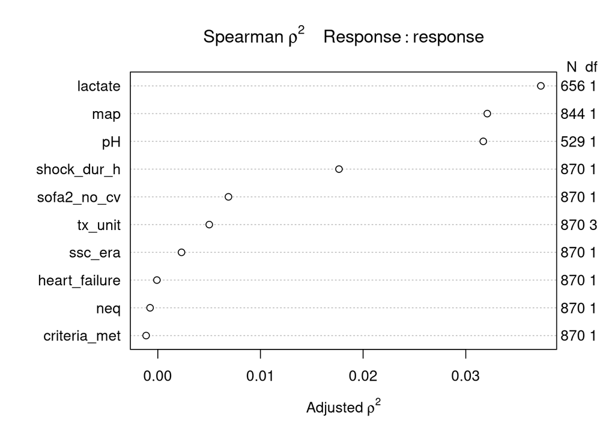

```r
plot(spearman2(response ~ ., data = pe |> select(-c(age, sex, race_eth))))
```

```r
invisible(pdf("pe_spearman.pdf"))
plot(spearman2(response ~ ., data = pe |> select(-c(age, sex, race_eth))),
     main = ""
     )
title(main = expression("Phenylephrine Spearman " * rho^2))
invisible(dev.off())
```

The Spearman’s $\rho^2$ rank correlation plot shows that `lactate`, `map`, and `pH` have the highest potential to improve model fit with a non-linear transformation. The $\rho^2$ values for these predictors is relatively close to each other. From a biological plausibility and outcome component perspective, non-linear terms for `lactate` and `pH` are most likely to provide value. Because these two predictors are quantitative variables, introduce a natural spline with 2 knots (3 df) for `lactate` and a natural spline with 1 knot (2 df) for `pH`. This will add 3 total df to the model and spend all of the available degrees of freedom (12 df in the main effects model and 15 total available).

As noted in Section 11.5, there are missing data in the same three variables as for vasopressin and epinephrine. Therefore, the same imputation approach will be used.

```r
# Main effects recipe
pe_m1_lr_rec_main <-
  recipe(response ~ ., data = pe) |>
  # Declare age, sex, and race_eth in a bystander role
  update_role(age, sex, race_eth, new_role = "bystander") |>
  # Single (linear regression) imputation for missing quantitatitve predictors
  step_impute_linear(
    map,
    impute_with = vars(heart_failure, tx_unit, ssc_era, criteria_met,
                       sofa2_no_cv, neq, shock_dur_h
                       )
                     ) |>
  step_impute_linear(
    lactate,
    impute_with = vars(heart_failure, tx_unit, ssc_era, criteria_met,
                       sofa2_no_cv, neq, shock_dur_h, map
                       )
    ) |>
  step_impute_linear(
    pH,
    impute_with = vars(heart_failure, tx_unit, ssc_era, criteria_met,
                       sofa2_no_cv, neq, shock_dur_h, map, lactate
                       )
    )

# Non-linear effects recipe
pe_m1_lr_rec_ns <-
  recipe(response ~ ., data = pe) |>
  update_role(age, sex, race_eth, new_role = "bystander") |>
  step_impute_linear(
    map,
    impute_with = vars(heart_failure, tx_unit, ssc_era, criteria_met,
                       sofa2_no_cv, neq, shock_dur_h,
                       )
                     ) |>
  step_impute_linear(
    lactate,
    impute_with = vars(heart_failure, tx_unit, ssc_era, criteria_met,
                       sofa2_no_cv, neq, shock_dur_h, map,
                       )
    ) |>
  step_impute_linear(
    pH,
    impute_with = vars(heart_failure, tx_unit, ssc_era, criteria_met,
                       sofa2_no_cv, neq, shock_dur_h, map, lactate,
                       )
    ) |>
  # Add natural spline with 2 knots (3 df) for lactate
  step_spline_natural(lactate, deg_free = 3) |>
  # Add natural spline with 1 knot (2 df) for pH
  step_spline_natural(pH, deg_free = 2)

# Set up pre-processing and model workflow_set()
pe_m1_lr_preproc <- list(
  pe_m1_main = pe_m1_lr_rec_main,
  pe_m1_ns = pe_m1_lr_rec_ns
  )

pe_m1_lr_models <-
  workflow_set(pe_m1_lr_preproc,
               list(logistic = logistic_reg(engine = "glm")),
               cross = FALSE)

# Resample each model in the set with 10-fold CV (5 repeats)
set.seed(2026)
train_cv <- vfold_cv(pe, v = 10, repeats = 5, strata = response)
class_metrics <- metric_set(roc_auc, brier_class)
keep_pred <- control_resamples(save_pred = TRUE, save_workflow = FALSE)

pe_m1_lr_models_fit <-
  pe_m1_lr_models |>
  workflow_map("fit_resamples", seed = 2026, verbose = TRUE,
               resamples = train_cv, metrics = class_metrics,
               control = keep_pred
               )
```

```
i 1 of 2 resampling: pe_m1_main_logistic
```

```
✔ 1 of 2 resampling: pe_m1_main_logistic (20.5s)
```

```
i 2 of 2 resampling: pe_m1_ns_logistic
```

```
✔ 2 of 2 resampling: pe_m1_ns_logistic (33.6s)
```

```r
# Collect predictions
pe_m1_lr_preds <-
  collect_predictions(pe_m1_lr_models_fit, summarize = FALSE)

# Collect then show the metrics
pe_m1_lr_mets <-
  collect_metrics(pe_m1_lr_models_fit) |>
  mutate(
    conf.low.95 = mean - qt(0.975, df = 10*5-1) * std_err,
    conf.high.95 = mean + qt(0.975, df = 10*5-1) * std_err,
    mean_ci = sprintf("%.3f (%.3f, %.3f)", mean, conf.low.95, conf.high.95)
  ) |>
  select(wflow_id, .metric, mean, conf.low.95, conf.high.95, mean_ci) |>
  pivot_wider(
    names_from = .metric,
    values_from = c(mean_ci, mean, conf.low.95, conf.high.95)
    )

pe_m1_lr_mets |>
  select(wflow_id, mean_ci_roc_auc, mean_ci_brier_class) |>
  gt() |>
  tab_header(
    title = "Phenylephrine m1 (Logistic Regression) Metric Comparison",
    subtitle = "Using 10-fold Cross-Validation (5 repeats). Presented as mean (95% CI)."
    ) |>
  cols_label(
    wflow_id = "Model",
    mean_ci_roc_auc = "AUROC",
    mean_ci_brier_class = "Brier Score",
    ) |>
  cols_align(
    align = "left",
    columns = c(wflow_id)
    ) |>
  cols_align(
    align = "center",
    columns = c(mean_ci_roc_auc, mean_ci_brier_class)
    )
```

Phenylephrine m1 (Logistic Regression) Metric Comparison

Using 10-fold Cross-Validation (5 repeats). Presented as mean (95% CI).

| Model | AUROC | Brier Score |
| --- | --- | --- |
| pe_m1_main_logistic | 0.650 (0.634, 0.666) | 0.221 (0.217, 0.224) |
| pe_m1_ns_logistic | 0.647 (0.631, 0.664) | 0.222 (0.218, 0.226) |

The two logistic regression modeling approaches had essentially the same discrimination (AUROC) and overall performance (Brier score).

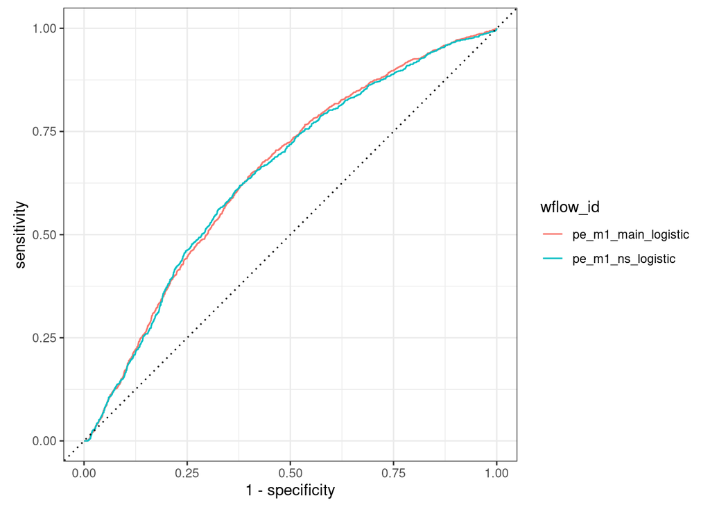

```r
pe_m1_lr_preds |>
  group_by(wflow_id) |>
  roc_curve(response, .pred_Response) |>
  autoplot()
```

The two curves are essentially overlapping.

### 12.4.2 Machine Learning

#### 12.4.2.1 Regularized (Elastic Net)

Fit regularized (elastic net) models.

```r
pe_m2_rec_main <- pe_m1_lr_rec_main |>
  step_dummy(all_nominal_predictors()) |>
  step_normalize(all_numeric_predictors())

pe_m2_rec_ns <- pe_m1_lr_rec_ns |>
  step_dummy(all_nominal_predictors()) |>
  step_normalize(all_numeric_predictors())

pe_m2_glmnet_preproc <- list(
  pe_m2_main = pe_m2_rec_main,
  pe_m2_ns = pe_m2_rec_ns
  )

pe_m2_glmnet_models <-
  workflow_set(pe_m2_glmnet_preproc,
               list(glmnet = logistic_reg(
                 engine = "glmnet",
                 mode = "classification",
                 penalty = tune(),     # lambda
                 mixture = tune()      # alpha
                 )),
               cross = TRUE
               )

set.seed(2026)
train_cv <- vfold_cv(pe, v = 10, repeats = 5, strata = response)
class_metrics <- metric_set(roc_auc, brier_class)
keep_pred <- control_resamples(save_pred = TRUE, save_workflow = FALSE)

pen_grid <- grid_space_filling(
  penalty(range = c(-5, 0)), # log10 scale, reasonable range for elastic net
  mixture(range = c(0, 1)),  # default
  size = 30
  )

pe_m2_glmnet_models_fit <-
  pe_m2_glmnet_models |>
  workflow_map("tune_grid", seed = 2026, verbose = TRUE,
               resamples = train_cv, grid = pen_grid,
               metrics = class_metrics, control = keep_pred
               )
```

```
i 1 of 2 tuning:     pe_m2_main_glmnet
```

```
✔ 1 of 2 tuning:     pe_m2_main_glmnet (1m 45.9s)
```

```
i 2 of 2 tuning:     pe_m2_ns_glmnet
```

```
✔ 2 of 2 tuning:     pe_m2_ns_glmnet (2m 3.8s)
```

```r
workflow_ids <- pe_m2_glmnet_models_fit$wflow_id

# Loop over workflows to finalize, fit, and collect results
pe_m2_glmnet_final_fit <- map(workflow_ids, function(wf_id) {

  # Extract tuning results for this workflow
  wf_result <- extract_workflow_set_result(pe_m2_glmnet_models_fit, id = wf_id)

  # Get best parameters by AUROC
  best_params <- select_best(wf_result, metric = "roc_auc")

  # Extract the workflow object itself
  wf <- extract_workflow(pe_m2_glmnet_models_fit, id = wf_id)

  # Finalize the workflow with best hyperparameters
  final_wf <- finalize_workflow(
    wf,
    best_params
  )

  # Fit the final workflow to the training set
  final_fit <- fit(final_wf, data = pe)

  # Collect resampling metrics for this workflow from tuning
  cv_metrics <- collect_metrics(wf_result) |>
    filter(penalty == best_params$penalty,
           mixture == best_params$mixture)

  # Collect predictions for the best parameters
  cv_preds <- collect_predictions(wf_result, summarize = TRUE) |>
    filter(penalty == best_params$penalty,
           mixture == best_params$mixture)

  # Return as a list
  list(
    workflow_id = wf_id,
    best_params = best_params,
    final_workflow = final_wf,
    final_fit = final_fit,
    cv_metrics = cv_metrics,
    cv_predictions = cv_preds
  )
})

# Name the list elements by workflow
names(pe_m2_glmnet_final_fit) <- workflow_ids
rm(workflow_ids)
```

Show elastic net hyperparameters resulting in the best fit.

```r
imap_dfr(pe_m2_glmnet_final_fit,
         ~ .x$best_params |> mutate(wflow_id = .y)
         ) |>
  select(wflow_id, penalty, mixture) |>
  gt() |>
  tab_header(
    title = "Phenylephrine m2 Elastic Net Best Hyperparameters",
    subtitle = "Using 10-fold Cross-Validation (5 repeats)"
    ) |>
  cols_label(
    wflow_id = "Model",
    penalty = "Penalty (lambda [λ])",
    mixture = "Mixture (alpha [α])"
    ) |>
  fmt_number(decimals = 4) |>
  cols_align(
    align = "left",
    columns = c(wflow_id)
    ) |>
  cols_align(
    align = "center",
    columns = c(penalty, mixture)
    )
```

Phenylephrine m2 Elastic Net Best Hyperparameters

Using 10-fold Cross-Validation (5 repeats)

| Model | Penalty (lambda [λ]) | Mixture (alpha [α]) |
| --- | --- | --- |
| pe_m2_main_glmnet | 0.0924 | 0.3103 |
| pe_m2_ns_glmnet | 0.0057 | 0.0000 |

Collect metrics and display table (comparing to the logistic regression model fits).

```r
pe_m2_glmnet_mets <-
 pe_m2_glmnet_final_fit |> map(function(x) {
    x$cv_metrics |>
    mutate(wflow_id = x$workflow_id)
  }) |>
  list_rbind() |>
  mutate(
    conf.low.95 = mean - qt(0.975, df = 10*5-1) * std_err,
    conf.high.95 = mean + qt(0.975, df = 10*5-1) * std_err,
    mean_ci = sprintf("%.3f (%.3f, %.3f)", mean, conf.low.95, conf.high.95)
  ) |>
  select(wflow_id, .metric, mean, conf.low.95, conf.high.95, mean_ci) |>
  pivot_wider(
    names_from = .metric,
    values_from = c(mean_ci, mean, conf.low.95, conf.high.95)
    )

bind_rows(pe_m1_lr_mets, pe_m2_glmnet_mets)  |>
  select(wflow_id, mean_ci_roc_auc, mean_ci_brier_class) |>
  gt() |>
  tab_header(
    title = "Phenylephrine m2 (Elastic Net) Metric Comparison",
    subtitle = "Using 10-fold Cross-Validation (5 repeats). Presented as mean (95% CI)."
    ) |>
  cols_label(
    wflow_id = "Model",
    mean_ci_roc_auc = "AUROC",
    mean_ci_brier_class = "Brier Score",
    ) |>
  cols_align(
    align = "left",
    columns = c(wflow_id)
    ) |>
  cols_align(
    align = "center",
    columns = c(mean_ci_roc_auc, mean_ci_brier_class)
    )
```

Phenylephrine m2 (Elastic Net) Metric Comparison

Using 10-fold Cross-Validation (5 repeats). Presented as mean (95% CI).

| Model | AUROC | Brier Score |
| --- | --- | --- |
| pe_m1_main_logistic | 0.650 (0.634, 0.666) | 0.221 (0.217, 0.224) |
| pe_m1_ns_logistic | 0.647 (0.631, 0.664) | 0.222 (0.218, 0.226) |
| pe_m2_main_glmnet | 0.651 (0.635, 0.666) | 0.222 (0.220, 0.224) |
| pe_m2_ns_glmnet | 0.648 (0.632, 0.665) | 0.221 (0.218, 0.225) |

#### 12.4.2.2 Random Forest

Fit a random forest model.

```r
pe_m3_rf_rec <-
  recipe(response ~ ., data = pe) |>
  # Declare age, sex, race_eth in a bystander role to keep it in the
  # resampling dataset for future use in fairness checks
  update_role(age, sex, race_eth, new_role = "bystander") |>
  # Single (linear regression) imputation for missing quantitative predictors
  step_impute_linear(
    map,
    impute_with = vars(heart_failure, tx_unit, ssc_era, criteria_met,
                       sofa2_no_cv, neq, shock_dur_h
                       )
                     ) |>
  step_impute_linear(
    lactate,
    impute_with = vars(heart_failure, tx_unit, ssc_era, criteria_met,
                       sofa2_no_cv, neq, shock_dur_h, map
                       )
    ) |>
  step_impute_linear(
    pH,
    impute_with = vars(heart_failure, tx_unit, ssc_era, criteria_met,
                       sofa2_no_cv, neq, shock_dur_h, map, lactate
                       )
    )

pe_m3_rf_preproc <- list(pe_m3_rf = pe_m3_rf_rec)

pe_m3_rf_models <-
  workflow_set(pe_m3_rf_preproc,
               list(ranger = rand_forest(
                 engine = "ranger",
                 mode = "classification",
                 trees = 1000,      # Default is 500, 1000 is better
                 mtry = tune(),     # Number of randomly selected predictors
                 min_n = tune()     # Minimum node size
                 )),
               cross = TRUE
               )

set.seed(2026)
train_cv <- vfold_cv(pe, v = 10, repeats = 5, strata = response)
class_metrics <- metric_set(roc_auc, brier_class)
keep_pred <- control_resamples(save_pred = TRUE, save_workflow = FALSE)

# Prep recipe and determine predictor count
pe_m3_rf_rec_prep <- prep(pe_m3_rf_rec)

x_train <- bake(pe_m3_rf_rec_prep, new_data = NULL) |>
  select(-c(response, age, sex, race_eth))

p <- ncol(x_train) # p == 10

rf_param_set <- parameters(
  mtry(range = c(1L, 10L)), #sqrt(p) ~= 3, (p / 2) == 5, which is too narrow
  min_n(range = c(2L, 100L)) # Expanded range (50L used for other medications)
                             # because optimal parameters were at boundary
                             # and performance was improving.
)

initial_candidates <- grid_space_filling(
  rf_param_set,
  size = 30
)

race_ctrl <- control_race(
  save_pred = TRUE,
  save_workflow = TRUE,
  parallel_over = "resamples",
  verbose = FALSE
)

pe_m3_rf_model_fit <-
  pe_m3_rf_models |>
  workflow_map(
    "tune_race_anova", seed = 2026, resamples = train_cv,
    grid = initial_candidates, metrics = class_metrics, control = race_ctrl
  )

# Get workflow IDs
workflow_ids <- pe_m3_rf_model_fit$wflow_id

# Finalize, fit, and collect results for the workflow
pe_m3_rf_final_fit <- map(workflow_ids, function(wf_id) {
  # Extract tuning (race) results for this workflow
  wf_result <- extract_workflow_set_result(
    pe_m3_rf_model_fit,
    id = wf_id
    )
  # Select best hyperparameters by AUROC
  best_params <- select_best(wf_result, metric = "roc_auc")
  # Extract the workflow itself
  wf <- extract_workflow(pe_m3_rf_model_fit, id = wf_id)
  # Finalize workflow with best hyperparameters
  final_wf <- finalize_workflow(wf, best_params)
  # Fit finalized workflow to derivation data
  final_fit <- fit(final_wf, data = pe)
  # Collect CV metrics for the selected configuration
  cv_metrics <- collect_metrics(wf_result) |>
    filter(.config == best_params$.config)
  # Collect CV predictions for the selected configuration
  cv_predictions <- collect_predictions(wf_result) |>
    filter(.config == best_params$.config)
  # Return results
  list(
    workflow_id     = wf_id,
    best_params     = best_params,
    final_workflow  = final_wf,
    final_fit       = final_fit,
    cv_metrics      = cv_metrics,
    cv_predictions  = cv_predictions
    )
})

names(pe_m3_rf_final_fit) <- map_chr(pe_m3_rf_final_fit, "workflow_id")
```

Show hyperparameters resulting in the best fit.

```r
imap_dfr(pe_m3_rf_final_fit,
         ~ .x$best_params |> mutate(workflow_id = .y)
         ) |>
  select(workflow_id, mtry, min_n) |>
  gt() |>
  tab_header(
    title = "Random Forest Best Hyperparameters",
    subtitle = "Using 10-fold Cross-Validation (5 repeats)"
    ) |>
  cols_label(
    workflow_id = "Model",
    mtry = "Random Variables at Split (mtry)",
    min_n = "Min Terminal Node Size (min_n)"
    ) |>
  fmt_number(decimals = 0) |>
  cols_align(
    align = "left",
    columns = c(workflow_id)
    ) |>
  cols_align(
    align = "center",
    columns = c(mtry, min_n)
    )
```

Random Forest Best Hyperparameters

Using 10-fold Cross-Validation (5 repeats)

| Model | Random Variables at Split (mtry) | Min Terminal Node Size (min_n) |
| --- | --- | --- |
| pe_m3_rf_ranger | 4 | 93 |

Although min_n is at the top of the range, performance did not continue to improve as min_n approached the top of the range (not shown). Therefore these were accepted as the final parameters.

Collect and display metrics for model.

```r
pe_m3_rf_mets <-
 pe_m3_rf_final_fit |> map(function(x) {
    x$cv_metrics |>
    mutate(wflow_id = x$workflow_id)
  }) |>
  list_rbind() |>
  mutate(
    conf.low.95 = mean - qt(0.975, df = 10*5-1) * std_err,
    conf.high.95 = mean + qt(0.975, df = 10*5-1) * std_err,
    mean_ci = sprintf("%.3f (%.3f, %.3f)", mean, conf.low.95, conf.high.95)
  ) |>
  select(wflow_id, .metric, mean, conf.low.95, conf.high.95, mean_ci) |>
  pivot_wider(
    names_from = .metric,
    values_from = c(mean_ci, mean, conf.low.95, conf.high.95)
    )

bind_rows(pe_m1_lr_mets,
          pe_m2_glmnet_mets,
          pe_m3_rf_mets)  |>
  select(wflow_id, mean_ci_roc_auc, mean_ci_brier_class) |>
  gt() |>
  tab_header(
    title = "Phenylephrine m3 (Random Forest) Metric Comparison",
    subtitle = "Using 10-fold Cross-Validation (5 repeats). Presented as mean (95% CI)."
    ) |>
  cols_label(
    wflow_id = "Model",
    mean_ci_roc_auc = "AUROC",
    mean_ci_brier_class = "Brier Score",
    ) |>
  cols_align(
    align = "left",
    columns = c(wflow_id)
    ) |>
  cols_align(
    align = "center",
    columns = c(mean_ci_roc_auc, mean_ci_brier_class)
    )
```

Phenylephrine m3 (Random Forest) Metric Comparison

Using 10-fold Cross-Validation (5 repeats). Presented as mean (95% CI).

| Model | AUROC | Brier Score |
| --- | --- | --- |
| pe_m1_main_logistic | 0.650 (0.634, 0.666) | 0.221 (0.217, 0.224) |
| pe_m1_ns_logistic | 0.647 (0.631, 0.664) | 0.222 (0.218, 0.226) |
| pe_m2_main_glmnet | 0.651 (0.635, 0.666) | 0.222 (0.220, 0.224) |
| pe_m2_ns_glmnet | 0.648 (0.632, 0.665) | 0.221 (0.218, 0.225) |
| pe_m3_rf_ranger | 0.657 (0.642, 0.673) | 0.217 (0.214, 0.220) |

The random forest model performed the best of those assessed at this point.

#### 12.4.2.3 Boosted Trees

Generate a boosted tree model.

```r
pe_m4_xgb_rec <-
  recipe(response ~ ., data = pe) |>
  update_role(age, sex, race_eth, new_role = "bystander") |>
  step_impute_linear(
    map,
    impute_with = vars(
      heart_failure, tx_unit, ssc_era,
      criteria_met, sofa2_no_cv,
      neq, shock_dur_h
    )
  ) |>
  step_impute_linear(
    lactate,
    impute_with = vars(
      heart_failure, tx_unit, ssc_era,
      criteria_met, sofa2_no_cv,
      neq, shock_dur_h, map
    )
  ) |>
  step_impute_linear(
    pH,
    impute_with = vars(
      heart_failure, tx_unit, ssc_era,
      criteria_met, sofa2_no_cv,
      neq, shock_dur_h, map, lactate
    )
  ) |>
  # Dummy code nominal predictors
  step_dummy(all_nominal_predictors())

pe_m4_xgb_preproc <- list(pe_m4_boost = pe_m4_xgb_rec)

pe_m4_xgb_model <-
  workflow_set(pe_m4_xgb_preproc,
               list(xgboost = boost_tree(
                 trees = 1000,              # Number of trees
                 tree_depth = tune(),       # Tree depth: # of "interactions"
                 min_n = tune(),            # Minimum node size
                 loss_reduction = tune(),   # Reduction in the loss function required to split further
                 sample_size = tune(),      # Proportion of data exposed to fitting routine
                 mtry = tune(),             # Random predictors at each split
                 learn_rate = tune()        # Rate at which the boosting algorithm adapts
                 ) |>
                   set_engine("xgboost") |>
                   set_mode("classification")
                 ),
               cross = FALSE
               )

set.seed(2026)
train_cv <- vfold_cv(pe, v = 10, repeats = 5, strata = response)
class_metrics <- metric_set(roc_auc, brier_class)
keep_pred <- control_resamples(save_pred = TRUE, save_workflow = FALSE)

# Prep recipe and determine post-dummy predictor count
pe_m4_xgb_rec_prep <- prep(pe_m4_xgb_rec)

x_train <- bake(pe_m4_xgb_rec_prep, new_data = NULL) |>
  select(-c(response, age, sex, race_eth))

p <- ncol(x_train) # p == 10

# Select parameters (particularly depth) based p==10 and RF optimal parameters
xgb_params <- parameters(
  tree_depth(range = c(1L, 6L)),
  min_n(range = c(2L, 50L)),
  learn_rate(range = c(-3, -0.5)),
  loss_reduction(),
  sample_prop(range = c(0.5, 1.0)),
  finalize(mtry(), x_train)
  )

initial_candidates <- grid_space_filling(
  xgb_params,
  size = 30
  )

race_ctrl <- control_race(
  save_pred = TRUE,
  save_workflow = TRUE,
  parallel_over = "resamples",
  verbose = FALSE
  )

pe_m4_xgb_model_fit <-
  pe_m4_xgb_model |>
  workflow_map(
    "tune_race_anova",
    seed = 2026,
    resamples = train_cv,
    grid = initial_candidates,
    metrics = class_metrics,
    control = race_ctrl
    )

workflow_ids <- pe_m4_xgb_model_fit$wflow_id

# Finalize, fit, and collect results the workflow
pe_m4_xgb_final_fit <- map(workflow_ids, function(wf_id) {
  # Extract tuning (race) results for this workflow
  wf_result <- extract_workflow_set_result(
    pe_m4_xgb_model_fit,
    id = wf_id
    )
  # Select best hyperparameters by AUROC
  best_params <- select_best(wf_result, metric = "roc_auc")
  # Extract the workflow itself
  wf <- extract_workflow(pe_m4_xgb_model_fit, id = wf_id)
  # Finalize workflow with best hyperparameters
  final_wf <- finalize_workflow(wf, best_params)
  # Fit finalized workflow to derivation data
  final_fit <- fit(final_wf, data = pe)
  # Collect CV metrics for the selected configuration
  cv_metrics <- collect_metrics(wf_result) |>
    filter(.config == best_params$.config)
  # Collect CV predictions for the selected configuration
  cv_predictions <- collect_predictions(wf_result) |>
    filter(.config == best_params$.config)
  # Return results
  list(
    workflow_id     = wf_id,
    best_params     = best_params,
    final_workflow  = final_wf,
    final_fit       = final_fit,
    cv_metrics      = cv_metrics,
    cv_predictions  = cv_predictions
    )
})

names(pe_m4_xgb_final_fit) <- map_chr(pe_m4_xgb_final_fit, "workflow_id")
```

Show hyperparameters resulting in the best fit.

```r
imap_dfr(pe_m4_xgb_final_fit,
         ~ .x$best_params |> mutate(wflow_id = .y)
         ) |>
  mutate(trees = 1000) |>
  select(wflow_id, trees, tree_depth, min_n, learn_rate, loss_reduction,
         sample_size, mtry
         ) |>
  gt() |>
  fmt_number(columns = c(learn_rate, loss_reduction, sample_size),
             decimals = 3
             ) |>
  tab_header(
    title = "Gradient Boosted Model Best Hyperparameters",
    subtitle = "Using 10-fold Cross-Validation (5 repeats)"
    ) |>
  cols_label(
    wflow_id = "Model",
    trees = "Trees",
    tree_depth = "Tree Depth",
    min_n = "Node Size",
    learn_rate = "Learn Rate",
    loss_reduction = "Min Loss Reduction",
    sample_size = "Proportion of data exposed",
    mtry = "Predictors at Splits",
    ) |>
  cols_align(
    align = "left",
    columns = c(wflow_id)
    ) |>
  cols_align(
    align = "center",
    columns = c(trees, tree_depth, min_n, learn_rate, loss_reduction,
                sample_size, mtry
                )
    )
```

Gradient Boosted Model Best Hyperparameters

Using 10-fold Cross-Validation (5 repeats)

| Model | Trees | Tree Depth | Node Size | Learn Rate | Min Loss Reduction | Proportion of data exposed | Predictors at Splits |
| --- | --- | --- | --- | --- | --- | --- | --- |
| pe_m4_boost_xgboost | 1000 | 5 | 10 | 0.001 | 0.001 | 0.586 | 7 |

Collect and display metrics for model.

```r
pe_m4_xgb_mets <-
 pe_m4_xgb_final_fit |> map(function(x) {
    x$cv_metrics |>
    mutate(wflow_id = x$workflow_id)
  }) |>
  list_rbind() |>
  mutate(
    conf.low.95 = mean - qt(0.975, df = 10*5-1) * std_err,
    conf.high.95 = mean + qt(0.975, df = 10*5-1) * std_err,
    mean_ci = sprintf("%.3f (%.3f, %.3f)", mean, conf.low.95, conf.high.95)
  ) |>
  select(wflow_id, .metric, mean, conf.low.95, conf.high.95, mean_ci) |>
  pivot_wider(
    names_from = .metric,
    values_from = c(mean_ci, mean, conf.low.95, conf.high.95)
    )

bind_rows(pe_m1_lr_mets,
          pe_m2_glmnet_mets,
          pe_m3_rf_mets,
          pe_m4_xgb_mets
          )  |>
  select(wflow_id, mean_ci_roc_auc, mean_ci_brier_class) |>
  gt() |>
  tab_header(
    title = "Phenylephrine m4 (XGBoost) Metric Comparison",
    subtitle = "Using 10-fold Cross-Validation (5 repeats). Presented as mean (95% CI)."
    ) |>
  cols_label(
    wflow_id = "Model",
    mean_ci_roc_auc = "AUROC",
    mean_ci_brier_class = "Brier Score",
    ) |>
  cols_align(
    align = "left",
    columns = c(wflow_id)
    ) |>
  cols_align(
    align = "center",
    columns = c(mean_ci_roc_auc, mean_ci_brier_class)
    )
```

Phenylephrine m4 (XGBoost) Metric Comparison

Using 10-fold Cross-Validation (5 repeats). Presented as mean (95% CI).

| Model | AUROC | Brier Score |
| --- | --- | --- |
| pe_m1_main_logistic | 0.650 (0.634, 0.666) | 0.221 (0.217, 0.224) |
| pe_m1_ns_logistic | 0.647 (0.631, 0.664) | 0.222 (0.218, 0.226) |
| pe_m2_main_glmnet | 0.651 (0.635, 0.666) | 0.222 (0.220, 0.224) |
| pe_m2_ns_glmnet | 0.648 (0.632, 0.665) | 0.221 (0.218, 0.225) |
| pe_m3_rf_ranger | 0.657 (0.642, 0.673) | 0.217 (0.214, 0.220) |
| pe_m4_boost_xgboost | 0.658 (0.642, 0.673) | 0.219 (0.217, 0.221) |

The XGBoost performed similarly to the random forest model but with slightly worse overall performance (Brier score).

### 12.4.3 Discrimination/Accuracy Comparison

Now, show the discrimination and accuracy metrics for all models.

```r
(pe_disc_perf_mets <- bind_rows(pe_m1_lr_mets,
          pe_m2_glmnet_mets,
          pe_m3_rf_mets,
          pe_m4_xgb_mets
          )  |>
  select(wflow_id, mean_ci_roc_auc, mean_ci_brier_class) |>
  gt() |>
  tab_header(
    title = "Phenylephrine Models Discrimination/Overall Performance Metric Comparison",
    subtitle = "Using 10-fold Cross-Validation (5 repeats). Presented as mean (95% CI)."
    ) |>
  cols_label(
    wflow_id = "Model",
    mean_ci_roc_auc = "AUROC",
    mean_ci_brier_class = "Brier Score",
    ) |>
  cols_align(
    align = "left",
    columns = c(wflow_id)
    ) |>
  cols_align(
    align = "center",
    columns = c(mean_ci_roc_auc, mean_ci_brier_class)
    ))
```

Phenylephrine Models Discrimination/Overall Performance Metric Comparison

Using 10-fold Cross-Validation (5 repeats). Presented as mean (95% CI).

| Model | AUROC | Brier Score |
| --- | --- | --- |
| pe_m1_main_logistic | 0.650 (0.634, 0.666) | 0.221 (0.217, 0.224) |
| pe_m1_ns_logistic | 0.647 (0.631, 0.664) | 0.222 (0.218, 0.226) |
| pe_m2_main_glmnet | 0.651 (0.635, 0.666) | 0.222 (0.220, 0.224) |
| pe_m2_ns_glmnet | 0.648 (0.632, 0.665) | 0.221 (0.218, 0.225) |
| pe_m3_rf_ranger | 0.657 (0.642, 0.673) | 0.217 (0.214, 0.220) |
| pe_m4_boost_xgboost | 0.658 (0.642, 0.673) | 0.219 (0.217, 0.221) |

The random forest model (`pe_m3_rf_ranger`) had the best performance. The logistic regression model with main effects only had relatively similar performance, therefore will carry both models forward for calibration assessment prior to final model selection.

Export comparison table to Word

```r
gtsave(
  data = pe_disc_perf_mets,
  filename = "pe_disc_perf_metrics.docx"
)
```

### 12.4.4 Calibration

Use the same calibration approach as in Section 12.2.4 that was used for vasopressin (and for epinephrine).

Start with calibration for the logistic regression (main effects) model.

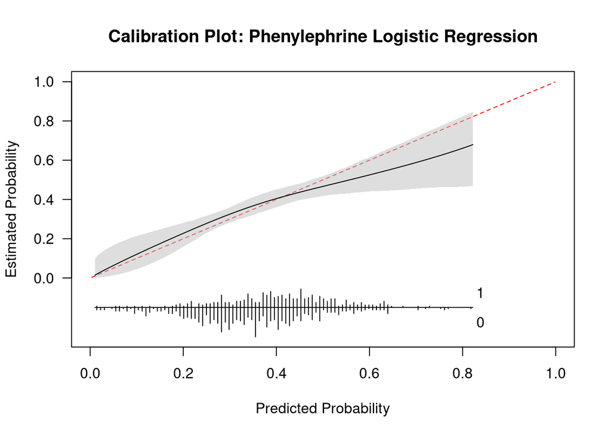

```r
pe_m1_lr_preds_cv <- pe_m1_lr_preds |>
  filter(wflow_id == "pe_m1_main_logistic") |>
  group_by(.row) |>
  summarise(
    response = first(response),
    .pred_Response = mean(.pred_Response),
    .groups = "drop"
  ) |>
  mutate(
    response_num = if_else(response == "Response", 1, 0)
  )

set.seed(2026)
pe_lr_cal <- pmcalibration(
  y = pe_m1_lr_preds_cv$response_num,
  p = pe_m1_lr_preds_cv$.pred_Response,
  ci = "boot", # n = 1000 replicates is the default
  smooth = "rcs",
  nk = 3 # 5 knots is default, 3 has less bias
  )
plot(pe_lr_cal)
title("Calibration Plot: Phenylephrine Logistic Regression")
```

```r
par(mfrow = c(1, 1))
invisible(dev.copy(pdf, "pe_logistic_calibration.pdf"))
invisible(dev.off())
```

Calibration with the logistic regression model is pretty good.

Next, assess calibration with the random forest model.

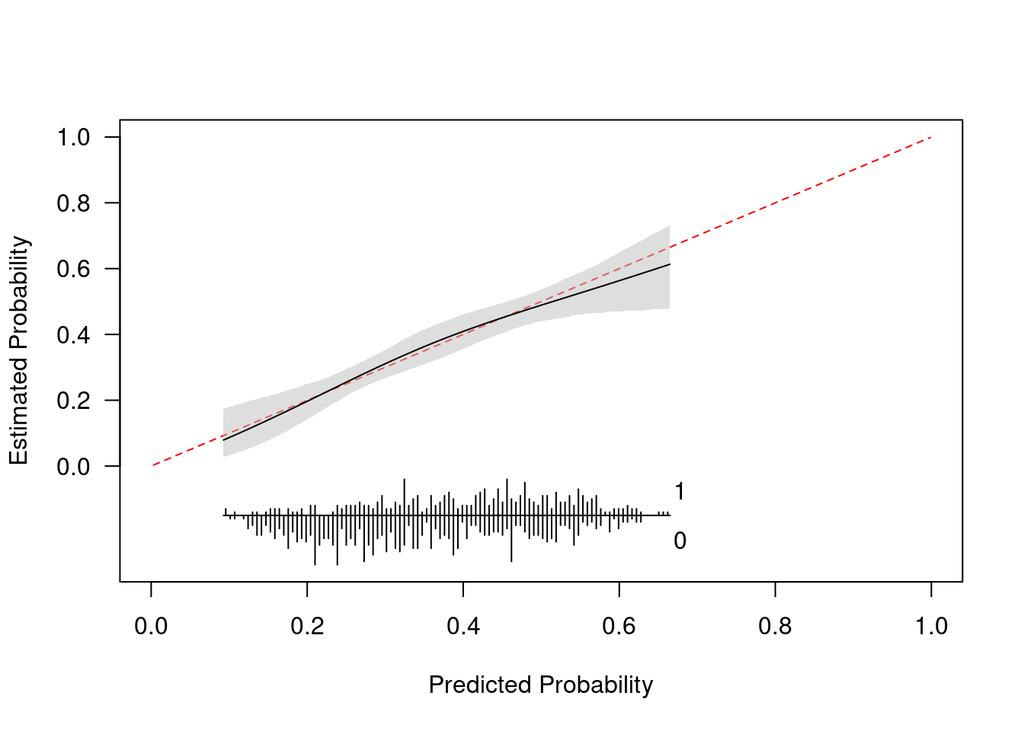

```r
pe_m3_rf_preds <- pe_m3_rf_final_fit[[1]]$cv_predictions

pe_m3_rf_preds_cv <- pe_m3_rf_preds |>
  group_by(.row) |>
  summarise(
    response = first(response),
    .pred_Response = mean(.pred_Response),
    .groups = "drop"
  ) |>
  mutate(
    response_num = if_else(response == "Response", 1, 0)
  )

set.seed(2026)
pe_rf_cal <- pmcalibration(
  y = pe_m3_rf_preds_cv$response_num,
  p = pe_m3_rf_preds_cv$.pred_Response,
  ci = "boot", # n = 1000 replicates is the default
  smooth = "rcs",
  nk = 3 # 5 knots is default, 3 has less bias
  )
```

```r
invisible(pdf("pe_rf_calibration.pdf"))
par(mfrow = c(1, 1),
    cex.axis = 1.4, cex.lab = 1.8, cex.main = 2,
    mar = c(5.1, 5.5, 1.4, 1.6), # bottom, left, top, right
    mgp = c(3.5, 1, 0)
    )
plot(pe_rf_cal)
invisible(dev.off())
```

Calibration of the phenylephrine random forest model is very good to excellent.

Save the two phenylephrine calibration plots as a panel figure.

```r
invisible(ragg::agg_tiff("pe_calibration_panel.tiff",
                         width = 11, height = 5, units = "in",
                         res = 600, compression = "lzw"
                         ))

par(mfrow = c(1, 2), pty = "s")

plot(pe_lr_cal)
title("Phenylephrine Logistic Regression (Main)")

plot(pe_rf_cal)
title("Phenylephrine Random Forest")

par(mfrow = c(1, 1))
invisible(dev.off())
```

Show the quantitative calibration metrics for comparison.

```r
(pe_cal_metrics_tbl <-
   bind_rows(
    as_tibble(pe_lr_cal$metrics, rownames = "metric") |>
      mutate(model = "Logistic (main)"),
    as_tibble(pe_rf_cal$metrics, rownames = "metric") |>
      mutate(model = "Random Forest")
  ) |>
  select(model, metric, value) |>
  pivot_wider(
    names_from = metric,
    values_from = value
  ) |>
  rename(
    Model = model,
    `Eavg (ICI)` = Eavg
  ) |>
  gt() |>
  tab_header(
    title = "Phenylephrine Models Calibration Metrics"
  ) |>
  fmt_number(
    columns = c(`Eavg (ICI)`, E50, E90, Emax, ECI),
    decimals = 4
  ) |>
  cols_align(
    align = "center"
  ))
```

Phenylephrine Models Calibration Metrics

| Model | Eavg (ICI) | E50 | E90 | Emax | ECI |
| --- | --- | --- | --- | --- | --- |
| Logistic (main) | 0.0253 | 0.0233 | 0.0476 | 0.1427 | 0.1063 |
| Random Forest | 0.0109 | 0.0099 | 0.0227 | 0.0517 | 0.0195 |

The models both have good quantitative calibration metrics, but calibration is better for the phenylephrine random forest model.

Export comparison table to Word

```r
gtsave(
  data = pe_cal_metrics_tbl,
  filename = "pe_cal_metric_comparison.docx"
)
```

### 12.4.5 Decision Curve Analysis

Extract predictions from the logistic regression and random forest models, then combine.

```r
# Extract the out-of-fold predictions for each model
# Then average predictions across the 5 CV repeats using .row
# Logistic model
pe_lr_dca <- pe_m1_lr_preds |>
  filter(wflow_id == "pe_m1_main_logistic") |>
  group_by(.row) |>
  summarise(
    response = first(response),
    p_logistic = mean(.pred_Response),
    .groups = "drop"
  )

# Random forest model
pe_rf_dca <- pe_m3_rf_final_fit[[1]]$cv_predictions |>
  group_by(.row) |>
  summarise(
    p_rf = mean(.pred_Response),
    .groups = "drop"
  )

# Combine
pe_dca_data <- pe_lr_dca |>
  left_join(pe_rf_dca, by = ".row")
```

Then run DCA and plot.

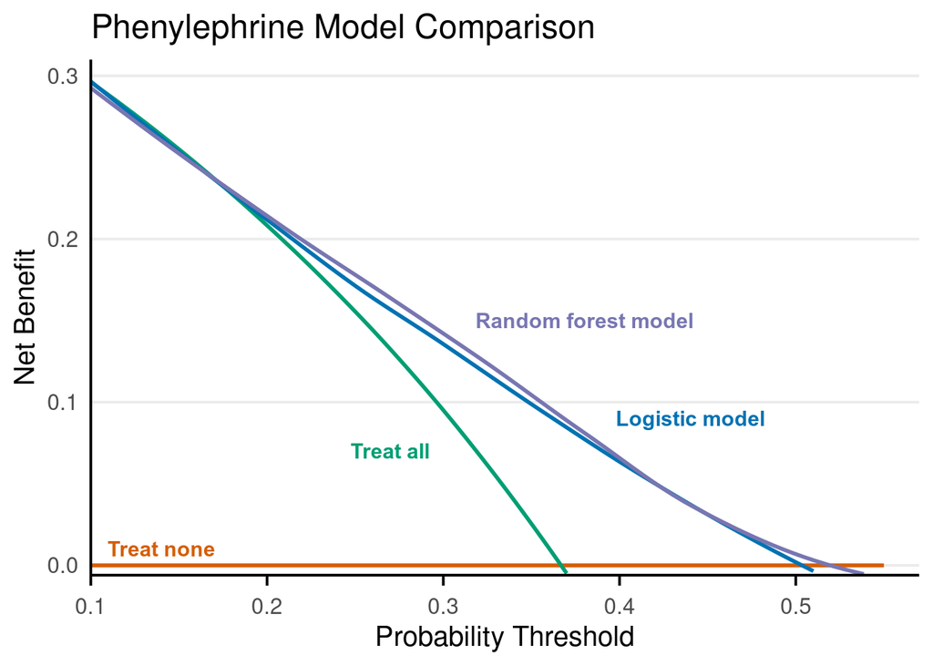

```r
pe_dca <- dca(
  response == "Response" ~ p_logistic + p_rf,
  data = pe_dca_data
  )

(pe_dca_plot <-
    ggplot(as_tibble(pe_dca) |>
             filter(net_benefit >= -0.006 &
                      net_benefit <= 0.31 &
                      threshold <=0.55
                    ) |>
             mutate(label = fct_relevel(label, "Treat None", "Treat All",
                                        "p_logistic", "p_rf"
                                        )),
           aes(x = threshold,
               y = net_benefit,
               color = label,
               group = label)) +
    geom_smooth(method = loess, formula = y ~ x, se = FALSE, linewidth = 1) +
    scale_color_manual(values = c(
      "p_logistic" = "#0072B2",
      "p_rf" = "#7876B1FF",
      "Treat All" = "#009E73",
      "Treat None" = "#D55E00"
      ),
      labels = c(
        "p_logistic" = "Logistic regression",
        "p_rf" = "Random forest",
        "Treat All" = "Treat all",
        "Treat None" = "Treat none"
      )) +
    scale_y_continuous(
      limits = c(-0.006, 0.31),
      expand = expansion(add = c(0, 0))
      ) +
    scale_x_continuous(
      limits = c(0.1, 0.55),
      breaks = seq(0,0.55, by = 0.1),
      expand = expansion(add = c(0, 0.02))
      ) +
    labs(
      title = "Phenylephrine Model Comparison",
      x = "Probability Threshold",
      y = "Net Benefit",
      color = NULL
      ) +
    annotate("text", x = 0.44, y = 0.09, label = "Logistic model",
             color = "#0072B2", family = "Arial", fontface = "bold",
             size = 4
             ) +
    annotate("text", x = 0.38, y = 0.15, label = "Random forest model",
             color = "#7876B1FF", family = "Arial", fontface = "bold",
             size = 4
             ) +
    annotate("text", x = 0.27, y = 0.07, label = "Treat all",
             color = "#009E73", family = "Arial", fontface = "bold",
             size = 4
             ) +
    annotate("text", x = 0.14, y = 0.01, label = "Treat none",
             color = "#D55E00", family = "Arial", fontface = "bold",
             size = 4
             ) +
    theme_minimal(base_size = 15) +
    theme(
      legend.position = "none",
      panel.grid.minor = element_blank(),
      panel.grid.major.x = element_blank(),
      axis.line.x = element_line(),
      axis.line.y = element_line(),
      axis.ticks.x = element_line(),
      axis.ticks.length = unit(0.2, "cm")
    ))
```

Both models are better than “Treat none” and “Treat all” in the probability threshold range from about 0.2 to 0.5, the random forest model has slightly higher net benefit than the logistic regression model.

Obtain exact threshold values for positive net benefit with logistic regression and random forest models. Filter threshold values to those corresponding to the first instance the curve crosses zero net benefit.

```r
as_tibble(pe_dca) |>
  select(threshold, label, net_benefit) |>
  pivot_wider(names_from = label, values_from = net_benefit) |>
  filter(!is.na(p_logistic), !is.na(p_rf),
         !is.na(`Treat All`), !is.na(`Treat None`),
         threshold <0.6
         ) |>
  summarise(
    min_prob_thresh_lr = min(threshold[p_logistic > `Treat All` + 0.001 &
                                         p_logistic > `Treat None` + 0.001]
                             ),
    max_prob_thresh_lr = max(threshold[p_logistic > `Treat All` + 0.001 &
                                         p_logistic > `Treat None` + 0.001]
                             ),
    min_prob_thresh_rf = min(threshold[p_rf > `Treat All` + 0.001 &
                                         p_rf > `Treat None` + 0.001]
                             ),
    max_prob_thresh_rf = max(threshold[p_rf > `Treat All` + 0.001 &
                                         p_rf > `Treat None` + 0.001]
                             )
  )
```

```
# A tibble: 1 × 4
  min_prob_thresh_lr max_prob_thresh_lr min_prob_thresh_rf
               <dbl>              <dbl>              <dbl>
1               0.16                0.5                0.2
# ℹ 1 more variable: max_prob_thresh_rf <dbl>
```

Save DCA plot

```r
ggsave(
  "pe_dca_compare.tiff",
  plot = pe_dca_plot,
  device = ragg::agg_tiff,
  width = dev.size("in")[1],
  height = dev.size("in")[2],
  units = "in",
  dpi = 600,
  compression = "lzw"
)
```

### 12.4.6 Model Selection

Among the models assessed, the random forest machine learning model for phenylephrine response demonstrated the best discrimination (similar to XGBoost), overall performance, and calibration. It also had a slightly higher net benefit in decision curve analysis than the logistic regression model. In light of these findings, the random forest model (`pe_m3_rf_ranger`) was selected as the final model for phenylephrine.

#### 12.4.6.1 Refit to Whole Derivation Dataset

Refit the final model (`pe_m3_rf_ranger`) in the whole epinephrine derivation dataset (`pe`).

```r
set.seed(2026)
pe_mod_final_wf <-
  pe_m3_rf_final_fit[[1]]$final_workflow

pe_mod_final_fit_dev <-
  fit(pe_mod_final_wf, data = pe)
```

Estimate apparent performance on derivation data.

```r
# Generate predictions
pe_dev_preds <-
  predict(
    pe_mod_final_fit_dev,
    new_data = pe,
    type = "prob"
    ) |>
  bind_cols(
    pe |> select(response)
    )

pe_dev_score_data <-
  pe_dev_preds |>
  transmute(
    response_num = if_else(response == "Response", 1, 0),
    p_rf = .pred_Response
  )

# Generate metrics
pe_dev_score <-
  Score(
    object = list(
      "Random Forest" = pe_dev_score_data$p_rf
    ),
    formula = response_num ~ 1,
    data = pe_dev_score_data,
    metrics = c("auc", "brier")
  )

# Extract and format results
auc_ci <-
  pe_dev_score$AUC$score |>
  as_tibble() |>
  transmute(
    auc = as.numeric(AUC),
    auc_lower = as.numeric(lower),
    auc_upper = as.numeric(upper)
  )

brier_ci <-
  pe_dev_score$Brier$score |>
  as_tibble() |>
  filter(model == "Random Forest") |>
  transmute(
    brier = as.numeric(Brier),
    brier_lower = as.numeric(lower),
    brier_upper = as.numeric(upper)
  )

pe_dev_mets <- cbind(auc_ci, brier_ci) |>
  mutate(
    AUROC = sprintf("%.3f (%.3f, %.3f)", auc, auc_lower, auc_upper),
    Brier = sprintf("%.3f (%.3f, %.3f)", brier, brier_lower, brier_upper)
  ) |>
  select(AUROC, Brier)
rm(auc_ci, brier_ci)

pe_dev_mets |>
  gt() |>
  tab_header(title = "Phenylephrine Random Forest Model Fit and Apparent Performance Parameters",
             subtitle = "In Derivation (Ohio) Dataset") |>
  cols_align(align = "center")
```

Phenylephrine Random Forest Model Fit and Apparent Performance Parameters

In Derivation (Ohio) Dataset

| AUROC | Brier |
| --- | --- |
| 0.840 (0.814, 0.867) | 0.174 (0.165, 0.183) |

Similar to epinephrine, the apparent performance metrics for the phenylephrine random forest model are very optimistic and substantially better than the cross-validated values (AUROC apparent 0.84 vs. CV 0.66, Brier apparent 0.17 vs. CV 0.22).

#### 12.4.6.2 Compare to Simple Model

Compare the selected multivariable model (`pe_m3_rf_ranger`) with a simple logistic regression model that only includes `neq` with a spline term.

```r
pe_m0_lr_rec_ns <-
  recipe(response ~ neq, data = pe) |>
  step_spline_natural(neq, deg_free = 5)

pe_m0_lr_preproc <- list(pe_m0_neq_only = pe_m0_lr_rec_ns)

pe_m0_lr_model <-
  workflow_set(pe_m0_lr_preproc,
               list(logistic = logistic_reg(engine = "glm")),
               cross = FALSE
               )

set.seed(2026)
train_cv <- vfold_cv(pe, v = 10, repeats = 5, strata = response)
class_metrics <- metric_set(roc_auc, brier_class)
keep_pred <- control_resamples(save_pred = TRUE, save_workflow = FALSE)

pe_m0_lr_model_fit <-
  pe_m0_lr_model |>
  workflow_map("fit_resamples", seed = 2026, verbose = TRUE,
               resamples = train_cv, metrics = class_metrics,
               control = keep_pred
               )
```

```
i 1 of 1 resampling: pe_m0_neq_only_logistic
```

```
✔ 1 of 1 resampling: pe_m0_neq_only_logistic (11.3s)
```

```r
pe_m0_lr_preds <-
  collect_predictions(pe_m0_lr_model_fit, summarize = FALSE)

pe_m0_lr_mets <-
  collect_metrics(pe_m0_lr_model_fit) |>
  # Compute 95% Wald CIs across the 50 resamples
  mutate(
    conf.low.95 = mean - qt(0.975, df = 10*5-1) * std_err,
    conf.high.95 = mean + qt(0.975, df = 10*5-1) * std_err,
    mean_ci = sprintf("%.3f (%.3f, %.3f)", mean, conf.low.95, conf.high.95)
  ) |>
  select(wflow_id, .metric, mean, conf.low.95, conf.high.95, mean_ci) |>
  pivot_wider(
    names_from = .metric,
    values_from = c(mean_ci, mean, conf.low.95, conf.high.95)
    )

bind_rows(pe_m0_lr_mets, pe_m3_rf_mets) |>
  select(wflow_id, mean_ci_roc_auc, mean_ci_brier_class) |>
  gt() |>
  tab_header(
    title = "Phenylephrine Final Model Performance vs. NE Alone",
    subtitle = "Using 10-fold Cross-Validation (5 repeats). Presented as mean (95% CI)."
    ) |>
  cols_label(
    wflow_id = "Model",
    mean_ci_roc_auc = "AUROC",
    mean_ci_brier_class = "Brier Score",
    ) |>
  cols_align(
    align = "left",
    columns = c(wflow_id)
    ) |>
  cols_align(
    align = "center",
    columns = c(mean_ci_roc_auc, mean_ci_brier_class)
    )
```

Phenylephrine Final Model Performance vs. NE Alone

Using 10-fold Cross-Validation (5 repeats). Presented as mean (95% CI).

| Model | AUROC | Brier Score |
| --- | --- | --- |
| pe_m0_neq_only_logistic | 0.496 (0.482, 0.510) | 0.234 (0.233, 0.235) |
| pe_m3_rf_ranger | 0.657 (0.642, 0.673) | 0.217 (0.214, 0.220) |

The multivariable model has better metrics than the simple model using `neq` alone. Using additional patient information beyond relying on norepinephrine dose alone provides meaningful improvement in the prediction of phenylephrine response.

# 13 Final Model Descriptors

## 13.1 Permutation Importance

Here, address the question “Which variables matter for the prediction models?”. Approach this question with permutation importance.

First, define a prediction wrapper. Then, use the `vi()` function from the `{vip}` package to determine variable importance based on AUROC through 100 simulations. The output of the function can roughly be interpreted as the average decrease in AUROC when that variable is randomly permuted

```r
pred_fun <- function(object, newdata) {
  predict(
    object,
    new_data = newdata,
    type = "prob"
    )$.pred_Response
  }

avp_vi <- vi(
  avp_mod_final_fit_dev,
  method = "permute",
  target = "response",
  metric = roc_auc_vec,
  pred_wrapper = pred_fun,
  train = avp,
  nsim = 100,
  smaller_is_better = FALSE
  ) |>
  mutate(model = factor("Vasopressin Logistic Regression"))

epi_vi <- vi(
  epi_mod_final_fit_dev,
  method = "permute",
  target = "response",
  metric = roc_auc_vec,
  pred_wrapper = pred_fun,
  train = epi,
  nsim = 100,
  smaller_is_better = FALSE
  ) |>
  mutate(model = factor("Epinephrine XGBoost"))

pe_vi <- vi(
  epi_mod_final_fit_dev,
  method = "permute",
  target = "response",
  metric = roc_auc_vec,
  pred_wrapper = pred_fun,
  train = pe,
  nsim = 100,
  smaller_is_better = FALSE
  ) |>
  mutate(model = factor("Phenylephrine Random Forest"))

all_vi <- bind_rows(avp_vi, epi_vi, pe_vi) |>
  filter(Variable != "age" & Variable != "sex" & Variable != "race_eth") |>
  group_by(model) |>
  arrange(desc(Importance), .by_group = TRUE) |>
  ungroup()
```

Then plot variable importance for each model.

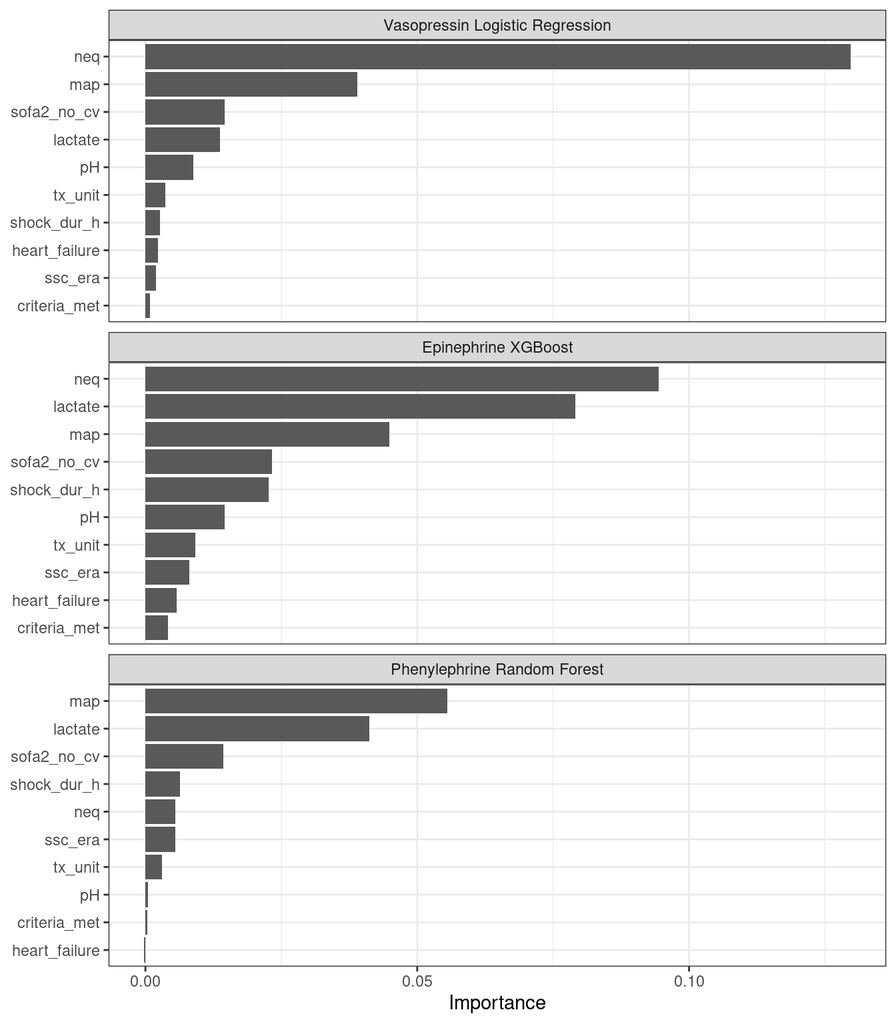

```r
(vip_plot <- ggplot(all_vi,
                   aes(x = Importance,
                       y = reorder_within(Variable, Importance, model)
                       )
                   ) +
  geom_col() +
  facet_wrap(~ model, ncol = 1, scales = "free_y") +
  scale_y_reordered() +
  labs(y = NULL))
```

This plot shows that `neq` dominates the vasopressin model and has the highest importance in the epinephrine model, whereas `map` and `lactate` become relatively more important in the phenylephrine model.

Save plot.

```r
ggsave(
  "variable_importance_plot.tiff",
  plot = vip_plot,
  device = ragg::agg_tiff,
  width = 5,
  height = 6,
  units = "in",
  dpi = 300
  )
```

## 13.2 Feature Importance

Here, address the question “How do the variables (features) influence individual predictions?”. Approach this question with SHapley Additive exPlanations (SHAP) values.

First, isolate predictor data used by each fitted model.

```r
avp_x <- avp |> select(-response)
epi_x <- epi |> select(-response)
pe_x <- pe |> select(-response)
```

Then, build SHAP values and plot with a beeswarm plot.

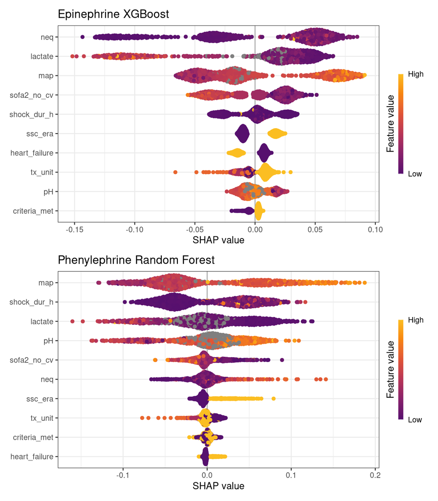

```r
pred_fun <- function(object, newdata) {
  predict(
    object,
    new_data = newdata,
    type = "prob"
  )$.pred_Response
  }

shap_epi <- fastshap::explain(
  epi_mod_final_fit_dev,
  X = epi_x,
  pred_wrapper = pred_fun,
  nsim = 200)
shap_epi <- shap_epi[, colnames(shap_epi) != "age"]
shap_epi <- shap_epi[, colnames(shap_epi) != "sex"]
shap_epi <- shap_epi[, colnames(shap_epi) != "race_eth"]

sv_epi <- shapviz(
  shap_epi,
  X = epi_x |> select(-c(age, sex, race_eth))
  )

epi_shap <- sv_importance(sv_epi, kind = "beeswarm") +
  labs(title =  "Epinephrine XGBoost")

shap_pe <- fastshap::explain(
  pe_mod_final_fit_dev,
  X = pe_x,
  pred_wrapper = pred_fun,
  nsim = 200)
shap_pe <- shap_pe[, colnames(shap_pe) != "age"]
shap_pe <- shap_pe[, colnames(shap_pe) != "sex"]
shap_pe <- shap_pe[, colnames(shap_pe) != "race_eth"]

sv_pe <- shapviz(
  shap_pe,
  X = pe_x |> select(-c(age, sex, race_eth))
  )

pe_shap <- sv_importance(sv_pe, kind = "beeswarm") +
  labs(title =  "Phenylephrine Random Forest")

(shap_panel <- epi_shap / pe_shap)
```

```r
rm(avp_x, epi_x, pe_x, shap_epi, sv_epi, epi_shap, shap_pe, sv_pe, pe_shap)
```

Save plot.

```r
ggsave(
  "shap_beeswarm_panel.tiff",
  plot = shap_panel,
  device = ragg::agg_tiff,
  width = 5,
  height = 6,
  units = "in",
  dpi = 300
  )
```

## 13.3 Decision Curve Analyses

Decision curve analyses of only the final/selected model by adjunctive vasopressor.

```r
# Vasopressin

avp_dca_data <- avp_m1_lr_preds |>
  filter(wflow_id == "avp_m1_ns_logistic") |>
  group_by(.row) |>
  summarise(
    response = first(response),
    p_logistic = mean(.pred_Response),
    .groups = "drop"
  )

avp_dca_final <- dca(
  response == "Response" ~ p_logistic,
  data = avp_dca_data
  ) |>
  as_tibble()

avp_dca_plot_final <-
  ggplot(avp_dca_final |>
           filter(net_benefit >= -0.006 &
                    net_benefit <= 0.31 &
                    threshold <=0.71
                  ) |>
           mutate(label = fct_relevel(label, "Treat None", "Treat All",
                                     "p_logistic"
                                     )),
         aes(x = threshold,
             y = net_benefit,
             color = label,
             group = label)) +
    geom_smooth(method = loess, formula = y ~ x,
                linewidth = 1, se = FALSE) +
    scale_color_manual(values = c(
      "p_logistic" = "#0072B2",
      "Treat All" = "#009E73",
      "Treat None" = "#BC3C29FF"
      ),
      labels = c(
        "p_logistic" = "Vasopressin model",
        "Treat All" = "Treat all",
        "Treat None" = "Treat none"
      )) +
    scale_y_continuous(
      limits = c(-0.006, 0.31),
      expand = expansion(add = c(0, 0))
      ) +
    scale_x_continuous(
      limits = c(0.1, 0.55),
      breaks = seq(0, 0.55, by = 0.1),
      expand = expansion(add = c(0, 0.02))
      ) +
    labs(
      x = "Probability Threshold",
      y = "Net Benefit",
      color = NULL
      ) +
    annotate("text", x = 0.48, y = 0.08, label = "Vasopressin model",
             color = "#0072B2", family = "Arial", fontface = "bold",
             size = 4
             ) +
    annotate("text", x = 0.25, y = 0.07, label = "Treat all",
             color = "#009E73", family = "Arial", fontface = "bold",
             size = 4
             ) +
    annotate("text", x = 0.14, y = 0.02, label = "Treat none",
             color = "#BC3C29FF", family = "Arial", fontface = "bold",
             size = 4
             ) +
    theme_minimal(base_size = 15) +
    theme(
      text = element_text(family = "Arial"),
      legend.position = "none",
      panel.grid.minor = element_blank(),
      panel.grid.major.x = element_blank(),
      axis.line.x = element_line(),
      axis.line.y = element_line(),
      axis.ticks.x = element_line(),
      axis.ticks.length = unit(0.2, "cm"),
      axis.title.x = element_text(family = "Arial"),
      axis.title.y = element_text(family = "Arial"),
      axis.text.x  = element_text(family = "Arial"),
      axis.text.y  = element_text(family = "Arial")
    )

epi_dca_final <- dca(
  response == "Response" ~ p_xgb,
  data = epi_dca_data
  ) |>
  as_tibble()

epi_dca_plot_final <-
    ggplot(as_tibble(epi_dca_final) |>
             filter(net_benefit >= -0.006 &
                      net_benefit <= 0.31 &
                    threshold <=0.71
                    ) |>
             mutate(label = fct_relevel(label, "Treat None", "Treat All",
                                        "p_xgb"
                                        )),
           aes(x = threshold,
               y = net_benefit,
               color = label,
               group = label)) +
    geom_smooth(method = loess, formula = y ~ x, se = FALSE, linewidth = 1) +
    scale_color_manual(values = c(
      "p_xgb" = "#7876B1FF",
      "Treat All" = "#009E73",
      "Treat None" = "#BC3C29FF"
      ),
      labels = c(
        "p_xgb" = "XGBoost",
        "Treat All" = "Treat all",
        "Treat None" = "Treat none"
      )) +
    scale_y_continuous(
      limits = c(-0.006, 0.31),
      expand = expansion(add = c(0, 0))
      ) +
    scale_x_continuous(
      limits = c(0.1, 0.55),
      breaks = seq(0,0.55, by = 0.1),
      expand = expansion(add = c(0, 0.02))
      ) +
    labs(
      x = "Probability Threshold",
      y = "Net Benefit",
      color = NULL
      ) +
    annotate("text", x = 0.45, y = 0.03, label = "Epinephrine model",
             color = "#7876B1FF", family = "Arial", fontface = "bold",
             size = 4
             ) +
    annotate("text", x = 0.19, y = 0.07, label = "Treat all",
             color = "#009E73", family = "Arial", fontface = "bold",
             size = 4
             ) +
    annotate("text", x = 0.14, y = 0.02, label = "Treat none",
             color = "#BC3C29FF", family = "Arial", fontface = "bold",
             size = 4
             ) +
    theme_minimal(base_size = 15) +
    theme(
      legend.position = "none",
      panel.grid.minor = element_blank(),
      panel.grid.major.x = element_blank(),
      axis.line.x = element_line(),
      axis.line.y = element_line(),
      axis.ticks.x = element_line(),
      axis.ticks.length = unit(0.2, "cm"),
      axis.title.x = element_text(family = "Arial"),
      axis.title.y = element_text(family = "Arial"),
      axis.text.x  = element_text(family = "Arial"),
      axis.text.y  = element_text(family = "Arial")
    )

pe_dca_final <- dca(
  response == "Response" ~ p_rf,
  data = pe_dca_data
  ) |>
  as_tibble()

pe_dca_plot_final <-
    ggplot(as_tibble(pe_dca_final) |>
             filter(net_benefit >= -0.006 &
                      net_benefit <= 0.31 &
                      threshold <=0.71
                    ) |>
             mutate(label = fct_relevel(label, "Treat None", "Treat All",
                                        "p_rf"
                                        )),
           aes(x = threshold,
               y = net_benefit,
               color = label,
               group = label)) +
    geom_smooth(method = loess, formula = y ~ x, se = FALSE, linewidth = 1) +
    scale_color_manual(values = c(
      "p_rf" = "#D55E00",
      "Treat All" = "#009E73",
      "Treat None" = "#BC3C29FF"
      ),
      labels = c(
        "p_rf" = "Random forest",
        "Treat All" = "Treat all",
        "Treat None" = "Treat none"
      )) +
    scale_y_continuous(
      limits = c(-0.006, 0.31),
      expand = expansion(add = c(0, 0))
      ) +
    scale_x_continuous(
      limits = c(0.1, 0.55),
      breaks = seq(0,0.55, by = 0.1),
      expand = expansion(add = c(0, 0.02))
      ) +
    labs(
      x = "Probability Threshold",
      y = "Net Benefit",
      color = NULL
      ) +
    annotate("text", x = 0.48, y = 0.08, label = "Phenylephrine model",
             color = "#D55E00", family = "Arial", fontface = "bold",
             size = 4
             ) +
    annotate("text", x = 0.27, y = 0.07, label = "Treat all",
             color = "#009E73", family = "Arial", fontface = "bold",
             size = 4
             ) +
    annotate("text", x = 0.14, y = 0.02, label = "Treat none",
             color = "#BC3C29FF", family = "Arial", fontface = "bold",
             size = 4
             ) +
    theme_minimal(base_size = 15) +
    theme(
      legend.position = "none",
      panel.grid.minor = element_blank(),
      panel.grid.major.x = element_blank(),
      axis.line.x = element_line(),
      axis.line.y = element_line(),
      axis.ticks.x = element_line(),
      axis.ticks.length = unit(0.2, "cm"),
      theme_minimal(base_size = 15),
      axis.title.x = element_text(family = "Arial"),
      axis.title.y = element_text(family = "Arial"),
      axis.text.x  = element_text(family = "Arial"),
      axis.text.y  = element_text(family = "Arial")
      )
```

Save plots for combining as a panel figure.

```r
ggsave(
  "avp_dca_plot_final.tiff",
  plot = avp_dca_plot_final,
  device = ragg::agg_tiff,
  width = 6,
  height = 5,
  units = "in",
  dpi = 300
  )

ggsave(
  "epi_dca_plot_final.tiff",
  plot = epi_dca_plot_final,
  device = ragg::agg_tiff,
  width = 6,
  height = 5,
  units = "in",
  dpi = 300
  )

ggsave(
  "pe_dca_plot_final.tiff",
  plot = pe_dca_plot_final,
  device = ragg::agg_tiff,
  width = 6,
  height = 5,
  units = "in",
  dpi = 300
  )
```

## 13.4 Model Performance by Subgroup

Here, assess model apparent performance (AUROC and Brier score) across clinically important subgroups. Utilize the out-of-fold predictions from each model, which corrects for optimism. Specifically, evaluate subgroup performance using out-of-fold predictions 10-fold cross-validation averaged over the 5 repeats. Then, obtain confidence intervals using 500 bootstrap resamples within each subgroup.

First, define a function to evaluate the models through bootstrap resampling (500 resamples). Then, define a function to create a reusable prediction helper.

```r
boot_classification_by_group <- function(
    preds,
    outcome,
    prob_col,
    group_var,
    positive_level = "Response",
    B = 500,
    seed = 2026
    ) {

  set.seed(seed)

  split_data <- split(preds, preds[[group_var]])

  results <- map(
    split_data,
    function(dat) {
      n <- nrow(dat)
      group_level <- dat[[group_var]][1]
      boot_res <- replicate(
        B,
        {idx <- sample.int(n, replace = TRUE)
          boot_dat <- dat[idx, ]
          auc_val <-
            if (length(unique(boot_dat[[outcome]])) < 2) {
              NA_real_
              } else {
                roc_auc_vec(
                  truth = boot_dat[[outcome]],
                  estimate = boot_dat[[prob_col]],
                  event_level = "first"
                  )
                }
          brier_val <-
            mean(
              (as.integer(boot_dat[[outcome]] == positive_level) -
                 boot_dat[[prob_col]]
               )^2
              )
          c(auc = auc_val, brier = brier_val)
          }
        )

      boot_res <- t(boot_res) |> as_tibble()

      auc_na_prop <-
        if (length(boot_res$auc) > 0) {
          mean(is.na(boot_res$auc))
          } else {
            NA_real_
            }
      auc_hat <-
        roc_auc_vec(truth = dat[[outcome]], estimate = dat[[prob_col]],
                    event_level = "first"
                    )
      brier_hat <-
        mean(
          (as.integer(dat[[outcome]] == positive_level) - dat[[prob_col]])^2
          )
      auc_ci <-
        quantile(boot_res$auc, probs = c(0.025, 0.975), na.rm = TRUE)
      brier_ci <-
        quantile(boot_res$brier, probs = c(0.025, 0.975), na.rm = TRUE)
      list(
        summary =
          tibble(
            !!group_var := group_level,
            n = n,
            events = sum(dat[[outcome]] == positive_level),
            event_rate = events / n,
            auc_est = auc_hat,
            auc_low = auc_ci[1],
            auc_high = auc_ci[2],
            brier_est = brier_hat,
            brier_low = brier_ci[1],
            brier_high = brier_ci[2],
                        auc_na_prop = auc_na_prop
            ),
        boot =
          boot_res |>
          mutate(!!group_var := group_level)
        )
      }
    )

  list(
    summary = bind_rows(map(results, "summary")),
    boot = bind_rows(map(results, "boot"))
    )
  }

get_group_predictions <- function(
    fit_obj, data, outcome_var, group_var
    ) {

  probs <-
    predict(
      fit_obj,
      new_data = data,
      type = "prob"
      )
  bind_cols(
    data |> select(all_of(outcome_var), all_of(group_var)),
    probs
    )
  }
```

Apply the functions to relevant subgroups; age (<65 vs. ≥65 years), sex, and race/ethnicity (using collapsed categories to avoid small counts within levels).

```r
# Add the variable back to predictions and collapse levels for interpretability
avp_fair_preds <-
  avp_m1_lr_preds |>
  left_join(
    avp |>
      mutate(.row = row_number()) |>
      select(.row, age, sex, race_eth),
    by = ".row"
    ) |>
  group_by(.row) |>
  summarise(
    response = first(response),
    age = first(age),
    sex = first(sex),
    race_eth = first(race_eth),
    .pred_Response = mean(.pred_Response),
    .groups = "drop"
    ) |>
  mutate(
    race_eth_collapsed = fct_collapse(
      race_eth,
      "Hispanic or Other race" = c("Hispanic or Latino", "Other, non-Hispanic",
                              "Multiracial, non-Hispanic"
                              )
      ),
    age_group = factor(if_else(age <65, "<65 years", "≥65 years"),
                       levels = c("<65 years", "≥65 years")
                       )
    ) |>
  filter(!is.na(race_eth_collapsed) & !is.na(sex))

epi_fair_preds <-
  epi_m4_xgb_final_fit[[1]]$cv_predictions |>
  left_join(
    epi |>
      mutate(.row = row_number()) |>
      select(.row, age, sex, race_eth),
    by = ".row"
    ) |>
  group_by(.row) |>
  summarise(
    response = first(response),
    age = first(age),
    sex = first(sex),
    race_eth = first(race_eth),
    .pred_Response = mean(.pred_Response),
    .groups = "drop"
    ) |>
  mutate(
    race_eth_collapsed = fct_collapse(
      race_eth,
      "Hispanic or Other race" = c("Hispanic or Latino", "Other, non-Hispanic",
                              "Multiracial, non-Hispanic"
                              )
      ),
    age_group = factor(if_else(age <65, "<65 years", "≥65 years"),
                       levels = c("<65 years", "≥65 years")
                       )
    ) |>
  filter(!is.na(race_eth_collapsed) & !is.na(sex))

pe_fair_preds <-
  pe_m3_rf_final_fit[[1]]$cv_predictions |>
  left_join(
    pe |>
      mutate(.row = row_number()) |>
      select(.row, age, sex, race_eth),
    by = ".row"
    ) |>
  group_by(.row) |>
  summarise(
    response = first(response),
    age = first(age),
    sex = first(sex),
    race_eth = first(race_eth),
    .pred_Response = mean(.pred_Response),
    .groups = "drop"
    ) |>
  mutate(
    race_eth_collapsed = fct_collapse(
      race_eth,
      "Hispanic or Other race" = c("Hispanic or Latino", "Other, non-Hispanic",
                              "Multiracial, non-Hispanic"
                              )
      ),
    age_group = factor(if_else(age <65, "<65 years", "≥65 years"),
                       levels = c("<65 years", "≥65 years")
                       )
    ) |>
  filter(!is.na(race_eth_collapsed) & !is.na(sex))

# Pass the predictions to the bootstrap function for each strata
avp_age_perf <-
  boot_classification_by_group(
    preds = avp_fair_preds,
    outcome = "response",
    prob_col = ".pred_Response",
    group_var = "age_group",
    positive_level = "Response",
    B = 500
  )

avp_sex_perf <-
  boot_classification_by_group(
    preds = avp_fair_preds,
    outcome = "response",
    prob_col = ".pred_Response",
    group_var = "sex",
    positive_level = "Response",
    B = 500
  )

avp_race_perf <-
  boot_classification_by_group(
    preds = avp_fair_preds,
    outcome = "response",
    prob_col = ".pred_Response",
    group_var = "race_eth_collapsed",
    positive_level = "Response",
    B = 500
    )

epi_age_perf <-
  boot_classification_by_group(
    preds = epi_fair_preds,
    outcome = "response",
    prob_col = ".pred_Response",
    group_var = "age_group",
    positive_level = "Response",
    B = 500
  )

epi_sex_perf <-
  boot_classification_by_group(
    preds = epi_fair_preds,
    outcome = "response",
    prob_col = ".pred_Response",
    group_var = "sex",
    positive_level = "Response",
    B = 500
  )

epi_race_perf <-
  boot_classification_by_group(
    preds = epi_fair_preds,
    outcome = "response",
    prob_col = ".pred_Response",
    group_var = "race_eth_collapsed",
    positive_level = "Response",
    B = 500
    )

pe_age_perf <-
  boot_classification_by_group(
    preds = pe_fair_preds,
    outcome = "response",
    prob_col = ".pred_Response",
    group_var = "age_group",
    positive_level = "Response",
    B = 500
  )

pe_sex_perf <-
  boot_classification_by_group(
    preds = pe_fair_preds,
    outcome = "response",
    prob_col = ".pred_Response",
    group_var = "sex",
    positive_level = "Response",
    B = 500
  )

pe_race_perf <-
  boot_classification_by_group(
    preds = pe_fair_preds,
    outcome = "response",
    prob_col = ".pred_Response",
    group_var = "race_eth_collapsed",
    positive_level = "Response",
    B = 500
    )
```

Combine results into one tibble

```r
perf_mets <- bind_rows(
  bind_rows(
    avp_age_perf$summary |>
      rename(group = age_group) |>
      mutate(variable = "Age"),
    avp_sex_perf$summary |>
      rename(group = sex) |>
      mutate(variable = "Sex"),
    avp_race_perf$summary |>
      rename(group = race_eth_collapsed) |>
      mutate(variable = "Race/Ethnicity")
    ) |>
    mutate(medication = "Vasopressin"),

  bind_rows(
    epi_age_perf$summary |>
      rename(group = age_group) |>
      mutate(variable = "Age"),
    epi_sex_perf$summary |>
      rename(group = sex) |>
      mutate(variable = "Sex"),
    epi_race_perf$summary |>
      rename(group = race_eth_collapsed) |>
      mutate(variable = "Race/Ethnicity")
    ) |>
    mutate(medication = "Epinephrine"),

  bind_rows(
    pe_age_perf$summary |>
      rename(group = age_group) |>
      mutate(variable = "Age"),
    pe_sex_perf$summary |>
      rename(group = sex) |>
      mutate(variable = "Sex"),
    pe_race_perf$summary |>
      rename(group = race_eth_collapsed) |>
      mutate(variable = "Race/Ethnicity")
    ) |>
    mutate(medication = "Phenylephrine")
  ) |>
  mutate(
    group_label = paste0(variable, ": ", group),
    group_order = factor(
      group_label,
      levels = c("Age: <65 years", "Age: ≥65 years", "Sex: Female",
                 "Sex: Male", "Race/Ethnicity: Black, non-Hispanic",
                 "Race/Ethnicity: Hispanic or Other race",
                 "Race/Ethnicity: White, non-Hispanic"
                 )
      )
  ) |>
  select(medication, variable, group_label, auc_est, auc_low, auc_high,
         brier_est, brier_low, brier_high, group_order
         ) |>
  pivot_longer(
    cols = matches("^(auc|brier)_"),
    names_to = c("metric", ".value"),
    names_pattern = "(auc|brier)_(est|low|high)"
    ) |>
  mutate(
    metric = recode(metric, auc = "AUROC", brier = "Brier Score"),
    medication = factor(
      medication,
      levels = c("Vasopressin", "Epinephrine", "Phenylephrine")
      ),
    variable = factor(variable, levels = c("Age", "Sex", "Race/Ethnicity"))
    )
```

Lastly, plot the results

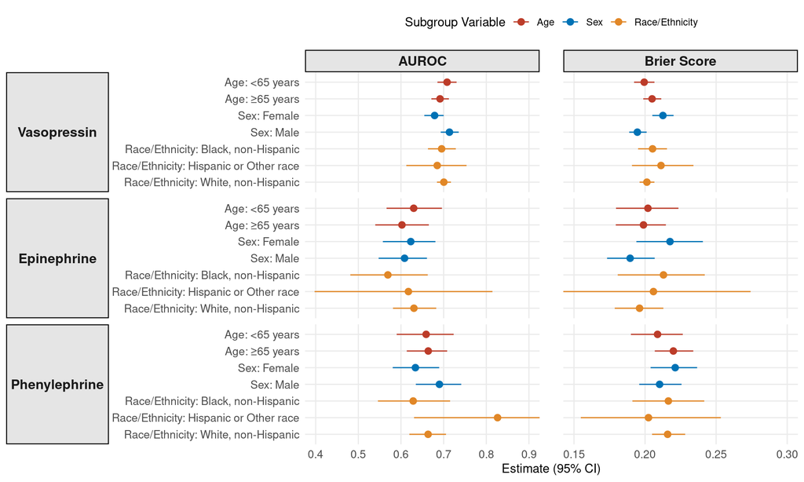

```r
perf_mets |>
  ggplot(aes(x = est, y = fct_rev(group_order), color = variable)) +
  geom_point(size = 2.5) +
  geom_errorbar(aes(xmin = low, xmax = high), width = 0, orientation = "y") +
  facet_grid(
    medication ~ metric,
    scales = "free_x",
    switch = "y"
    ) +
  scale_color_nejm() +
  labs(
    x = "Estimate (95% CI)",
    y = NULL,
    color = "Subgroup Variable"
    ) +
  guides(color = guide_legend(nrow = 1)) +
  theme_minimal() +
  theme(
    strip.placement = "outside",
    strip.background = element_rect(
      fill = "grey90",
      color = "black", linewidth = 0.8
      ),
    strip.text.y.left = element_text(
      angle = 0,
      face = "bold",
      size = 12
      ),
    strip.text.x = element_text(
      face = "bold",
      size = 12
      ),
    axis.text.y = element_text(size = 10),
    axis.text.x = element_text(size = 10),
    panel.grid.minor = element_blank(),
    legend.position = "top",
    legend.direction = "horizontal",
    panel.spacing.x = unit(0.75, "cm")
    ) +
  facetted_pos_scales(
    x = list(
      metric == "AUROC" ~
        scale_x_continuous(
          limits = c(0.4, 0.9),
          breaks = seq(0.4, 0.9, 0.1)
          ),
      metric == "Brier Score" ~
        scale_x_continuous(
          limits = c(0.15, 0.30),
          breaks = seq(0.15, 0.30, 0.05)
          )
      )
    )
```

```r
# Save plot
ggsave(
  "fairness_plot.tiff",
  device = ragg::agg_tiff,
  width = 9,
  height = 6,
  units = "in",
  dpi = 300
  )
```

There are no concerns for model fairness across subgroups.

# 14 Decision Model Validation

The decision model will be validated in the validation (`fl`) dataset using a discordance analysis framework as described in [Dalton 2016](https://journals.sagepub.com/doi/10.1177/0272989X15578835). First, the dataset will be described. Next, the final models for each vasopressor (vasopressin == logistic regression with spline term (`avp_m1_ns_logistic`), epinephrine == gradient boosted trees with XGBoost (`epi_m4_boost_xgboost`), phenylephrine == random forest (`pe_m3_rf_ranger`)) will be applied to each observation in the validation dataset. The vasopressor with the highest predicted probability of response will be considered the decision model-recommended vasopressor. Then, this recommended therapy will be compared to the observed treatment the patient received during usual care. Concordance will be defined as receipt of the adjunctive vasopressor recommended by the decision model, whereas discordance will be defined as receipt of a different adjunctive vasopressor. Observed outcomes will be compared between concordant and discordant treatment decisions. The discordance analysis will estimate the global effectiveness of the decision model, defined as the odds ratio for hemodynamic response at 6 hours comparing concordant and discordant therapy using logistic regression.

Subgroup and sensitivity analyses for the decision model effectiveness will be performed. In the first subgroup analysis, concordance effectiveness will be evaluated according to the specific adjunctive vasopressor recommended by the decision model. In the second and third subgroup analyses, concordance effectiveness will be assessed in relation to decision model recommendation strength, defined by the difference in predicted response probabilities between the highest- and second-highest-ranked therapies and by quartiles of the corresponding decision model odds ratio, respectively. In the first sensitivity analysis, practical equivalence of probabilities will be considered for the medications with difference in predicted response probability zones of ≤0.05 or ≤0.10 compared with the highest-ranked therapy. Receipt of any therapy with a probability in the zone will be considered concordant. In the second sensitivity analysis, only vasopressin and epinephrine will be considered eligible adjunctive vasopressors in the decision model, consistent with current guideline recommendations.

## 14.1 Validation Cohort Patient Characteristics

Describe the characteristics of included patients in the validation (Florida) cohort by adjunctive vasopressor agent. Notably, the below table includes characteristics that were not used as model variables (predictors). Further, because antimicrobials are components of the clinical criteria (CDC ASE and Sepsis-3) used to identify patients with septic shock, each included patient received antimicrobials as part of their sepsis treatment course.

```r
(val_char_by_adj <- incl |>
   filter(first_adj_hosp_state == "Florida") |>
   droplevels() |>
   mutate(first_adj_hosp_beds_cat =
            fct_relevel(first_adj_hosp_beds_cat, "<200", "200-499"),
          ssc_era = fct_relevel(ssc_era, "SSC 2008", "SSC 2012", "SSC 2016"),
          adv_resp_before_adj =
            fct_relevel(adv_resp_before_adj, "Adv Resp Before Adjunct"),
          mv_before_adj = fct_relevel(mv_before_adj, "MV Before Adjunct"),
          response = fct_relevel(response, "Response"),
          first_adj = fct_recode(first_adj, "Vasopressin" = "vasopressin",
                                 "Epinephrine" = "epinephrine",
                                 "Phenylephrine" = "phenylephrine"
                                 )
          ) |>
  select(age, sex, first_adj_wt_kg, race_eth, elixhauser_index,
         cerebrovascular_disease, hypertension, heart_failure,
         valvular_disease, chronic_pulmonary_disease,
         pulmonary_circulation_disease, liver_disease, kidney_disease,
         malignancy, diabetes, obesity, alcohol_abuse, first_adj_lvef,
         first_adj_hosp_beds_cat, first_adj_hosp_teaching_status,
         first_adj_tx_unit, ssc_era,  criteria_met, comm_onset, prior_surg,
         first_adj_sofa_2, first_adj_abx, adv_resp_before_adj, mv_before_adj,
         first_adj_pH, first_adj_aki, rrt_before_adj, first_adj_temp_c,
         first_adj_heart_rate, first_adj_resp_rate, first_adj_map,
         first_adj_lactate, first_adj_lvef, first_adj_fluid_mL,
         first_adj_fluid_mL_kg, adj_baseline_neq, adj_baseline_neq_mcg_min,
         dbt_before_adj, first_adj_steroid, first_adj, hours_to_first_adj,
         abx_days, mort_hosp, response
         ) |>
  tbl_summary(
    by = first_adj,
    digits = list(
      all_categorical() ~ c(0, 1),
      first_adj_sofa_2 ~ 0,
      first_adj_temp_c ~ 1
      ),
    label = list(response = "Adjunct Response",
                 age = "Age",
                 sex = "Sex",
                 race_eth = "Race/Ethnicity",
                 prior_surg = "Prior surgery",
                 elixhauser_index = "Elixhauser comorbidity index",
                 ssc_era = "Surviving Sepsis Campaign guideline treatment era",
                 wt_kg = "Weight (kg)",
                 first_adj_hosp_beds_cat = "Hospital beds",
                 first_adj_hosp_teaching_status = "Teaching status",
                 first_adj_tx_unit = "Treatment unit",
                 criteria_met = "Clinical criteria met",
                 first_adj_lvef = "LVEF (%)",
                 first_adj_sofa_2 = "SOFA-2",
                 adv_resp_before_adj = "Advanced respiratory support",
                 mv_before_adj = "Mechanical ventilation",
                 rrt_before_adj = "Kidney replacement therapy",
                 first_adj_fluid_mL = "Fluid bolus volume administered (mL)",
                 first_adj_fluid_mL_kg = "Fluid bolus volume administered (mL/kg)",
                 first_adj_steroid = "Corticosteroid administration",
                 adj_baseline_neq = "NE dosage (mcg/kg/min)",
                 adj_baseline_neq_mcg_min = "NE dosage (mcg/min)",
                 pressors_dur_hours = "Vasopressor duration (hours)",
                 abx_days = "Antibiotic duration (days)",
                 mort_hosp = "In-Hospital mortality",
                 first_adj = "First Adjunctive Vasopressor",
                 dbt_before_adj = "Dobutamine administration"
                 ),
   missing = "ifany"
    ) |>
   add_overall() |>
   modify_fmt_fun(
     all_stat_cols() ~ function(x) gsub("%", "", x)
  ) |>
  modify_caption("**Patient Characteristics in Validation (Florida) Dataset by Adjunct**")
 )
```

**Patient Characteristics in Validation (Florida) Dataset by Adjunct**

| **Characteristic** | **Overall** N = 1,128<sup>1</sup> | **Vasopressin** N = 976<sup>1</sup> | **Epinephrine** N = 95<sup>1</sup> | **Phenylephrine** N = 57<sup>1</sup> |
| --- | --- | --- | --- | --- |
| Age | 69 (59, 77) | 69 (59, 77) | 68 (58, 78) | 71 (60, 79) |
| Sex |  |  |  |  |
| Female | 471 (41.8) | 413 (42.3) | 32 (33.7) | 26 (45.6) |
| Male | 657 (58.2) | 563 (57.7) | 63 (66.3) | 31 (54.4) |
| first_adj_wt_kg | 80 (67, 96) | 80 (67, 96) | 80 (68, 96) | 75 (59, 92) |
| Unknown | 13 | 8 | 2 | 3 |
| Race/Ethnicity |  |  |  |  |
| Black, non-Hispanic | 150 (13.5) | 139 (14.4) | 8 (8.5) | 3 (5.6) |
| Hispanic or Latino | 200 (18.0) | 172 (17.9) | 22 (23.4) | 6 (11.1) |
| Multiracial, non-Hispanic | 19 (1.7) | 18 (1.9) | 1 (1.1) | 0 (0.0) |
| Other, non-Hispanic | 21 (1.9) | 17 (1.8) | 2 (2.1) | 2 (3.7) |
| White, non-Hispanic | 721 (64.9) | 617 (64.1) | 61 (64.9) | 43 (79.6) |
| Unknown | 17 | 13 | 1 | 3 |
| Elixhauser comorbidity index | 5 (0, 17) | 5 (0, 17) | 3 (0, 16) | 2 (0, 23) |
| cerebrovascular_disease | 71 (6.3) | 58 (5.9) | 8 (8.4) | 5 (8.8) |
| hypertension | 355 (31.5) | 303 (31.0) | 30 (31.6) | 22 (38.6) |
| heart_failure | 175 (15.5) | 142 (14.5) | 24 (25.3) | 9 (15.8) |
| valvular_disease | 104 (9.2) | 81 (8.3) | 15 (15.8) | 8 (14.0) |
| chronic_pulmonary_disease | 111 (9.8) | 98 (10.0) | 8 (8.4) | 5 (8.8) |
| pulmonary_circulation_disease | 66 (5.9) | 61 (6.3) | 3 (3.2) | 2 (3.5) |
| liver_disease | 117 (10.4) | 104 (10.7) | 5 (5.3) | 8 (14.0) |
| kidney_disease | 160 (14.2) | 141 (14.4) | 11 (11.6) | 8 (14.0) |
| malignancy | 231 (20.5) | 209 (21.4) | 12 (12.6) | 10 (17.5) |
| diabetes | 166 (14.7) | 143 (14.7) | 13 (13.7) | 10 (17.5) |
| obesity | 162 (14.4) | 146 (15.0) | 9 (9.5) | 7 (12.3) |
| alcohol_abuse | 35 (3.1) | 28 (2.9) | 3 (3.2) | 4 (7.0) |
| LVEF (%) | 56 (40, 64) | 58 (41, 65) | 55 (30, 60) | 53 (39, 56) |
| Unknown | 683 | 602 | 45 | 36 |
| Hospital beds |  |  |  |  |
| <200 | 92 (8.2) | 73 (7.5) | 7 (7.4) | 12 (21.1) |

[output cut: 76 more lines]

<sup>1</sup> Median (Q1, Q3); n (%)

Export to Word

```r
as_flex_table(val_char_by_adj) |>
  autofit() |>
  set_table_properties(layout = "autofit") |>
  font(fontname = "Arial", part = "all") |>
  fontsize(size = 10, part = "all") |>
  line_spacing(space = 1, part = "all") |>
  padding(padding.top = 0, padding.bottom = 0, part = "all") |>
  save_as_docx(
    path = "val_characteristics_by_adjunct.docx",
    pr_section = prop_section(
      page_size = page_size(orient = "landscape", width = 11, height = 8.5),
      page_margins = page_mar(top = 0.5, bottom = 0.5, left = 0.5, right = 0.5)
      )
    )
```

## 14.2 Validation Data Adjustments and Assessment

### 14.2.1 Data Adjustments

Rename variables in the validation (`fl`) dataset to match those in the derivation (`oh`) dataset, then align categorical variable levels.

```r
fl <- fl |>
  rename(sofa2_no_cv = first_adj_sofa_2_no_cv, pH = first_adj_pH,
         neq = adj_baseline_neq, shock_dur_h = hours_to_first_adj,
         map = first_adj_map, lactate = first_adj_lactate
         ) |>
  mutate(response = fct_relevel(response, "Response", "No Response"),
         tx_unit = factor(if_else(first_adj_tx_unit == "Surgical ICU" |
                                    first_adj_tx_unit == "Mixed Med/Surg ICU",
                                  "Surgical or Mixed Med/Surg ICU",
                                  first_adj_tx_unit
                                  ),
                          levels = c("Medical ICU", "Cardiac ICU",
                                     "ED/Rapid Response",
                                     "Surgical or Mixed Med/Surg ICU"
                                     )),
         ssc_era_orig = ssc_era,
         ssc_era = factor(if_else(ssc_era == "SSC 2021",
                                  "SSC 2021",
                                  "Before SSC 2021"
                                  ),
                          levels = c("Before SSC 2021", "SSC 2021")
                          ),
         criteria_met = factor(if_else(criteria_met == "ASE only",
                                       "ASE only",
                                       "Both or Sepsis-3 only"
                                       ),
                               levels = c("ASE only", "Both or Sepsis-3 only")
                               )
         )
```

Show a table of the observed first adjunctive vasopressor received as part of the therapy course in the validation dataset (`fl`).

```r
fl |> tabyl(first_adj) |>
  adorn_totals() |>
  adorn_pct_formatting() |>
  kable(align = c('lcc'),
        caption = "First Adjunct Received in Validation (Florida) Dataset"
        ) |>
  kable_paper(full_width = FALSE)
```

First Adjunct Received in Validation (Florida) Dataset

| first_adj | n | percent |
| --- | --- | --- |
| vasopressin | 976 | 86.5% |
| epinephrine | 95 | 8.4% |
| phenylephrine | 57 | 5.1% |
| Total | 1128 | 100.0% |

The majority (86.5%) of patients in the validation dataset received vasopressin as the first adjunctive vasopressor.

### 14.2.2 Dataset Description

Show date of final follow-up (maximum hospital discharge date).

```r
max(incl$discharge_time[incl$first_adj_hosp_state == "Florida"])
```

```
[1] "2025-01-03 19:30:00 UTC"
```

Show response frequency by first adjunctive vasopressor.

```r
fl |>
  tabyl(response, first_adj) |>
  adorn_totals(where = c("row", "col")) |>
  adorn_percentages(denominator = "col")|>
  adorn_pct_formatting() |>
  adorn_ns(position = "front") |>
  adorn_title(placement = "combined") |>
  kable(align = c('lcc'),
        caption = "Response by First Adjunctive Vasopressor (Validation Cohort)"
        ) |>
  kable_paper(full_width = FALSE)
```

Response by First Adjunctive Vasopressor (Validation Cohort)

| response/first_adj | vasopressin | epinephrine | phenylephrine | Total |
| --- | --- | --- | --- | --- |
| Response | 274 (28.1%) | 21 (22.1%) | 20 (35.1%) | 315 (27.9%) |
| No Response | 702 (71.9%) | 74 (77.9%) | 37 (64.9%) | 813 (72.1%) |
| Total | 976 (100.0%) | 95 (100.0%) | 57 (100.0%) | 1,128 (100.0%) |

There are 976 included patients who received vasopressin as the first adjunctive vasopressor, 95 who received epinephrine, and 57 who received phenylephrine. Adjunctive vasopressor response was observed in 274 (28.1%) patients receiving vasopressin, 21 (22.1%) receiving epinephrine, and 20 (35.1%) receiving phenylephrine. Notably, these response frequencies are each lower than those observed in the derivation (Ohio) dataset.

Show a numerical description of all predictors in the validation dataset.

```r
(val_predictors_by_adjunct <- fl |>
  select(first_adj, heart_failure, tx_unit, ssc_era, criteria_met, sofa2_no_cv,
            pH, neq, shock_dur_h, map, lactate
            ) |>
  mutate(first_adj = fct_recode(first_adj, "Vasopressin" = "vasopressin",
                                "Epinephrine" = "epinephrine",
                                "Phenylephrine" = "phenylephrine"
                                )
         ) |>
  tbl_summary(
    by = first_adj,
    digits = list(
      all_categorical() ~ c(0, 1),
      sofa2_no_cv ~ 0
      ),
    label = list(heart_failure = "History of heart failure",
                 tx_unit = "Treatment unit",
                 ssc_era = "Surviving Sepsis Campaign guideline treatment era",
                 criteria_met = "Clinical criteria met",
                 sofa2_no_cv = "SOFA-2 (without cardiovascular score)",
                 pH = "Arterial pH",
                 neq = "Norepinephrine dosage (mcg/kg/min)",
                 shock_dur_h = "Shock duration (hours)",
                 map = "MAP (mm Hg)",
                 lactate = "Lactate (mmol/L)"
                 ),
    missing = "no"
    ) |>
   add_overall() |>
   modify_fmt_fun(
     all_stat_cols() ~ function(x) gsub("%", "", x)
  ) |>
  modify_caption("**Predictor Values in Validation (Florida) Dataset**"))
```

**Predictor Values in Validation (Florida) Dataset**

| **Characteristic** | **Overall** N = 1,128<sup>1</sup> | **Vasopressin** N = 976<sup>1</sup> | **Epinephrine** N = 95<sup>1</sup> | **Phenylephrine** N = 57<sup>1</sup> |
| --- | --- | --- | --- | --- |
| History of heart failure | 175 (15.5) | 142 (14.5) | 24 (25.3) | 9 (15.8) |
| Treatment unit |  |  |  |  |
| Medical ICU | 529 (46.9) | 501 (51.3) | 15 (15.8) | 13 (22.8) |
| Cardiac ICU | 0 (0.0) | 0 (0.0) | 0 (0.0) | 0 (0.0) |
| ED/Rapid Response | 125 (11.1) | 105 (10.8) | 17 (17.9) | 3 (5.3) |
| Surgical or Mixed Med/Surg ICU | 474 (42.0) | 370 (37.9) | 63 (66.3) | 41 (71.9) |
| Surviving Sepsis Campaign guideline treatment era |  |  |  |  |
| Before SSC 2021 | 521 (46.2) | 458 (46.9) | 45 (47.4) | 18 (31.6) |
| SSC 2021 | 607 (53.8) | 518 (53.1) | 50 (52.6) | 39 (68.4) |
| Clinical criteria met |  |  |  |  |
| ASE only | 389 (34.5) | 335 (34.3) | 33 (34.7) | 21 (36.8) |
| Both or Sepsis-3 only | 739 (65.5) | 641 (65.7) | 62 (65.3) | 36 (63.2) |
| SOFA-2 (without cardiovascular score) | 5 (3, 7) | 5 (3, 7) | 4 (3, 6) | 4 (3, 7) |
| Arterial pH | 7.31 (7.21, 7.38) | 7.31 (7.21, 7.38) | 7.29 (7.19, 7.38) | 7.35 (7.26, 7.39) |
| Norepinephrine dosage (mcg/kg/min) | 0.20 (0.12, 0.32) | 0.22 (0.13, 0.32) | 0.11 (0.06, 0.29) | 0.13 (0.07, 0.23) |
| Shock duration (hours) | 4 (2, 11) | 4 (2, 11) | 3 (1, 11) | 4 (2, 12) |
| MAP (mm Hg) | 69 (62, 78) | 69 (61, 78) | 74 (64, 84) | 69 (65, 77) |
| Lactate (mmol/L) | 3.1 (1.7, 6.0) | 3.1 (1.8, 5.9) | 4.0 (1.5, 7.7) | 3.1 (1.9, 5.5) |

<sup>1</sup> n (%); Median (Q1, Q3)

Export to Word

```r
as_flex_table(val_predictors_by_adjunct) |>
  autofit() |>
  set_table_properties(layout = "autofit") |>
  font(fontname = "Arial", part = "all") |>
  fontsize(size = 10, part = "all") |>
  line_spacing(space = 1, part = "all") |>
  padding(padding.top = 0, padding.bottom = 0, part = "all") |>
  save_as_docx(
    path = "val_predictors_by_adjunct.docx",
    pr_section = prop_section(
      page_size = page_size(orient = "landscape", width = 11, height = 8.5),
      page_margins = page_mar(top = 0.5, bottom = 0.5, left = 0.5, right = 0.5)
      )
    )
```

Next, evaluate for missing data in the outcome variable (`response`).

```r
fl |> select(response) |>
  miss_var_summary() |> mutate(pct_miss = as.numeric(pct_miss)) |>
  kable(digits = 3,
        caption = "Missingness in Outcome in Validation (Florida) Data"
        ) |>
  kable_paper(full_width = FALSE)
```

Missingness in Outcome in Validation (Florida) Data

| variable | n_miss | pct_miss |
| --- | --- | --- |
| response | 0 | 0 |

There are no missing values in the outcome variable.

Evaluate for missing data in the model predictors.

```r
fl |>
  group_by(first_adj) |>
  select(response, first_adj, heart_failure, tx_unit, ssc_era, criteria_met,
         sofa2_no_cv, pH, neq, shock_dur_h, map, lactate
         ) |>
  miss_var_summary() |>
  mutate(pct_miss = as.numeric(pct_miss)) |>
  kable(digits = 1,
        caption = "Missingness in Predictors in Validation (Florida) Data"
        ) |>
  kable_paper(full_width = FALSE)
```

Missingness in Predictors in Validation (Florida) Data

| first_adj | variable | n_miss | pct_miss |
| --- | --- | --- | --- |
| vasopressin | pH | 591 | 60.6 |
| vasopressin | lactate | 89 | 9.1 |
| vasopressin | map | 21 | 2.2 |
| vasopressin | response | 0 | 0.0 |
| vasopressin | heart_failure | 0 | 0.0 |
| vasopressin | tx_unit | 0 | 0.0 |
| vasopressin | ssc_era | 0 | 0.0 |
| vasopressin | criteria_met | 0 | 0.0 |
| vasopressin | sofa2_no_cv | 0 | 0.0 |
| vasopressin | neq | 0 | 0.0 |
| vasopressin | shock_dur_h | 0 | 0.0 |
| epinephrine | pH | 54 | 56.8 |
| epinephrine | lactate | 16 | 16.8 |
| epinephrine | map | 5 | 5.3 |
| epinephrine | response | 0 | 0.0 |
| epinephrine | heart_failure | 0 | 0.0 |
| epinephrine | tx_unit | 0 | 0.0 |
| epinephrine | ssc_era | 0 | 0.0 |
| epinephrine | criteria_met | 0 | 0.0 |
| epinephrine | sofa2_no_cv | 0 | 0.0 |
| epinephrine | neq | 0 | 0.0 |
| epinephrine | shock_dur_h | 0 | 0.0 |
| phenylephrine | pH | 40 | 70.2 |
| phenylephrine | lactate | 8 | 14.0 |
| phenylephrine | map | 2 | 3.5 |
| phenylephrine | response | 0 | 0.0 |
| phenylephrine | heart_failure | 0 | 0.0 |
| phenylephrine | tx_unit | 0 | 0.0 |
| phenylephrine | ssc_era | 0 | 0.0 |
| phenylephrine | criteria_met | 0 | 0.0 |
| phenylephrine | sofa2_no_cv | 0 | 0.0 |
| phenylephrine | neq | 0 | 0.0 |
| phenylephrine | shock_dur_h | 0 | 0.0 |

There are missing data in the same predictors in the validation dataset as in the derivation dataset (`pH`, `lactate`, and `map`). Missing data in these variables is managed through imputation in a `recipes()` step for each model.

## 14.3 Create and Assess Decision Model

Generate predicted response probability in the validation dataset (`fl`) using the final clinical prediction models for response to vasopressin (logistic regression with a spline term for NEQ; `avp_m1_ns_logistic`), epinephrine (boosted trees with XGBoost; `epi_m4_boost_xgboost`), and phenylephrine (random forest; `pe_m3_rf_ranger`).

```r
avp_val_preds <-
  predict(
    avp_mod_final_fit_dev,
    new_data = fl,
    type = "prob"
    ) |>
  select(avp_pred_response_prob = .pred_Response)

epi_val_preds <-
  predict(
    epi_mod_final_fit_dev,
    new_data = fl,
    type = "prob"
    ) |>
  select(epi_pred_response_prob = .pred_Response)

pe_val_preds <-
  predict(
    pe_mod_final_fit_dev,
    new_data = fl,
    type = "prob"
    ) |>
  select(pe_pred_response_prob = .pred_Response)

fl_aug <-
  cbind(fl, avp_val_preds, epi_val_preds, pe_val_preds)
# Remove objects that won't be used moving forward
rm(avp_val_preds, epi_val_preds, pe_val_preds)
```

Show a numerical summary of the predicted probabilities of response by adjunctive vasopressor.

```r
describe(fl_aug |> select(avp_pred_response_prob, epi_pred_response_prob,
                          pe_pred_response_prob
                          )
         )
```

```
select(fl_aug, avp_pred_response_prob, epi_pred_response_prob, pe_pred_response_prob)

 3  Variables      1128  Observations
----------------------------------------------------------------------
avp_pred_response_prob
       n  missing distinct     Info     Mean  pMedian      Gmd
    1128        0     1128        1    0.298   0.2921     0.19
     .05      .10      .25      .50      .75      .90      .95
 0.06269  0.08733  0.15892  0.28556  0.41979  0.52270  0.57938

lowest : 0.00688296 0.014263   0.0182585  0.0193515  0.0219763
highest: 0.766558   0.777758   0.803707   0.808867   0.843636
----------------------------------------------------------------------
epi_pred_response_prob
       n  missing distinct     Info     Mean  pMedian      Gmd
    1128        0     1128        1   0.3288   0.3266    0.114
     .05      .10      .25      .50      .75      .90      .95
  0.1745   0.1985   0.2524   0.3252   0.3945   0.4738   0.5087

lowest : 0.0670611 0.0874844 0.104297  0.119839  0.121965
highest: 0.562223  0.568808  0.57232   0.584569  0.595376
----------------------------------------------------------------------
pe_pred_response_prob
       n  missing distinct     Info     Mean  pMedian      Gmd
    1128        0     1128        1   0.3492    0.348   0.1462
     .05      .10      .25      .50      .75      .90      .95
  0.1529   0.1776   0.2510   0.3506   0.4423   0.5176   0.5627

lowest : 0.0840998 0.0858361 0.0863435 0.0872859 0.092859
highest: 0.637145  0.638634  0.640324  0.6442    0.684944
----------------------------------------------------------------------
```

Show a raincloud plot of the predicted probability of response by adjunctive vasopressor.

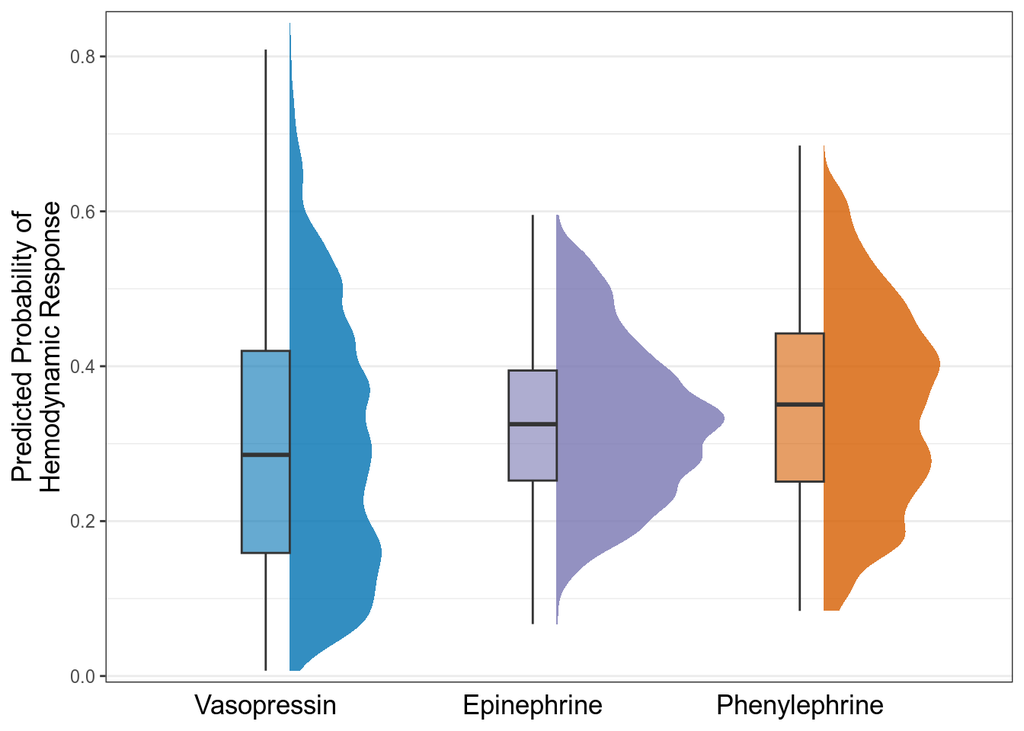

```r
pred_prob_long <-
  fl_aug |>
  select(
    avp_pred_response_prob,
    epi_pred_response_prob,
    pe_pred_response_prob
    ) |>
  pivot_longer(
    everything(),
    names_to = "vasopressor",
    values_to = "pred_prob"
    ) |>
  mutate(
    vasopressor = factor(
      vasopressor,
      levels = c("avp_pred_response_prob", "epi_pred_response_prob",
                 "pe_pred_response_prob"
                 ),
      labels = c("Vasopressin", "Epinephrine", "Phenylephrine")
      )
    )

(resp_pred_raincloud <- ggplot(
  pred_prob_long,
  aes(x = vasopressor, y = pred_prob, fill = vasopressor)
  ) +
  stat_halfeye(
    width = 0.7, justification = -0.14, point_interval = NULL, alpha = 0.8,
    adjust = 0.6 # Decrease smoothing in density plot (default = 1)
    ) +
  geom_boxplot(width = 0.18, alpha = 0.6, outlier.shape = NA) +
  scale_fill_manual(values = c(
      "Vasopressin" = "#0072B2",
      "Epinephrine" = "#7876B1FF",
      "Phenylephrine" = "#D55E00"
      )) +
  guides(fill = "none") +
  scale_y_continuous(
    limits = c(0, 0.85),
    breaks = seq(0, 0.8, by = 0.2),
    expand = expansion(mult = c(0.01, 0.01))
    ) +
  labs(
    x = NULL,
    y = "Predicted Probability of\nHemodynamic Response"
    ) +
  theme_bw() +
  theme(
    text = element_text(family = "Arial"),
    axis.text.x = element_text(size = 13, color = "black",
                               margin = margin(t = 6)
                               ),
    axis.title.y = element_text(size = 13),
    axis.ticks.x = element_blank(),
    panel.grid.major.x = element_blank(),
    panel.grid.minor.x = element_blank()
    )
  )
```

```r
rm(pred_prob_long)
```

Save raincloud plot

```r
ggsave(
  "resp_pred_raincloud.tiff",
  plot = resp_pred_raincloud,
  device = ragg::agg_tiff,
  width = 7,
  height = 4,
  units = "in",
  dpi = 600,
  compression = "lzw"
)
```

## 14.4 Decision Model Recommendation

Determine decision model-recommended adjunctive vasopressor medication (`rec_first_adj`), defined as the first adjunctive vasopressor with the highest (maximum) predicted probability of response.

```r
fl_aug <- fl_aug |>
  rowwise() |>
  mutate(
    best_prob = max(avp_pred_response_prob, epi_pred_response_prob,
        pe_pred_response_prob
        ),
    rec_first_adj = factor(case_when(
      best_prob == avp_pred_response_prob ~ "vasopressin",
      best_prob == epi_pred_response_prob ~ "epinephrine",
      best_prob == pe_pred_response_prob ~ "phenylephrine",
      .default = "Error"
      ),
      levels = c("vasopressin", "epinephrine", "phenylephrine")
      )
    ) |>
  ungroup()
```

Show a table of the decision model-recommended adjunctive vasopressor medication (`rec_first_adj`).

```r
fl_aug |> tabyl(rec_first_adj) |>
  adorn_totals() |>
  adorn_pct_formatting() |>
  rename(Recommended = rec_first_adj) |>
  kable(align = c('lcc'),
        caption = "Decision Model-Recommended Adjunctive Vasopressor (Validation Cohort)"
        ) |>
  kable_paper(full_width = FALSE)
```

Decision Model-Recommended Adjunctive Vasopressor (Validation Cohort)

| Recommended | n | percent |
| --- | --- | --- |
| vasopressin | 323 | 28.6% |
| epinephrine | 323 | 28.6% |
| phenylephrine | 482 | 42.7% |
| Total | 1128 | 100.0% |

The most commonly recommended first adjunctive vasopressor medication in the validation (Florida) dataset was phenylephrine.

Show a table of recommended first adjunctive vasopressor medication vs. the first adjunctive vasopressor medication received during the patient’s observed course of care.

```r
fl_aug |> tabyl(first_adj, rec_first_adj) |>
  adorn_totals(where = c("row", "col")) |>
  adorn_percentages(denominator = "col")|>
  adorn_pct_formatting() |>
  adorn_ns(position = "front") |>
  adorn_title(placement = "combined") |>
  rename("Received (row)/Recommended (col)" = `first_adj/rec_first_adj`) |>
  kable(align = c('lcc'),
        caption = "Decision Model-Recommended Adjunctive Vasopressor vs. Received Adjunct"
        ) |>
  kable_paper(full_width = FALSE)
```

Decision Model-Recommended Adjunctive Vasopressor vs. Received Adjunct

| Received (row)/Recommended (col) | vasopressin | epinephrine | phenylephrine | Total |
| --- | --- | --- | --- | --- |
| vasopressin | 299 (92.6%) | 281 (87.0%) | 396 (82.2%) | 976 (86.5%) |
| epinephrine | 17 (5.3%) | 26 (8.0%) | 52 (10.8%) | 95 (8.4%) |
| phenylephrine | 7 (2.2%) | 16 (5.0%) | 34 (7.1%) | 57 (5.1%) |
| Total | 323 (100.0%) | 323 (100.0%) | 482 (100.0%) | 1,128 (100.0%) |

An adjunctive vasopressor other than the model-recommended vasopressor (discordance) was observed for 24 of 323 (7.4%) patients recommended to receive vasopressin, 297 of 323 (92%) patients recommended to receive epinephrine, and 448 of 482 (92.9%) patients recommended to receive phenylephrine.

Inversely, of the 976 patients who received vasopressin, 299 (30.6%) patients received the model recommendation-concordant adjunctive vasopressor (vasopressin) and 69.4% received a discordant adjunctive vasopressor. Of the 95 patients who received epinephrine, 26 (27.4%) patients received the model recommendation-concordant adjunctive vasopressor (epinephrine) and 69 patients (72.6%) received a discordant adjunctive vasopressor. Of the 57 patients who received phenylephrine, 34 (59.6%) patients received the model recommendation-concordant adjunctive vasopressor (phenylephrine) and 23 (40.4%) patients received a discordant adjunctive vasopressor.

Plot the concordance between model-recommended first adjunctive vasopressor and the treatment (adjunctive vasopressor) received using an alluvial plot.

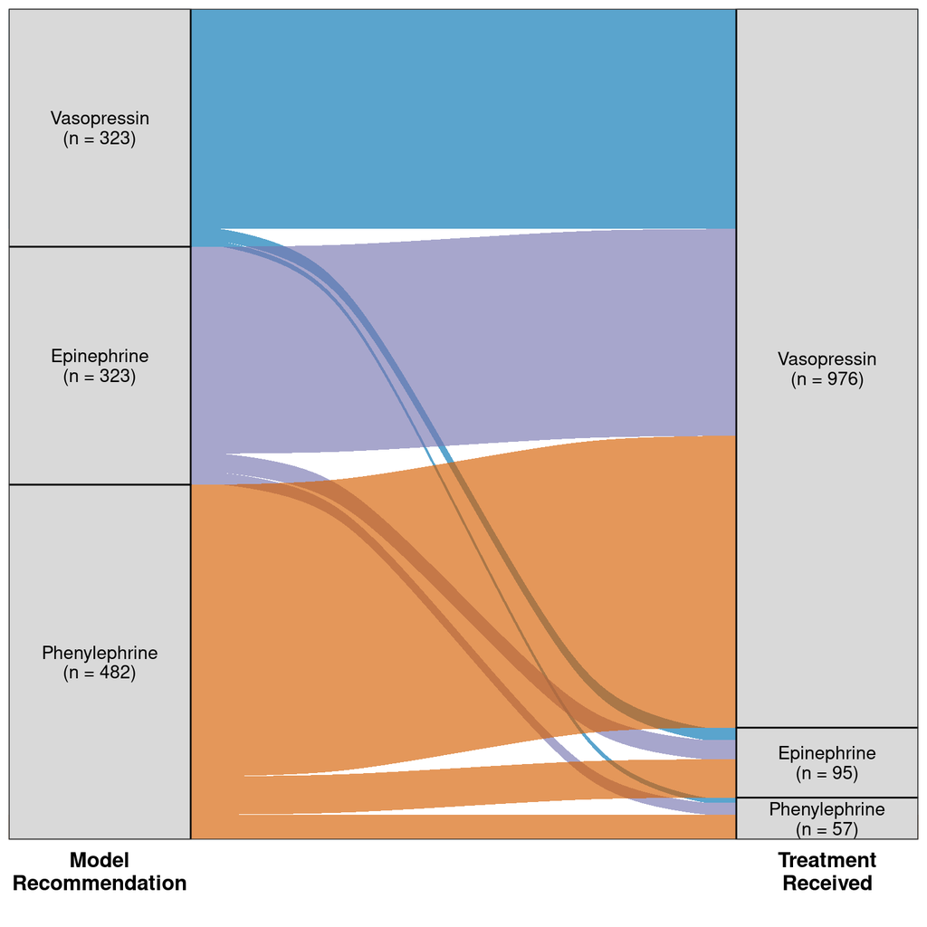

```r
# Data for alluvial plot
alluvial_dat <-
  fl_aug |>
  count(rec_first_adj, first_adj) |>
  mutate(
    rec_first_adj = fct_recode(
      rec_first_adj,
      "Vasopressin" = "vasopressin",
      "Epinephrine" = "epinephrine",
      "Phenylephrine" = "phenylephrine"
      ),
    first_adj = fct_recode(
      first_adj,
      "Vasopressin" = "vasopressin",
      "Epinephrine" = "epinephrine",
      "Phenylephrine" = "phenylephrine"
      )
    )

# Counts for left and right strata
rec_counts <-
  fl_aug |>
  count(rec_first_adj) |>
  mutate(
    stratum = fct_recode(
      rec_first_adj,
      "Vasopressin" = "vasopressin",
      "Epinephrine" = "epinephrine",
      "Phenylephrine" = "phenylephrine"
      ),
    label = paste0(stratum, "\n(n = ", comma(n), ")")
    ) |>
  select(stratum, label)

first_counts <-
  fl_aug |>
  count(first_adj) |>
  mutate(
    stratum = fct_recode(
      first_adj,
      "Vasopressin" = "vasopressin",
      "Epinephrine" = "epinephrine",
      "Phenylephrine" = "phenylephrine"
      ),
    label = paste0(stratum, "\n(n = ", comma(n), ")")
    ) |>
  select(stratum, label)

# Base plot
p <-
  ggplot(
    alluvial_dat,
    aes(
      axis1 = rec_first_adj,
      axis2 = first_adj,
      y = n
      )
    ) +
  geom_alluvium(aes(fill = rec_first_adj), alpha = 0.65) +
  geom_stratum(width = 0.25, fill = "grey85", color = "black")

# Extract stratum positions
strata_pos <-
  ggplot_build(p)$data[[2]] |>
  distinct(x, stratum, ymin, ymax) |>
  mutate(y = (ymin + ymax) / 2)

# Labels for recommendation axis (left)
left_labels <-
  strata_pos |>
  filter(x == 1) |>
  left_join(rec_counts, by = "stratum")

# Labels for treatment axis (right)
right_labels <-
  strata_pos |>
  filter(x == 2) |>
  left_join(first_counts, by = "stratum")

# Final plot
(concord_alluv <- p +
    geom_text(data = left_labels, aes(x = x, y = y, label = label),
      inherit.aes = FALSE, size = 4, lineheight = 0.9
      ) +
    geom_text(data = right_labels, aes(x = x, y = y, label = label),
      inherit.aes = FALSE, size = 4, lineheight = 0.9
      ) +
    scale_fill_manual(values = c(
      "Vasopressin" = "#0072B2",
      "Epinephrine" = "#7876B1FF",
      "Phenylephrine" = "#D55E00"
      )) +
    scale_x_discrete(
      limits = c("Model\nRecommendation", "Treatment\nReceived"),
      expand = c(0.06, 0.06)
      ) +
    scale_y_continuous(
      expand = expansion(mult = c(0, 0)), breaks = NULL, labels = NULL) +
    guides(fill = "none") +
    labs(x = NULL, y = NULL) +
    theme(
      axis.text.x = element_text(size = 13, color = "black",
                                 face = "bold", margin = margin(t = 8)
                                 ),
      axis.text.y = element_blank(),
      axis.ticks.x = element_blank(),
      axis.ticks.y = element_blank(),
      panel.grid = element_blank(),
      plot.margin = margin(t = 5.5, r = 5.5, b = 20, l = 5.5)
      )
  )
```

```r
rm(rec_counts, first_counts, alluvial_dat, strata_pos,
   left_labels, right_labels, p
   )
```

Save alluvial plot

```r
ggsave(
  "concord_alluv.tiff",
  plot = concord_alluv,
  device = ragg::agg_tiff,
  width = 9,
  height = 9,
  units = "in",
  dpi = 600,
  compression = "lzw"
)
```

## 14.5 Discordance analysis

### 14.5.1 Primary analysis

Perform a discordance analysis and sensitivity analyses as described in [Dalton 2016](https://journals.sagepub.com/doi/10.1177/0272989X15578835).

Determine concordance between the decision model-recommended therapy (`rec_first_adj`) and the adjunctive vasopressor the patient received during the normal course of care (`first_adj`).

```r
fl_aug <- fl_aug |>
  mutate(first_adj_concordance =
           factor(if_else(first_adj == rec_first_adj,
                          "concordant",
                          "discordant"
                          ),
                  levels = c("discordant", "concordant")
                  )
         )

fl_aug |> tabyl(first_adj_concordance) |>
  adorn_totals() |>
  adorn_pct_formatting() |>
  rename(Concordance = first_adj_concordance) |>
  kable(align = c('lcc'),
        caption = "Concordance of Decision Model Recommended and Observed Adjunct"
        ) |>
  kable_paper(full_width = FALSE)
```

Concordance of Decision Model Recommended and Observed Adjunct

| Concordance | n | percent |
| --- | --- | --- |
| discordant | 769 | 68.2% |
| concordant | 359 | 31.8% |
| Total | 1128 | 100.0% |

Only 31.8% of patients received the decision model-recommended adjunctive vasopressor (the medication with the highest predicted probability of response) during the standard course of care.

Show the observed incidence of response among concordant and discordant cases.

```r
fl_aug |> tabyl(response, first_adj_concordance) |>
  adorn_totals(where = c("row", "col")) |>
  adorn_percentages(denominator = "col") |>
  adorn_pct_formatting() |>
  adorn_ns(position = "front") |>
  adorn_title(placement = "combined") |>
  rename("Response (row)/Concordance (col)" = `response/first_adj_concordance`) |>
  kable(align = c('lcc'),
        caption = "Observed Response Incidence by Decision Model-Recommendation Concordance"
        ) |>
  kable_paper(full_width = FALSE)
```

Observed Response Incidence by Decision Model-Recommendation Concordance

| Response (row)/Concordance (col) | discordant | concordant | Total |
| --- | --- | --- | --- |
| Response | 178 (23.1%) | 137 (38.2%) | 315 (27.9%) |
| No Response | 591 (76.9%) | 222 (61.8%) | 813 (72.1%) |
| Total | 769 (100.0%) | 359 (100.0%) | 1,128 (100.0%) |

Show data similarly in a contingency table (with interpretation below).

```r
Epi::twoby2(fl_aug$first_adj_concordance, fl_aug$response)
```

```
2 by 2 table analysis:
------------------------------------------------------
Outcome   : Response
Comparing : discordant vs. concordant

           Response No Response    P(Response) 95% conf. interval
discordant      178         591         0.2315    0.2030   0.2626
concordant      137         222         0.3816    0.3328   0.4330

                                    95% conf. interval
             Relative Risk:  0.6066    0.5045   0.7292
         Sample Odds Ratio:  0.4881    0.3722   0.6399
Conditional MLE Odds Ratio:  0.4884    0.3690   0.6465
    Probability difference: -0.1501   -0.2088  -0.0923

             Exact P-value: 0.0000
        Asymptotic P-value: 0.0000
------------------------------------------------------
```

Adjunctive vasopressor response was observed in 178 of 769 (23.1%) patients receiving discordant vasopressor therapy and 137 of 359 (38.2%) patients receiving concordant vasopressor therapy (difference in percentages 15.0% [95% CI; 9.2%, 20.9%]).

Create a numeric response outcome variable, then determine the association of concordance with adjunctive vasopressor response using logistic regression.

```r
fl_aug <- fl_aug |>
  mutate(response_bin = as.integer(response == "Response"))

discord_analysis <- glm(response_bin ~ first_adj_concordance,
                        data = fl_aug, family = binomial(link = "logit")
                        )

tidy(discord_analysis, exponentiate = TRUE, conf.int = TRUE) |>
  filter(term != "(Intercept)") |>
  mutate(term = sub("^first_adj_concordance", "", term)) |>
  select("Term" = term, "OR" = estimate,
         "95% CI, Lower" = conf.low, "95% CI, Upper" = conf.high) |>
  kable(align = c('lcccc'),
        caption = "Logistic Regression for Adjunctive Vasopressor Response by Decision Model Concordance",
        digits = 2
        ) |>
  kable_paper(full_width = FALSE)
```

Logistic Regression for Adjunctive Vasopressor Response by Decision Model Concordance

| Term | OR | 95% CI, Lower | 95% CI, Upper |
| --- | --- | --- | --- |
| concordant | 2.05 | 1.56 | 2.69 |

Decision model-concordant adjunctive vasopressor therapy was associated with 2-fold higher odds of response (OR 2.05 [95% CI; 1.56, 2.69]).

### 14.5.2 Subgroup: Concordance by Recommended Vasopressor

To gain further insight into the nature of discordance, show concordance by decision model-recommended first adjunctive vasopressor.

```r
fl_aug |>
  mutate(first_adj_concordance =
           fct_relevel(first_adj_concordance, "concordant")
         ) |>
  tabyl(first_adj_concordance, rec_first_adj) |>
  adorn_totals(where = c("row", "col")) |>
  adorn_percentages(denominator = "col")|>
  adorn_pct_formatting() |>
  adorn_ns(position = "front") |>
  adorn_title(placement = "combined") |>
  rename("Concordance/Recommended" = `first_adj_concordance/rec_first_adj`) |>
  kable(align = c('lcc'),
        caption = "Concordance by Decision Model-Recommended First Adjunct"
        ) |>
  kable_paper(full_width = FALSE)
```

Concordance by Decision Model-Recommended First Adjunct

| Concordance/Recommended | vasopressin | epinephrine | phenylephrine | Total |
| --- | --- | --- | --- | --- |
| concordant | 299 (92.6%) | 26 (8.0%) | 34 (7.1%) | 359 (31.8%) |
| discordant | 24 (7.4%) | 297 (92.0%) | 448 (92.9%) | 769 (68.2%) |
| Total | 323 (100.0%) | 323 (100.0%) | 482 (100.0%) | 1,128 (100.0%) |

Next, assess whether the association between concordance and response varies according to the decision model-recommended first adjunct by fitting a logistic regression model with an interaction term between recommended first adjunct and concordance. This addresses the question: “Within each recommended first adjunct, what is the odds ratio for response comparing concordant versus discordant therapy?”. Then, formally test for effect modification/interaction (“Does the effect of concordance on response differ across recommended first adjunct groups?”).

```r
fl_aug <- fl_aug |>
  mutate(first_adj_conc_relevl =
           fct_relevel(first_adj_concordance, "concordant")
         )

fit <- glm(response_bin ~ rec_first_adj * first_adj_conc_relevl,
           family = binomial(link = "logit"), data = fl_aug
           )

(emm <- emmeans(fit,
                pairwise ~ first_adj_conc_relevl | rec_first_adj,
                type = "response"
                ))
```

```
$emmeans
rec_first_adj = vasopressin:
 first_adj_conc_relevl  prob     SE  df asymp.LCL asymp.UCL
 concordant            0.398 0.0283 Inf    0.3440     0.455
 discordant            0.417 0.1010 Inf    0.2409     0.617

rec_first_adj = epinephrine:
 first_adj_conc_relevl  prob     SE  df asymp.LCL asymp.UCL
 concordant            0.192 0.0773 Inf    0.0824     0.387
 discordant            0.256 0.0253 Inf    0.2095     0.309

rec_first_adj = phenylephrine:
 first_adj_conc_relevl  prob     SE  df asymp.LCL asymp.UCL
 concordant            0.382 0.0833 Inf    0.2366     0.553
 discordant            0.205 0.0191 Inf    0.1705     0.245

Confidence level used: 0.95
Intervals are back-transformed from the logit scale

$contrasts
rec_first_adj = vasopressin:
 contrast                odds.ratio    SE  df null z.ratio p.value
 concordant / discordant      0.926 0.399 Inf    1  -0.180  0.8574

rec_first_adj = epinephrine:
 contrast                odds.ratio    SE  df null z.ratio p.value
 concordant / discordant      0.692 0.357 Inf    1  -0.714  0.4754

rec_first_adj = phenylephrine:
 contrast                odds.ratio    SE  df null z.ratio p.value
 concordant / discordant      2.395 0.891 Inf    1   2.350  0.0188

Tests are performed on the log odds ratio scale
```

```r
emmeans(fit, pairwise ~ first_adj_conc_relevl | rec_first_adj,
        type = "response"
        )$contrasts |>
  summary(infer = c(TRUE, TRUE))
```

```
rec_first_adj = vasopressin:
 contrast                odds.ratio    SE  df asymp.LCL asymp.UCL
 concordant / discordant      0.926 0.399 Inf     0.398      2.15
 null z.ratio p.value
    1  -0.180  0.8574

rec_first_adj = epinephrine:
 contrast                odds.ratio    SE  df asymp.LCL asymp.UCL
 concordant / discordant      0.692 0.357 Inf     0.252      1.90
 null z.ratio p.value
    1  -0.714  0.4754

rec_first_adj = phenylephrine:
 contrast                odds.ratio    SE  df asymp.LCL asymp.UCL
 concordant / discordant      2.395 0.891 Inf     1.156      4.96
 null z.ratio p.value
    1   2.350  0.0188

Confidence level used: 0.95
Intervals are back-transformed from the log odds ratio scale
Tests are performed on the log odds ratio scale
```

```r
anova(fit, test = "Chisq")
```

```
Analysis of Deviance Table

Model: binomial, link: logit

Response: response_bin

Terms added sequentially (first to last)

                                    Df Deviance Resid. Df Resid. Dev
NULL                                                 1127     1336.1
rec_first_adj                        2   32.400      1125     1303.7
first_adj_conc_relevl                1    0.865      1124     1302.8
rec_first_adj:first_adj_conc_relevl  2    4.834      1122     1298.0
                                     Pr(>Chi)
NULL
rec_first_adj                       9.215e-08 ***
first_adj_conc_relevl                 0.35233
rec_first_adj:first_adj_conc_relevl   0.08917 .
---
Signif. codes:  0 '***' 0.001 '**' 0.01 '*' 0.05 '.' 0.1 ' ' 1
```

```r
rm(fit)
```

#### 14.5.2.1 Subgroup: Recommended vs. Received

In a corollary analysis, further assess the nature of discordance by evaluating response by the recommended adjunct and the received adjunct - beyond just concordant/discordant therapy receipt and rather the specific agents. This will be accomplished by fitting a model with an interaction term between the first adjunct recommended (`rec_first_adj`) and the received first adjunct (`first_adj`). Then, assess within each recommended adjunct subgroup how the response odds compare with the concordant therapy.

```r
# Fit model to estimate response probabilities (these estimates are the same
# as observed because the model is saturated)
fit <- glm(response_bin ~ rec_first_adj * first_adj,
           family = binomial(link = "logit"), data = fl_aug
           )

# Estimated response percentages
prob_tbl <- as.data.frame(
  summary(emmeans(fit, ~ rec_first_adj * first_adj, type = "response"))
  ) |>
  transmute(
    rec_first_adj = as.character(rec_first_adj),
    first_adj = as.character(first_adj),
    response_ci = sprintf("%.1f (%.1f, %.1f)", 100 * prob, 100 * asymp.LCL,
                          100 * asymp.UCL
                          )
    )

# ORs relative to concordant therapy within each recommendation stratum

or_tbl <- map_dfr(
  c("vasopressin", "epinephrine", "phenylephrine"),
  \(ref_lvl) {

    fl_aug |>
      filter(rec_first_adj == ref_lvl) |>
      mutate(first_adj = relevel(factor(first_adj), ref = ref_lvl)) |>
      glm(response_bin ~ first_adj, family = binomial, data = _) |>
      tidy(exponentiate = TRUE, conf.int = TRUE) |>
      filter(term != "(Intercept)") |>
      transmute(
        rec_first_adj = ref_lvl,
        first_adj = sub("^first_adj", "", term),
        or_ci = sprintf("%.2f (%.2f, %.2f)", estimate, conf.low, conf.high))
    }
  )

# Add concordant rows
or_tbl <- bind_rows(
  tibble(rec_first_adj = c("vasopressin", "epinephrine", "phenylephrine"),
         first_adj = c("vasopressin", "epinephrine", "phenylephrine"),
         or_ci = "1.00 (Reference)"),
  or_tbl
  )

# Final table
discord_analysis_sub2 <- prob_tbl |>
  left_join(or_tbl,
            by = c("rec_first_adj", "first_adj")
            ) |>
  mutate(
    rec_first_adj = factor(rec_first_adj,
                           levels = c("vasopressin", "epinephrine",
                                      "phenylephrine"
                                      ),
                           labels = c("Vasopressin", "Epinephrine",
                                      "Phenylephrine"
                                      )
                           ),
    first_adj = factor(first_adj,
                       levels = c("vasopressin", "epinephrine",
                                  "phenylephrine"
                                  ),
                       labels = c("Vasopressin", "Epinephrine",
                                  "Phenylephrine"
                                  )
                       )
    ) |>
  arrange(rec_first_adj, first_adj) |>
  rename(`Recommended Adjunct` = rec_first_adj,
         `Received Adjunct` = first_adj,
         `Response, % (95% CI)` = response_ci,
         `OR vs Concordant (95% CI)` = or_ci
         )

(discord_analysis_sub2 |>
  kable(align = c('llcc')) |>
  kable_paper(full_width = FALSE))
```

| Recommended Adjunct | Received Adjunct | Response, % (95% CI) | OR vs Concordant (95% CI) |
| --- | --- | --- | --- |
| Vasopressin | Vasopressin | 39.8 (34.4, 45.5) | 1.00 (Reference) |
| Vasopressin | Epinephrine | 41.2 (21.0, 64.8) | 1.06 (0.38, 2.83) |
| Vasopressin | Phenylephrine | 42.9 (14.4, 77.0) | 1.13 (0.22, 5.23) |
| Epinephrine | Vasopressin | 25.6 (20.9, 31.0) | 1.45 (0.57, 4.46) |
| Epinephrine | Epinephrine | 19.2 (8.2, 38.7) | 1.00 (Reference) |
| Epinephrine | Phenylephrine | 25.0 (9.7, 50.8) | 1.40 (0.30, 6.32) |
| Phenylephrine | Vasopressin | 21.0 (17.2, 25.2) | 0.43 (0.21, 0.91) |
| Phenylephrine | Epinephrine | 17.3 (9.3, 30.0) | 0.34 (0.12, 0.91) |
| Phenylephrine | Phenylephrine | 38.2 (23.7, 55.3) | 1.00 (Reference) |

```r
#rm(fit, prob_tbl, or_tbl)
```

First, when the model recommends vasopressin the rate (percentage) of response is relatively similar (~40%) regardless of which adjunct was administered. When the model recommends epinephrine and the patient receives epinephrine (concordant therapy), the response rate appears slightly lower compared with receipt of another adjunct. The most intriguing finding is when the model recommends phenylephrine - when the patient receives phenylephrine (concordant therapy) response appears substantially higher compared with receipt of another agent.

When compared to concordant therapy, there was no convincing evidence that following the decision model-recommended therapy improved response when vasopressin or epinephrine was recommended (discordant confidence intervals are relatively wide and include 1). However, among patients in whom phenylephrine was recommended, receipt of discordant therapy with vasopressin (OR 0.43, 95% CI 0.21-0.91) or epinephrine (OR 0.34, 95% CI 0.12-0.91) was associated with lower odds of response compared with receipt of phenylephrine.

Export to Word

```r
discord_analysis_sub2 |>
flextable() |>
  autofit() |>
  set_table_properties(layout = "autofit") |>
  font(fontname = "Arial", part = "all") |>
  fontsize(size = 10, part = "all") |>
  line_spacing(space = 1, part = "all") |>
  padding(padding.top = 0, padding.bottom = 0, part = "all") |>
  save_as_docx(
    path = "resp_rec_vs_received.docx",
    pr_section = prop_section(
      page_size = page_size(orient = "portrait", width = 8.5, height = 11),
      page_margins = page_mar(top = 0.5, bottom = 0.5, left = 0.5, right = 0.5)
      )
    )
```

### 14.5.3 Subgroup: Concordance Effect by Decision Model Recommendation Strength

#### 14.5.3.1 Model Probability Difference by Predicted Response

In this analysis assess if the association of concordance with response differs when the model is more certain about the recommended first adjunctive vasopressor. To address this question create a plot with the difference between the adjunct with the highest predicted probability for response and the adjunct with the second-highest predicted probability (`margin`) on the y-axis and the predicted probability for the highest adjunct (`best_prob`) on the x-axis. Create bins (strata) for these two variables where the odds ratio for response will be calculated and plotted in a grid.

First, calculate the `margin` as the difference between the vasopressor with the highest predicted probability of response and the vasopressor with the second-highest predicted probability of response.

```r
fl_aug <-
  fl_aug |>
  rowwise() |>
  mutate(
    best_prob = max(avp_pred_response_prob, epi_pred_response_prob,
                    pe_pred_response_prob
                    ),
    second_prob = sort(
      c(avp_pred_response_prob, epi_pred_response_prob, pe_pred_response_prob),
      decreasing = TRUE
      )[2],
    margin = best_prob - second_prob
    ) |>
  ungroup()
```

Then, show scatter plot of `margin` by `best_prob` with a LOESS smooth for the relationship.

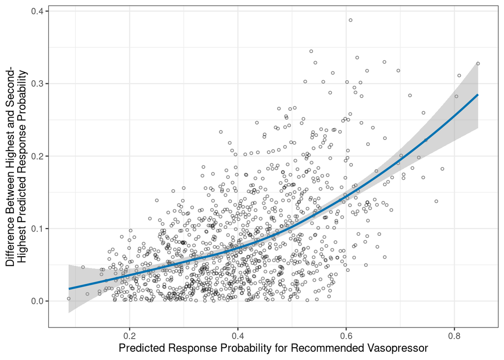

```r
ggplot(fl_aug, aes(y = margin, x = best_prob)) +
  geom_point(alpha = 0.5, size = 1, shape = 1, color = "black") +
  geom_smooth(method = loess, formula = y ~ x, color = "#0072B2") +
  labs(
    x = "Predicted Response Probability for Recommended Vasopressor",
    y = "Difference Between Highest and Second-\nHighest Predicted Response Probability"
    )
```

There appears to be a positive, non-linear relationship between `margin` and `best_prob`.

Save plot.

```r
ggsave(
  "margin_by_best_pred.tiff",
  device = ragg::agg_tiff,
  width = 6,
  height = 4,
  units = "in",
  dpi = 600,
  compression = "lzw"
)
```

Create the bins (strata) for `margin` (by intervals of 0.05) and `best_prob` (by intervals of 0.1).

```r
fl_aug <- fl_aug |>
  mutate(
    margin_strata = cut(margin,
                     breaks = c(0, 0.05, 0.10, 0.15, 0.20, Inf),
                     include.lowest = TRUE,
                     right = FALSE,
                     labels = c("<0.05", "0.05-0.10", "0.10-0.15",
                                "0.15-0.20", "≥0.20"
                                )
                     ),
    prob_bin = cut(best_prob,
                   breaks = c(0, 0.20, 0.30, 0.40, 0.50, 0.60, Inf),
                   include.lowest = TRUE,
                   right = FALSE,
                   labels = c("<0.20", "0.20-0.30", "0.30-0.40",
                              "0.40-0.50", "0.50-0.60", "≥0.60"
                              )
                   )
    )
```

Next, examine counts of concordance by bin to ensure there are adequate data for estimating ORs.

```r
fl_aug |>
  count(prob_bin, margin_strata, first_adj_concordance)
```

```
# A tibble: 50 × 4
   prob_bin  margin_strata first_adj_concordance     n
   <fct>     <fct>         <fct>                 <int>
 1 <0.20     <0.05         discordant               37
 2 <0.20     <0.05         concordant                9
 3 <0.20     0.05-0.10     discordant               10
 4 <0.20     0.05-0.10     concordant                1
 5 0.20-0.30 <0.05         discordant               93
 6 0.20-0.30 <0.05         concordant               22
 7 0.20-0.30 0.05-0.10     discordant               58
 8 0.20-0.30 0.05-0.10     concordant               11
 9 0.20-0.30 0.10-0.15     discordant               13
10 0.20-0.30 0.10-0.15     concordant                2
# ℹ 40 more rows
```

There are some cells with sparse data (as expected), but the counts look reasonable enough to proceed with these bins.

Check counts for response by concordant and discordant observations by cell to check if data will be stable for logistic regression.

```r
fl_aug |>
  count(prob_bin, margin_strata, first_adj_concordance, response)
```

```
# A tibble: 94 × 5
   prob_bin  margin_strata first_adj_concordance response        n
   <fct>     <fct>         <fct>                 <fct>       <int>
 1 <0.20     <0.05         discordant            Response        3
 2 <0.20     <0.05         discordant            No Response    34
 3 <0.20     <0.05         concordant            Response        2
 4 <0.20     <0.05         concordant            No Response     7
 5 <0.20     0.05-0.10     discordant            Response        2
 6 <0.20     0.05-0.10     discordant            No Response     8
 7 <0.20     0.05-0.10     concordant            No Response     1
 8 0.20-0.30 <0.05         discordant            Response       20
 9 0.20-0.30 <0.05         discordant            No Response    73
10 0.20-0.30 <0.05         concordant            Response        6
# ℹ 84 more rows
```

Several cells have 0 or few (1-3) responders or nonresponders in a group, therefore estimates with logistic regression may be unstable.

Instead of using logistic regression, use a function to estimate odds ratios within contingency tables. As part of the function apply a correction factor of 0.5 to each cell (this approach is also known as “continuity correction” or “Haldane-Anscombe correction”) due to the sparse data. Then generate the dataset with OR and 95% CI.

```r
# Create function
compute_or <- function(dat) {
  tab <- table(dat$first_adj_concordance, dat$response)

  a <- if_else(
    "concordant" %in% rownames(tab) &
      "Response" %in% colnames(tab),
    tab["concordant", "Response"],
    0
    )

  b <- if_else(
    "concordant" %in% rownames(tab) &
      "No Response" %in% colnames(tab),
    tab["concordant", "No Response"],
    0
    )

  c <- if_else(
    "discordant" %in% rownames(tab) &
      "Response" %in% colnames(tab),
    tab["discordant", "Response"],
    0
    )

  d <- if_else(
    "discordant" %in% rownames(tab) &
      "No Response" %in% colnames(tab),
    tab["discordant", "No Response"],
    0
    )

  a_adj <- a + 0.5
  b_adj <- b + 0.5
  c_adj <- c + 0.5
  d_adj <- d + 0.5

  OR <-
    (a_adj * d_adj) /
    (b_adj * c_adj)

  tibble(
    OR = OR,
    a = a,
    b = b,
    c = c,
    d = d,
    concordant_n = a + b,
    discordant_n = c + d,
    total_n = a + b + c + d
  )
}

# Generate dataset
plot_dat <- fl_aug |>
  group_by(prob_bin, margin_strata) |>
  group_modify(~compute_or(.x)) |>
  ungroup() |>
  mutate(
    se_log_or = sqrt(
      1/(a + 0.5) +
      1/(b + 0.5) +
      1/(c + 0.5) +
      1/(d + 0.5)
      ),
    lower =
      exp(log(OR) - 1.96 * se_log_or),
    upper =
      exp(log(OR) + 1.96 * se_log_or),
    stable = concordant_n >= 5 & discordant_n >= 5,
    fill_value = if_else(stable, log(OR), NA_real_),
    label = if_else(stable,
                    paste0(sprintf("%.2f\n(%0.2f, %0.2f)", OR, lower, upper)),
                    ""
                    )
    )
```

Now generate and save the plot.

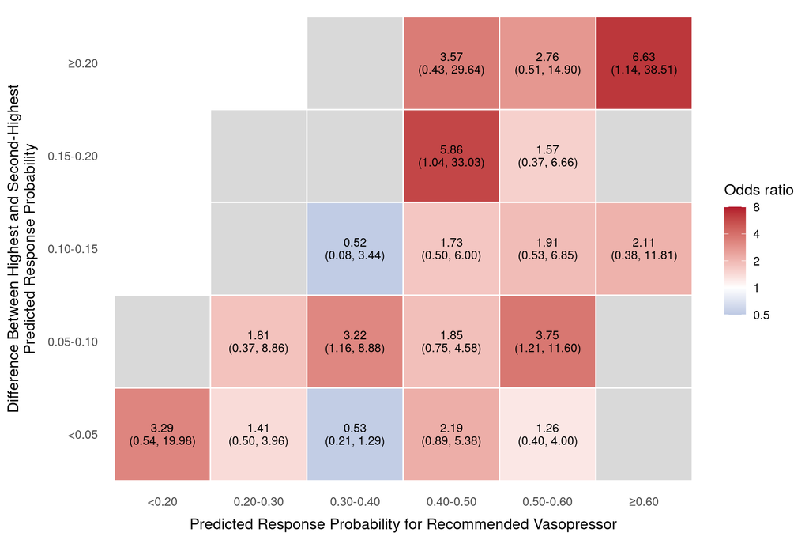

```r
ggplot(plot_dat, aes(x = prob_bin, y = margin_strata, fill = fill_value)) +
  geom_tile(color = "white", linewidth = 0.5) +
  geom_text(
    aes(label = label),
    size = 3.3,
    lineheight = 0.9
    ) +
  scale_fill_gradient2(
    low = "#2166AC",
    mid = "white",
    high = "#B2182B",
    midpoint = 0,
    na.value = "grey85",
    name = "Odds ratio",
    limits = c(log(0.5), log(8)),
    breaks = log(c(0.5, 1, 2, 4, 8)),
    labels = c("0.5", "1", "2", "4", "8")
    ) +
  labs(
    x = "Predicted Response Probability for Recommended Vasopressor",
    y = "Difference Between Highest and Second-Highest\nPredicted Response Probability"
    ) +
  theme_minimal(base_size = 12) +
  theme(
    panel.grid = element_blank(),
    axis.title.x = element_text(margin = margin(t = 8)),
    axis.title.y = element_text(margin = margin(r = 8)),
    legend.title = element_text(margin = margin(b = 8))
    )
```

```r
ggsave(
  "resp_or_by_pred_and_margin.tiff",
  device = ragg::agg_tiff,
  width = 9,
  height = 5,
  units = "in",
  dpi = 600,
  compression = "lzw"
)

rm(plot_dat)
```

Figure caption: Heat map showing the odds ratio for response among patients receiving the decision model-recommended adjunctive vasopressor (concordant therapy) versus a non-recommended adjunctive vasopressor (discordant therapy), stratified by the predicted probability of response to the recommended vasopressor and the margin between the highest and second-highest predicted response probabilities. Values within cells represent the odds ratio and corresponding 95% confidence interval. Cell color corresponds to the odds ratio on a logarithmic scale. Gray cells indicate strata with fewer than five concordant or discordant patients, for which odds ratios were not estimated. White cells indicate strata with no observations.

#### 14.5.3.2 Model Probability Difference Strata

In this subgroup analysis create strata for the absolute difference of response probabilities between the adjunctive vasopressor with the highest predicted probability of response and the vasopressor with the second-highest predicted probability. This difference reflects the decision model probability difference and was created above as `margin_strata`.

Examine counts and concordance frequency (rate) within the probability difference strata.

```r
fl_aug |>
  group_by(margin_strata) |>
  summarize(
    n = n(),
    concordance_pct =
      round_half_up(mean(first_adj_concordance == "concordant")*100, 1),
    .groups = "drop"
  )
```

```
# A tibble: 5 × 3
  margin_strata     n concordance_pct
  <fct>         <int>           <dbl>
1 <0.05           452            26.8
2 0.05-0.10       315            34.3
3 0.10-0.15       183            36.6
4 0.15-0.20       100            41
5 ≥0.20            78            28.2
```

The strata with larger probability differences have substantially fewer observations than the lowest two strata. Therefore, collapse to only three categories and examine data again.

```r
fl_aug <- fl_aug |>
  mutate(margin_strata = cut(margin,
                             breaks = c(0, 0.05, 0.10, Inf),
                             include.lowest = TRUE,
                             right = FALSE,
                             labels = c("<0.05", "0.05-0.10", "≥0.10")
                             )
         )

fl_aug |>
  group_by(margin_strata) |>
  summarize(
    n = n(),
    concordance_pct =
      round_half_up(mean(first_adj_concordance == "concordant")*100, 1),
    .groups = "drop"
  )
```

```
# A tibble: 3 × 3
  margin_strata     n concordance_pct
  <fct>         <int>           <dbl>
1 <0.05           452            26.8
2 0.05-0.10       315            34.3
3 ≥0.10           361            36
```

These adjusted strata cuts result in more homogenous observation counts across strata, therefore continue with this approach.

Estimate the stratum-specific odds ratio for response with logistic regression. Notably, this approach with `group_by()` can produce the overall stratum-specific odds ratio without the need for multiplying odds ratio estimates for the individual components (which would be needed in a simple call to `glm()` with predictor `first_adj_concordance` * `margin_strata`). Further, as in the primary analysis, the reference category for `first_adj_concordance` is “discordant”, therefore the odds ratio represents the comparison of “concordant” vs. “discordant” treatment.

```r
discord_analysis_sens2 <- fl_aug |>
  group_by(margin_strata) |>
  do(
    tidy(
      glm(
        response_bin ~ first_adj_concordance,
        family = binomial,
        data = .
      ),
      exponentiate = TRUE,
      conf.int = TRUE
    )
  ) |>
  filter(term != "(Intercept)") |>
  transmute(
    `Prob Difference` = margin_strata,
    `Response OR` = estimate,
    Lower = conf.low,
    Upper = conf.high
  ) |>
  ungroup() |>
  select(-margin_strata)

discord_analysis_sens2 |>
  kable(align = c('lccc'),
        caption = "Sensitivity: Response Odds Ratio for Concordance by Decision Model Probability Difference Strata",
        digits = 2
        ) |>
  kable_paper(full_width = FALSE)
```

Sensitivity: Response Odds Ratio for Concordance by Decision Model Probability Difference Strata

| Prob Difference | Response OR | Lower | Upper |
| --- | --- | --- | --- |
| <0.05 | 1.30 | 0.82 | 2.05 |
| 0.05-0.10 | 3.00 | 1.80 | 5.03 |
| ≥0.10 | 2.43 | 1.52 | 3.89 |

There appears to be some evidence for greater odds ratios for response with concordant adjunctive vasopressor therapy with higher decision model probability difference strata. There is no evidence concordance within the lowest stratum (where there is little separation in predicted probability of response between the first- and second-highest vasopressor) is associated with response, but concordance within higher probability difference strata is associated with higher odds for response.

Fit a logistic regression model with an interaction term between concordance and decision model probability difference strata and a model fit with main effects for these two variables alone. Then, compare the two models with AIC and ANOVA, the latter of which will provide an overall (global) p-value for interaction (effect modification) by decision probability difference strata.

```r
fit_int <- glm(
  response_bin ~ first_adj_concordance * factor(margin_strata),
  family = binomial,
  data = fl_aug
  )

fit_no_int <- glm(
  response_bin ~ first_adj_concordance + factor(margin_strata),
  family = binomial,
  data = fl_aug
  )

AIC(fit_no_int, fit_int)
```

```
           df      AIC
fit_no_int  4 1317.389
fit_int     6 1314.877
```

```r
anova(fit_no_int, fit_int, test = "LRT")
```

```
Analysis of Deviance Table

Model 1: response_bin ~ first_adj_concordance + factor(margin_strata)
Model 2: response_bin ~ first_adj_concordance * factor(margin_strata)
  Resid. Df Resid. Dev Df Deviance Pr(>Chi)
1      1124     1309.4
2      1122     1302.9  2   6.5117  0.03855 *
---
Signif. codes:  0 '***' 0.001 '**' 0.01 '*' 0.05 '.' 0.1 ' ' 1
```

```r
rm(fit_int, fit_no_int)
```

There is evidence for an interaction by decision model probability difference strata (that the association between concordance and response differs across decision model probability difference strata) with a lower AIC value and likelihood ratio test p = 0.04.

#### 14.5.3.3 Decision Model Odds Ratio Strata

In this subgroup analysis create strata (quartiles) for the relative comparison of response probabilities between the adjunctive vasopressor with the highest predicted probability of response and the vasopressor with the second-highest predicted probability, expressed as a decision model odds ratio.

First, calculate the patient-specific decision model odds ratio (`dm_or_best_vs_second`) as response to the adjunctive vasopressor with the highest predicted probability of response (`best_prob`) versus the second-best option (`second_prob`).

```r
fl_aug <- fl_aug |>
  mutate(
    dm_or_best_vs_second =
      (best_prob / (1 - best_prob)) /
      (second_prob / (1 - second_prob))
  )
```

Then, stratify the decision model odds ratio into quartiles (`dm_or_quartile`).

```r
fl_aug <- fl_aug |>
  mutate(dm_or_quartile = ntile(dm_or_best_vs_second, 4))
```

Show the decision model odds ratio cutpoints defining the quartiles.

```r
round_half_up(
  quantile(
    fl_aug$dm_or_best_vs_second,
    probs = seq(0, 1, by = 0.25)
    ),
  2)
```

```
  0%  25%  50%  75% 100%
1.00 1.15 1.36 1.72 5.48
```

Quartile cutpoints were 1.15, 1.36, and 1.72, therefore quartiles are represented by decision model odds ratios as follows: Q1 (1.00-1.15), Q2 (>1.15-1.36), Q3 (>1.36-1.72), and Q4 (>1.72-5.48).

Methods wording: Patient-specific decision-model odds ratios were calculated as the predicted odds of response for the highest-ranked adjunctive vasopressor divided by the predicted odds of response for the second-highest-ranked adjunctive vasopressor. Patients were then stratified into quartiles of the decision-model odds ratio (Q1: 1.00-1.15, Q2: >1.15-1.36, Q3: >1.36-1.72, Q4: >1.72-5.48).

Potential results wording (but this has a lot of overlap with the wording above for the methods): The decision-model odds ratio was generally modest, with quartile boundaries at 1.15, 1.36, and 1.72. Thus, patients in the lowest quartile had little separation between the top two treatment recommendations (decision model odds ratio 1.00-1.15), whereas those in the highest quartile had substantially greater separation (decision model odds ratio >1.72) and stronger model preference for the recommended adjunctive vasopressor.”

Next, show the connection between the decision model odds ratio quartiles (a relative approach) and the absolute value approach for the difference in predicted probability <0.05 (the zone of practical equivalence explored above).

```r
fl_aug |>
  group_by(dm_or_quartile) |>
  summarize(
    pct_margin_lt_005 = round_half_up(
      mean(margin < 0.05)*100,
      1)
  )
```

```
# A tibble: 4 × 2
  dm_or_quartile pct_margin_lt_005
           <int>             <dbl>
1              1             100
2              2              56.4
3              3               3.5
4              4               0.4
```

There is substantial alignment between the absolute and relative approaches. All patients in the lowest quartile of the decision-model odds ratio had an absolute probability difference of less than 0.05, whereas only 3.5% and 0.4% of patients in the third and fourth quartiles, respectively, fell below this threshold.

Show the median (IQR) decision model odds ratio and range by quartile.

```r
fl_aug |>
  group_by(dm_or_quartile) |>
  summarize(
    n = n(),
    `Decision-model OR` =
      sprintf(
        "%.2f (%.2f, %.2f)",
        median(dm_or_best_vs_second),
        quantile(dm_or_best_vs_second, 0.25),
        quantile(dm_or_best_vs_second, 0.75)
      ),
    Range =
      sprintf(
        "%.2f to %.2f",
        min(dm_or_best_vs_second),
        max(dm_or_best_vs_second)
      )
  ) |>
  rename(quartile = dm_or_quartile)
```

```
# A tibble: 4 × 4
  quartile     n `Decision-model OR` Range
     <int> <int> <chr>               <chr>
1        1   282 1.07 (1.04, 1.11)   1.00 to 1.15
2        2   282 1.24 (1.20, 1.29)   1.15 to 1.36
3        3   282 1.51 (1.43, 1.62)   1.36 to 1.72
4        4   282 2.07 (1.85, 2.50)   1.73 to 5.48
```

The median (IQR) decision-model odds ratio increased across quartiles from 1.07 (1.04, 1.11) in quartile 1 to 2.07 (1.85, 2.50) in Q4, indicating progressively greater separation between the highest- and second-ranked treatment options.

Examine concordance frequency (rate) within the quartiles.

```r
fl_aug |>
  group_by(dm_or_quartile) |>
  summarize(
    n = n(),
    concordance_freq =
      mean(first_adj_concordance == "concordant"),
    .groups = "drop"
  )
```

```
# A tibble: 4 × 3
  dm_or_quartile     n concordance_freq
           <int> <int>            <dbl>
1              1   282            0.280
2              2   282            0.312
3              3   282            0.351
4              4   282            0.330
```

Examine response frequency (rate) within the quartiles.

```r
fl_aug |>
  group_by(dm_or_quartile, first_adj_concordance) |>
  summarize(
    n = n(),
    response_prop =
      mean(response_bin),
    .groups = "drop"
  )
```

```
# A tibble: 8 × 4
  dm_or_quartile first_adj_concordance     n response_prop
           <int> <fct>                 <int>         <dbl>
1              1 discordant              203         0.300
2              1 concordant               79         0.316
3              2 discordant              194         0.237
4              2 concordant               88         0.420
5              3 discordant              183         0.169
6              3 concordant               99         0.343
7              4 discordant              189         0.212
8              4 concordant               93         0.441
```

Estimate the stratum-specific (quartile-specific) odds ratio for response with logistic regression. Notably, this approach with `group_by()` can produce the overall stratum-specific odds ratio without the need for multiplying odds ratio estimates for the individual components (which would be needed in a simple call to `glm()` with predictor `first_adj_concordance` * `dm_or_quartile`). Further, as in the primary analysis, the reference category for `first_adj_concordance` is “discordant”, therefore the odds ratio represents the comparison of “concordant” vs. “discordant” treatment.

```r
discord_analysis_sens3 <- fl_aug |>
  group_by(dm_or_quartile) |>
  do(
    tidy(
      glm(
        response_bin ~ first_adj_concordance,
        family = binomial,
        data = .
      ),
      exponentiate = TRUE,
      conf.int = TRUE
    )
  ) |>
  filter(term != "(Intercept)") |>
  transmute(
    Quartile = dm_or_quartile,
    `Response OR` = estimate,
    Lower = conf.low,
    Upper = conf.high
  ) |>
  ungroup() |>
  select(-dm_or_quartile)

discord_analysis_sens3 |>
  kable(align = c('lccc'),
        caption = "Sensitivity: Response Odds Ratio for Concordance by Decision Model Odds Ratio Stratum",
        digits = 2
        ) |>
  kable_paper(full_width = FALSE)
```

Sensitivity: Response Odds Ratio for Concordance by Decision Model Odds Ratio Stratum

| Quartile | Response OR | Lower | Upper |
| --- | --- | --- | --- |
| 1 | 1.08 | 0.61 | 1.88 |
| 2 | 2.33 | 1.36 | 4.00 |
| 3 | 2.56 | 1.46 | 4.54 |
| 4 | 2.94 | 1.72 | 5.05 |

There appears to be some evidence for greater odds ratios for response with concordant adjunctive vasopressor therapy with higher decision model odds ratio quartiles. There is no evidence concordance within the lowest decision model odds ratio quartile (where there is little separation in predicted probability of response between the first- and second-highest vasopressor) is associated with observed response, but concordance within higher quartiles is associated with higher odds for response. Notably, while the odds ratio point estimates for response with concordance increases with increasing decision model odds ratio quartile, the point estimates and 95% confidence intervals are relatively similar within quartiles 2-4, suggesting a potential threshold effect (there does not appear to be a linear effect).

Fit a logistic regression model with an interaction term between concordance and decision model odds ratio quartile (stratum) and a model fit with main effects for these two variables alone. Then, compare the two models with AIC and ANOVA, the latter of which will provide an overall (global) p-value for interaction (effect modification) by decision model odds ratio.

```r
fit_int <- glm(
  response_bin ~ first_adj_concordance * factor(dm_or_quartile),
  family = binomial,
  data = fl_aug
  )

fit_no_int <- glm(
  response_bin ~ first_adj_concordance + factor(dm_or_quartile),
  family = binomial,
  data = fl_aug
  )

AIC(fit_no_int, fit_int)
```

```
           df      AIC
fit_no_int  5 1313.371
fit_int     8 1311.666
```

```r
anova(fit_no_int, fit_int, test = "LRT")
```

```
Analysis of Deviance Table

Model 1: response_bin ~ first_adj_concordance + factor(dm_or_quartile)
Model 2: response_bin ~ first_adj_concordance * factor(dm_or_quartile)
  Resid. Df Resid. Dev Df Deviance Pr(>Chi)
1      1123     1303.4
2      1120     1295.7  3   7.7048  0.05252 .
---
Signif. codes:  0 '***' 0.001 '**' 0.01 '*' 0.05 '.' 0.1 ' ' 1
```

```r
rm(fit_int, fit_no_int)
```

There is some evidence for an interaction by quartile (that the association between concordance and response differs across decision-model odds ratio quartiles) with a lower AIC value and likelihood ratio test p = 0.053.

### 14.5.4 Sensitivity: Practical Equivalence

Incorporate zones of practical equivalence for the recommended adjunctive vasopressor (compared with the second-best) based on the predicted probabilities of response from the models. Explore possible thresholds for the zone(s) based on the distribution (proportion with `margin` below exploratory thresholds).

```r
fl_aug |>
  summarize(
    pct_lt_001 = round_half_up(mean(margin < 0.01)*100, 1),
    pct_lt_005 = round_half_up(mean(margin < 0.05)*100, 1),
    pct_lt_010 = round_half_up(mean(margin < 0.10)*100, 1),
    pct_lt_015 = round_half_up(mean(margin < 0.15)*100, 1),
    pct_lt_020 = round_half_up(mean(margin < 0.20)*100, 1),
    pct_lt_025 = round_half_up(mean(margin < 0.25)*100, 1)
  )
```

```
# A tibble: 1 × 6
  pct_lt_001 pct_lt_005 pct_lt_010 pct_lt_015 pct_lt_020 pct_lt_025
       <dbl>      <dbl>      <dbl>      <dbl>      <dbl>      <dbl>
1        8.5       40.1         68       84.2       93.1       97.3
```

There were 40% of patients with a difference within 0.05 in the predicted probability (5 percentage points) between the adjunctive vasopressor with the highest and second-highest predicted probability of response. As shown in Section 14.3, the median predicted response probabilities for the adjunctive vasopressors ranged from 0.286 to 0.35, therefore a difference in probabilities of 0.05 is approximately a 15% relative difference.

Visualize `margin` by plotting the empirical cumulative distribution, showing the percentage of data points (y-axis) less than or equal to any given value of `margin` (x-axis). Include vertical lines at the empirical thresholds with the percentage of values below the threshold.

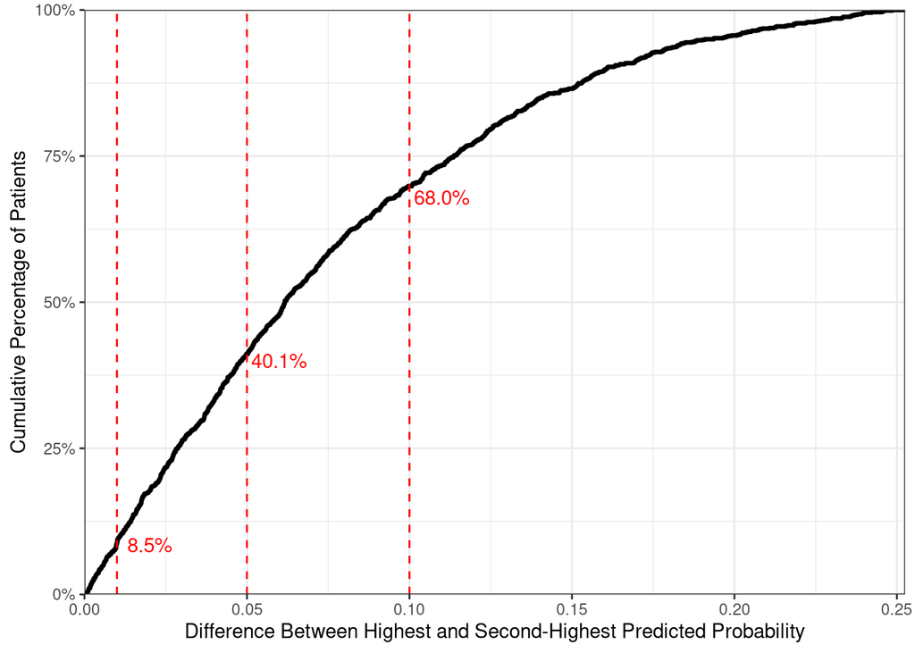

```r
ggplot(fl_aug, aes(x = margin)) +
  stat_ecdf(linewidth = 1.2) +
  geom_vline(xintercept = c(0.01, 0.05, 0.10), linetype = 2, color = "red") +
  annotate("text", x = 0.02, y = 0.085, label = "8.5%", color = "red") +
  annotate("text", x = 0.06, y = 0.40, label = "40.1%", color = "red") +
  annotate("text", x = 0.11, y = 0.68, label = "68.0%", color = "red") +
  scale_y_continuous(labels = percent, expand = c(0, 0)) +
  scale_x_continuous(limits = c(0,0.25), breaks = seq(0, 0.25, by = 0.05),
                     expand = expansion(mult = c(0, 0.01))
                     ) +
  labs(
    x = "Difference Between Highest and Second-Highest Predicted Probability",
    y = "Cumulative Percentage of Patients"
    ) +
  theme_bw()
```

Show the median (IQR) `margin` between highest and second-highest predicted probability by recommended first adjunct.

```r
fl_aug |>
  group_by(rec_first_adj) |>
  summarize(
    median_margin = round_half_up(median(margin),3),
    q1 = round_half_up(quantile(margin, 0.25),3),
    q3 = round_half_up(quantile(margin, 0.75),3)
  )
```

```
# A tibble: 3 × 4
  rec_first_adj median_margin    q1    q3
  <fct>                 <dbl> <dbl> <dbl>
1 vasopressin           0.073 0.035 0.128
2 epinephrine           0.043 0.018 0.072
3 phenylephrine         0.081 0.039 0.144
```

When epinephrine was the recommended adjunctive vasopressor the median (IQR) difference (`margin`) between epinephrine and the second-highest recommended adjunctive vasopressor was smaller (0.043 [0.018, 0.072]) compared with cases when the recommended adjunctive vasopressor was vasopressin (0.073 [0.035, 0.128]) or phenylephrine (0.081 [0.039, 0.144]). This suggests that recommendations were weaker (less strongly in favor versus an alternative) for epinephrine as the preferred adjunctive vasopressor as compared with when the other two adjunctive vasopressors were recommended.

Show a scatterplot panel of the predicted probabilities of response by adjunctive vasopressor, incorporating equivalence bands of +/- 0.05 and +/- 0.1.

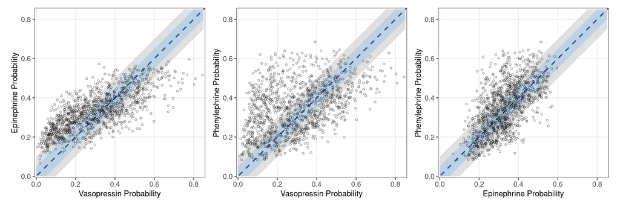

```r
# Common equivalence bands, plotting theme, and limits
eq_band_10 <- tibble(
  x = seq(0, 0.85, by = 0.01),
  ymin = pmax(0, x - 0.10),
  ymax = pmin(0.85, x + 0.10)
)

eq_band_05 <- tibble(
  x = seq(0, 0.85, by = 0.01),
  ymin = pmax(0, x - 0.05),
  ymax = pmin(0.85, x + 0.05)
)

plot_theme <- theme_bw() +
  theme(panel.grid.minor = element_blank(),
        axis.title = element_text(size = 11),
        axis.text = element_text(size = 10)
        )

make_plot <- function(data, xvar, yvar, xlab, ylab) {
  ggplot(data, aes({{ xvar }}, {{ yvar }})) +
    geom_ribbon(data = eq_band_10,
                aes(x = x, ymin = ymin, ymax = ymax),
                inherit.aes = FALSE,
                fill = "grey80",
                alpha = 0.6
                ) +
    geom_ribbon(data = eq_band_05,
                aes(x = x, ymin = ymin, ymax = ymax),
                inherit.aes = FALSE,
                fill = "#A9CCE3",
                alpha = 0.7
                ) +
    geom_abline(slope = 1, intercept = 0,
                color = "navyblue", linetype = 2, linewidth = 0.8, alpha = 0.7
                ) +
    geom_point(alpha = 0.4, size = 1, shape = 1, color = "black") +
    coord_equal() +
    scale_x_continuous(limits = c(0, 0.85), breaks = seq(0, 0.8, 0.2),
                       expand = expansion(mult = c(0.01, 0.01))
                       ) +
    scale_y_continuous(limits = c(0, 0.85), breaks = seq(0, 0.8, 0.2),
                       expand = expansion(mult = c(0.01, 0.01))
                       ) +
    labs(x = xlab, y = ylab) +
    plot_theme
}

p1 <- make_plot(fl_aug,
                avp_pred_response_prob, epi_pred_response_prob,
                "Vasopressin Probability", "Epinephrine Probability"
                )

p2 <- make_plot(fl_aug,
                avp_pred_response_prob, pe_pred_response_prob,
                "Vasopressin Probability", "Phenylephrine Probability"
                )

p3 <- make_plot(fl_aug,
                epi_pred_response_prob, pe_pred_response_prob,
                "Epinephrine Probability", "Phenylephrine Probability"
                )

(scatter_pred_prob_panel <- (p1 | p2 | p3))
```

```r
rm(eq_band_10, eq_band_05, plot_theme, make_plot, p1, p2, p3)
```

In this plot each point represents an individual patient, with predicted probability of response to the vasopressor listed on the axes contrasted. The dashed line represents equal predicted probabilities of response for the two vasopressors being compared in the panel, and the shaded area surrounding the dashed line represents probability ±0.05 (considered a “zone of practical equivalence”). Therefore, points within the shaded area may be considered clinically equivalent predicted probability for response to the two vasopressors. Points above the shaded area indicate the y-axis adjunctive vasopressor has a meaningfully higher response predicted probability, while points below the shaded area indicate the x-axis adjunctive vasopressor has a meaningfully higher response predicted probability.

The figures indicate that while predictions for all three models are positively associated, there is substantial patient-level heterogeneity in predictions that creates individualized treatment recommendations. Agreement was strongest between the vasopressin and epinephrine model, with points clustered near the dashed line of identity. Yet, at low probabilities (<0.3) epinephrine appeared to be favored more commonly. The comparison between vasopressin and phenylephrine showed the largest heterogeneity, with vertical spread across the range of vasopressin probabilities. This indicates the vasopressin and phenylephrine models generated the greatest treatment differentiation - patients with similar predicted response to vasopressin may have markedly different predicted response to phenylephrine. In the epinephrine vs. phenylephrine comparison the spread is more than in the vasopressin vs. epinephrine comparison but less than in the vasopressin vs. phenylephrine comparison (particularly when considering horizontal spread in addition to vertical spread). This indicates the epinephrine and phenylephrine predictions are related but still distinguish clinically meaningful subgroups of patients.

Potential manuscript interpretation: Pairwise comparisons of predicted probabilities of response demonstrated positive associations among the vasopressin, epinephrine, and phenylephrine response models. However, substantial dispersion around the line of equality was observed, particularly for comparisons involving phenylephrine, indicating meaningful patient-level differences in predicted treatment response.

Save the scatter plot

```r
ggsave(
  "scatter_pred_prob_panel.tiff",
  plot = scatter_pred_prob_panel,
  device = ragg::agg_tiff,
  width = 12,
  height = 4,
  units = "in",
  dpi = 600,
  compression = "lzw"
)
```

#### 14.5.4.1 Equivalence as Difference <=0.05

Consider an adjunctive vasopressor a recommended adjunct if the predicted probability for response for that vasopressor is within 0.05 of the adjunctive vasopressor with the highest probability (`best_prob`). Then consider concordance as receipt of a recommended adjunct based on the zone of practical equivalence (difference <=0.05).

```r
fl_aug <-
  fl_aug |>
  rowwise() |>
  mutate(rec_avp_sens = avp_pred_response_prob > (best_prob - 0.05),
         rec_epi_sens = epi_pred_response_prob > (best_prob - 0.05),
         rec_pe_sens  = pe_pred_response_prob  > (best_prob - 0.05)
         ) |>
  ungroup() |>
  mutate(
    first_adj_concordance_sens = factor(
      (first_adj == "vasopressin" & rec_avp_sens == TRUE) |
        (first_adj == "epinephrine" & rec_epi_sens == TRUE) |
        (first_adj == "phenylephrine" & rec_pe_sens == TRUE),
      levels = c(FALSE, TRUE),
      labels = c("discordant", "concordant")
      )
    )
```

Show a count of the number of recommended adjunctive vasopressors (number within the zone of practical equivalence for being highest/recommended).

```r
fl_aug |>
  mutate(n_recommended = rec_avp_sens + rec_epi_sens + rec_pe_sens) |>
  tabyl(n_recommended) |>
  adorn_totals() |>
  adorn_pct_formatting() |>
  kable(align = c('lcc'),
        caption = "Sensitivity (Difference <=0.05 as Equivalent): Number of Recommended Adjunctive Vasopressors"
        ) |>
  kable_paper(full_width = FALSE)
```

Sensitivity (Difference <=0.05 as Equivalent): Number of Recommended Adjunctive Vasopressors

| n_recommended | n | percent |
| --- | --- | --- |
| 1 | 676 | 59.9% |
| 2 | 384 | 34.0% |
| 3 | 68 | 6.0% |
| Total | 1128 | 100.0% |

In the primary analysis only 1 adjunctive vasopressor was recommended. In this sensitivity analysis 34% of patients had 2 acceptable adjunctive vasopressor regimens and in 6% all 3 adjunctive vasopressor regimens were considered acceptable/clinically equivalent.

Show a table of concordance based on this sensitivity criterion.

```r
fl_aug |> tabyl(first_adj_concordance_sens) |>
  adorn_totals() |>
  adorn_pct_formatting() |>
  rename(Concordance = first_adj_concordance_sens) |>
  kable(align = c('lcc'),
        caption = "Sensitivity: Concordance of Clinically Equivalent Decision Model Recommendation and Observed Adjunct"
        ) |>
  kable_paper(full_width = FALSE)
```

Sensitivity: Concordance of Clinically Equivalent Decision Model Recommendation and Observed Adjunct

| Concordance | n | percent |
| --- | --- | --- |
| discordant | 604 | 53.5% |
| concordant | 524 | 46.5% |
| Total | 1128 | 100.0% |

In the primary analysis, where only one adjunctive vasopressor was recommended, 31.8% of patients received decision model-concordant therapy. When recommendations within a probability of 0.05 (5 percentage points) of the highest predicted response probability were considered clinically equivalent, concordance increased to 46.5%.

Show a table of response by concordance.

```r
fl_aug |> tabyl( response, first_adj_concordance_sens) |>
  adorn_totals(where = c("row", "col")) |>
  adorn_percentages(denominator = "col")|>
  adorn_pct_formatting() |>
  adorn_ns(position = "front") |>
  kable(align = c('lcc')) |>
  kable_paper(full_width = FALSE)
```

| response | discordant | concordant | Total |
| --- | --- | --- | --- |
| Response | 128 (21.2%) | 187 (35.7%) | 315 (27.9%) |
| No Response | 476 (78.8%) | 337 (64.3%) | 813 (72.1%) |
| Total | 604 (100.0%) | 524 (100.0%) | 1,128 (100.0%) |

Determine the association of concordance per the sensitivity definition with first adjunctive vasopressor response.

```r
discord_analysis_sens1 <- glm(response_bin ~ first_adj_concordance_sens,
                        data = fl_aug, family = binomial(link = "logit")
                        )

tidy(discord_analysis_sens1, exponentiate = TRUE, conf.int = TRUE) |>
  filter(term != "(Intercept)") |>
  mutate(term = sub("^first_adj_concordance_sens", "", term)) |>
  select("Term" = term, "OR" = estimate,
         "95% CI, Lower" = conf.low, "95% CI, Upper" = conf.high) |>
  kable(align = c('lcccc'),
        caption = "Sensitivity: Logistic Regression for Adjunctive Vasopressor Response by Concordance (Practical Equivalence <=0.05)",
        digits = 2
        ) |>
  kable_paper(full_width = FALSE)
```

Sensitivity: Logistic Regression for Adjunctive Vasopressor Response by Concordance (Practical Equivalence <=0.05)

| Term | OR | 95% CI, Lower | 95% CI, Upper |
| --- | --- | --- | --- |
| concordant | 2.06 | 1.59 | 2.69 |

In this sensitivity analysis, we acknowledged that the adjunctive vasopressor with the highest predicted probability of response may be essentially tied with the next-best adjunctive vasopressor. Therefore we incorporated a zone of practical equivalence (absolute probability within 0.05 [5 percentage points], or about a 15% relative difference) for the model-recommended adjunctive vasopressor. With this sensitivity analysis criterion, 40% of patients had more than one recommended adjunctive vasopressor. Accordingly, concordance between a model-recommended therapy and the observed therapy increased from 31.8% in the primary analysis to 46.5% in this sensitivity analysis. However, the association between concordance and response was virtually unchanged (OR 2.05 [95% CI 1.56, 2.69] in the primary analysis versus OR 2.06 [95% CI 1.59, 2.69] in the sensitivity analysis). As such, the decision model appears robust to a reasonable definition of practical equivalence.

##### 14.5.4.1.1 Corollary Analysis

As a corollary analysis, show a table of response by concordance within strata of practical equivalence.

```r
fl_aug <- fl_aug |>
  mutate(margin_equiv_005 = factor(if_else(margin <=0.05,
                                            "Difference <=0.05",
                                            "Difference >0.05"
                                            )
                                    )
         )

fl_aug |> tabyl(first_adj_concordance_sens, response, margin_equiv_005) |>
  adorn_totals(where = c("row", "col")) |>
  adorn_percentages(denominator = "row")|>
  adorn_pct_formatting() |>
  adorn_ns(position = "front")
```

```
$`Difference <=0.05`
 first_adj_concordance_sens    Response No Response        Total
                 discordant  36 (21.7%) 130 (78.3%) 166 (100.0%)
                 concordant  88 (30.8%) 198 (69.2%) 286 (100.0%)
                      Total 124 (27.4%) 328 (72.6%) 452 (100.0%)

$`Difference >0.05`
 first_adj_concordance_sens    Response No Response        Total
                 discordant  92 (21.0%) 346 (79.0%) 438 (100.0%)
                 concordant  99 (41.6%) 139 (58.4%) 238 (100.0%)
                      Total 191 (28.3%) 485 (71.7%) 676 (100.0%)
```

Then, estimate the stratum-specific odds ratio for response with concordance (using the sensitivity criteria of concordance as difference <=0.05).

```r
fl_aug |>
  group_by(margin_equiv_005) |>
  do(
    tidy(
      glm(
        response_bin ~ first_adj_concordance_sens,
        family = binomial,
        data = .
      ),
      exponentiate = TRUE,
      conf.int = TRUE
    )
  ) |>
  filter(term != "(Intercept)") |>
  transmute(
    `Prob Difference` = margin_equiv_005,
    `Response OR` = estimate,
    Lower = conf.low,
    Upper = conf.high
  ) |>
  ungroup() |>
  select(-margin_equiv_005) |>
  kable(align = c('lccc'), digits = 2,
        caption = "Sensitivity: Response for Concordance (With Difference <=0.05 as Concordant) by Difference") |>
  kable_paper(full_width = FALSE)
```

Sensitivity: Response for Concordance (With Difference <=0.05 as Concordant) by Difference

| Prob Difference | Response OR | Lower | Upper |
| --- | --- | --- | --- |
| Difference <=0.05 | 1.60 | 1.03 | 2.53 |
| Difference >0.05 | 2.68 | 1.90 | 3.79 |

#### 14.5.4.2 Equivalence as Difference <=0.1

Because the definition of (criteria for) practical equivalence is subjective, alternatively consider a difference <=0.10 as equivalent. Use the same approach as for the above section (with <=0.05 as equivalent) with minimal annotation.

```r
fl_aug <-
  fl_aug |>
  rowwise() |>
  mutate(rec_avp_sens2 = avp_pred_response_prob > (best_prob - 0.1),
         rec_epi_sens2 = epi_pred_response_prob > (best_prob - 0.1),
         rec_pe_sens2  = pe_pred_response_prob  > (best_prob - 0.1)
         ) |>
  ungroup() |>
  mutate(
    first_adj_concordance_sens2 = factor(
      (first_adj == "vasopressin" & rec_avp_sens2 == TRUE) |
        (first_adj == "epinephrine" & rec_epi_sens2 == TRUE) |
        (first_adj == "phenylephrine" & rec_pe_sens2 == TRUE),
      levels = c(FALSE, TRUE),
      labels = c("discordant", "concordant")
      )
    )
```

Show a count of the number of recommended adjunctive vasopressors (number within the zone of practical equivalence for being highest/recommended).

```r
fl_aug |>
  mutate(n_recommended = rec_avp_sens2 + rec_epi_sens2 + rec_pe_sens2) |>
  tabyl(n_recommended) |>
  adorn_totals() |>
  adorn_pct_formatting() |>
  kable(align = c('lcc'),
        caption = "Sensitivity (Difference <=0.1 as Equivalent): Number of Recommended Adjunctive Vasopressors"
        ) |>
  kable_paper(full_width = FALSE)
```

Sensitivity (Difference <=0.1 as Equivalent): Number of Recommended Adjunctive Vasopressors

| n_recommended | n | percent |
| --- | --- | --- |
| 1 | 361 | 32.0% |
| 2 | 438 | 38.8% |
| 3 | 329 | 29.2% |
| Total | 1128 | 100.0% |

In this sensitivity analysis, 39% of patients had 2 acceptable adjunctive vasopressor regimens and in 29% all 3 adjunctive vasopressor regimens were considered acceptable/clinically equivalent.

Show a table of concordance based on this sensitivity criterion.

```r
fl_aug |> tabyl(first_adj_concordance_sens2) |>
  adorn_totals() |>
  adorn_pct_formatting() |>
  rename(Concordance = first_adj_concordance_sens2) |>
  kable(align = c('lcc'),
        caption = "Sensitivity (Difference <=0.1 as Equivalent): Concordance of Clinically Equivalent Decision Model Recommendation and Observed Adjunct"
        ) |>
  kable_paper(full_width = FALSE)
```

Sensitivity (Difference <=0.1 as Equivalent): Concordance of Clinically Equivalent Decision Model Recommendation and Observed Adjunct

| Concordance | n | percent |
| --- | --- | --- |
| discordant | 432 | 38.3% |
| concordant | 696 | 61.7% |
| Total | 1128 | 100.0% |

When recommendations within a probability of 0.1 (10 percentage points) of the highest predicted response probability were considered clinically equivalent, concordance increased to 61.7%.

Show a table of response by concordance.

```r
fl_aug |> tabyl(response, first_adj_concordance_sens2) |>
  adorn_totals(where = c("row", "col")) |>
  adorn_percentages(denominator = "col")|>
  adorn_pct_formatting() |>
  adorn_ns(position = "front") |>
  kable(align = c('lcc')) |>
  kable_paper(full_width = FALSE)
```

| response | discordant | concordant | Total |
| --- | --- | --- | --- |
| Response | 85 (19.7%) | 230 (33.0%) | 315 (27.9%) |
| No Response | 347 (80.3%) | 466 (67.0%) | 813 (72.1%) |
| Total | 432 (100.0%) | 696 (100.0%) | 1,128 (100.0%) |

Determine the association of concordance per the sensitivity definition with first adjunctive vasopressor response.

```r
discord_analysis_sens1b <- glm(response_bin ~ first_adj_concordance_sens2,
                        data = fl_aug, family = binomial(link = "logit")
                        )

tidy(discord_analysis_sens1b, exponentiate = TRUE, conf.int = TRUE) |>
  filter(term != "(Intercept)") |>
  mutate(term = sub("^first_adj_concordance_sens2", "", term)) |>
  select("Term" = term, "OR" = estimate,
         "95% CI, Lower" = conf.low, "95% CI, Upper" = conf.high) |>
  kable(align = c('lcccc'),
        caption = "Sensitivity: Logistic Regression for Adjunctive Vasopressor Response by Concordance (Practical Equivalence <=0.1)",
        digits = 2
        ) |>
  kable_paper(full_width = FALSE)
```

Sensitivity: Logistic Regression for Adjunctive Vasopressor Response by Concordance (Practical Equivalence <=0.1)

| Term | OR | 95% CI, Lower | 95% CI, Upper |
| --- | --- | --- | --- |
| concordant | 2.01 | 1.52 | 2.69 |

In this sensitivity analysis, we acknowledged that the adjunctive vasopressor with the highest predicted probability of response may be essentially tied with the next-best adjunctive vasopressor. Therefore we incorporated a zone of practical equivalence (absolute probability within 0.1 [10 percentage points], or about a 30% relative difference) for the model-recommended adjunctive vasopressor. With this sensitivity analysis criterion, 68% of patients had more than one recommended adjunctive vasopressor. Accordingly, concordance between a model-recommended therapy and the observed therapy increased to 61.7% (from 31.8% in the primary analysis and 46.5% in the sensitivity analysis with difference <=0.05 considered equivalent). However, the association between concordance and response was virtually unchanged (OR 2.01 [95% CI 1.52, 2.69] in this sensitivity analysis with difference <=0.1 as equivalent, primary analysis: OR 2.05 [95% CI 1.56, 2.69], and sensitivity with difference <=0.05 as equivalent: OR 2.06 [95% CI 1.59, 2.69]). As such, the decision model appears robust to differing definitions of practical equivalence.

As a corollary analysis, show a table of response by concordance within strata of practical equivalence.

```r
fl_aug <- fl_aug |>
  mutate(margin_equiv_01 = factor(if_else(margin <=0.1,
                                            "Difference <=0.1",
                                            "Difference >0.1"
                                            )
                                    )
         )

fl_aug |> tabyl(first_adj_concordance_sens2, response, margin_equiv_01) |>
  adorn_totals(where = c("row", "col")) |>
  adorn_percentages(denominator = "row")|>
  adorn_pct_formatting() |>
  adorn_ns(position = "front")
```

```
$`Difference <=0.1`
 first_adj_concordance_sens2    Response No Response        Total
                  discordant  34 (16.9%) 167 (83.1%) 201 (100.0%)
                  concordant 177 (31.3%) 389 (68.7%) 566 (100.0%)
                       Total 211 (27.5%) 556 (72.5%) 767 (100.0%)

$`Difference >0.1`
 first_adj_concordance_sens2    Response No Response        Total
                  discordant  51 (22.1%) 180 (77.9%) 231 (100.0%)
                  concordant  53 (40.8%)  77 (59.2%) 130 (100.0%)
                       Total 104 (28.8%) 257 (71.2%) 361 (100.0%)
```

Then, estimate the stratum-specific odds ratio for response with concordance (using the sensitivity criteria of concordance as difference <=0.1).

```r
fl_aug |>
  group_by(margin_equiv_01) |>
  do(
    tidy(
      glm(
        response_bin ~ first_adj_concordance_sens2,
        family = binomial,
        data = .
      ),
      exponentiate = TRUE,
      conf.int = TRUE
    )
  ) |>
  filter(term != "(Intercept)") |>
  transmute(
    `Prob Difference` = margin_equiv_01,
    `Response OR` = estimate,
    Lower = conf.low,
    Upper = conf.high
  ) |>
  ungroup() |>
  select(-margin_equiv_01) |>
  kable(align = c('lccc'), digits = 2,
        caption = "Sensitivity: Response for Concordance (With Difference <=0.1 as Concordant) by Difference") |>
  kable_paper(full_width = FALSE)
```

Sensitivity: Response for Concordance (With Difference <=0.1 as Concordant) by Difference

| Prob Difference | Response OR | Lower | Upper |
| --- | --- | --- | --- |
| Difference <=0.1 | 2.23 | 1.50 | 3.41 |
| Difference >0.1 | 2.43 | 1.52 | 3.89 |

#### 14.5.4.3 Alternative Method

As an alternative approach for this sensitivity analysis, define observations (patients) as having predicted probability within the equivalence band or outside of the equivalence band. Then, determine the association of concordance with response by presence (or not) of probabilities within the zone of practical equivalence.

First, define the variable and show the number of observations meeting or not meeting the criteria.

```r
fl_aug <- fl_aug |>
  mutate(margin_equiv_005 =
           factor(if_else(margin <=0.05,
                          "Difference <=0.05",
                          "Difference >0.05"))
         )

fl_aug |> tabyl(margin_equiv_005)
```

```
  margin_equiv_005   n   percent
 Difference <=0.05 452 0.4007092
  Difference >0.05 676 0.5992908
```

Show the frequency of concordance within the difference strata.

```r
fl_aug |> tabyl(margin_equiv_005, first_adj_concordance) |>
  adorn_totals(where = c("row", "col")) |>
  adorn_percentages(denominator = "row")|>
  adorn_pct_formatting() |>
  adorn_ns(position = "front") |>
  adorn_title(placement = "combined") |>
  rename("Difference (row)/Concordance (col)" = `margin_equiv_005/first_adj_concordance`) |>
  kable(align = c('lcc')) |>
  kable_paper(full_width = FALSE)
```

| Difference (row)/Concordance (col) | discordant | concordant | Total |
| --- | --- | --- | --- |
| Difference <=0.05 | 331 (73.2%) | 121 (26.8%) | 452 (100.0%) |
| Difference >0.05 | 438 (64.8%) | 238 (35.2%) | 676 (100.0%) |
| Total | 769 (68.2%) | 359 (31.8%) | 1,128 (100.0%) |

Show the frequency of response with concordant therapy by difference stratum.

```r
fl_aug |> tabyl(first_adj_concordance, response, margin_equiv_005) |>
  adorn_totals(where = c("row", "col")) |>
  adorn_percentages(denominator = "row")|>
  adorn_pct_formatting() |>
  adorn_ns(position = "front")
```

```
$`Difference <=0.05`
 first_adj_concordance    Response No Response        Total
            discordant  86 (26.0%) 245 (74.0%) 331 (100.0%)
            concordant  38 (31.4%)  83 (68.6%) 121 (100.0%)
                 Total 124 (27.4%) 328 (72.6%) 452 (100.0%)

$`Difference >0.05`
 first_adj_concordance    Response No Response        Total
            discordant  92 (21.0%) 346 (79.0%) 438 (100.0%)
            concordant  99 (41.6%) 139 (58.4%) 238 (100.0%)
                 Total 191 (28.3%) 485 (71.7%) 676 (100.0%)
```

Then, estimate the stratum-specific odds ratio for response with logistic regression.

```r
discord_analysis_sens1_alt <- fl_aug |>
  group_by(margin_equiv_005) |>
  do(
    tidy(
      glm(
        response_bin ~ first_adj_concordance,
        family = binomial,
        data = .
      ),
      exponentiate = TRUE,
      conf.int = TRUE
    )
  ) |>
  filter(term != "(Intercept)") |>
  transmute(
    `Prob Difference` = margin_equiv_005,
    `Response OR` = estimate,
    Lower = conf.low,
    Upper = conf.high
  ) |>
  ungroup() |>
  select(-margin_equiv_005)

discord_analysis_sens1_alt |>
  kable(align = c('lccc'),
        caption = "Sensitivity Alternative Approach: Response for Concordance by Difference <=0.05",
        digits = 2
        ) |>
  kable_paper(full_width = FALSE)
```

Sensitivity Alternative Approach: Response for Concordance by Difference <=0.05

| Prob Difference | Response OR | Lower | Upper |
| --- | --- | --- | --- |
| Difference <=0.05 | 1.30 | 0.82 | 2.05 |
| Difference >0.05 | 2.68 | 1.90 | 3.79 |

Use a similar approach as above except defining the criteria for equivalence as a probability difference <=0.1.

First, define the variable and show the number of observations meeting or not meeting the criteria.

```r
fl_aug <- fl_aug |>
  mutate(margin_equiv_01 =
           factor(if_else(margin <=0.1,
                          "Difference <=0.1",
                          "Difference >0.1"))
         )

fl_aug |> tabyl(margin_equiv_01)
```

```
  margin_equiv_01   n   percent
 Difference <=0.1 767 0.6799645
  Difference >0.1 361 0.3200355
```

Show the frequency of concordance within the difference strata.

```r
fl_aug |> tabyl(margin_equiv_01, first_adj_concordance) |>
  adorn_totals(where = c("row", "col")) |>
  adorn_percentages(denominator = "row")|>
  adorn_pct_formatting() |>
  adorn_ns(position = "front") |>
  adorn_title(placement = "combined") |>
  rename("Difference (row)/Concordance (col)" = `margin_equiv_01/first_adj_concordance`) |>
  kable(align = c('lcc')) |>
  kable_paper(full_width = FALSE)
```

| Difference (row)/Concordance (col) | discordant | concordant | Total |
| --- | --- | --- | --- |
| Difference <=0.1 | 538 (70.1%) | 229 (29.9%) | 767 (100.0%) |
| Difference >0.1 | 231 (64.0%) | 130 (36.0%) | 361 (100.0%) |
| Total | 769 (68.2%) | 359 (31.8%) | 1,128 (100.0%) |

Show the frequency of response with concordant therapy by difference stratum.

```r
fl_aug |> tabyl(first_adj_concordance, response, margin_equiv_01) |>
  adorn_totals(where = c("row", "col")) |>
  adorn_percentages(denominator = "row")|>
  adorn_pct_formatting() |>
  adorn_ns(position = "front")
```

```
$`Difference <=0.1`
 first_adj_concordance    Response No Response        Total
            discordant 127 (23.6%) 411 (76.4%) 538 (100.0%)
            concordant  84 (36.7%) 145 (63.3%) 229 (100.0%)
                 Total 211 (27.5%) 556 (72.5%) 767 (100.0%)

$`Difference >0.1`
 first_adj_concordance    Response No Response        Total
            discordant  51 (22.1%) 180 (77.9%) 231 (100.0%)
            concordant  53 (40.8%)  77 (59.2%) 130 (100.0%)
                 Total 104 (28.8%) 257 (71.2%) 361 (100.0%)
```

Then, estimate the stratum-specific odds ratio for response with logistic regression.

```r
discord_analysis_sens1b_alt <- fl_aug |>
  group_by(margin_equiv_01) |>
  do(
    tidy(
      glm(
        response_bin ~ first_adj_concordance,
        family = binomial,
        data = .
      ),
      exponentiate = TRUE,
      conf.int = TRUE
    )
  ) |>
  filter(term != "(Intercept)") |>
  transmute(
    `Prob Difference` = margin_equiv_01,
    `Response OR` = estimate,
    Lower = conf.low,
    Upper = conf.high
  ) |>
  ungroup() |>
  select(-margin_equiv_01)

discord_analysis_sens1b_alt |>
  kable(align = c('lccc'),
        caption = "Sensitivity Alternative Approach: Response for Concordance by Difference <=0.1",
        digits = 2
        ) |>
  kable_paper(full_width = FALSE)
```

Sensitivity Alternative Approach: Response for Concordance by Difference <=0.1

| Prob Difference | Response OR | Lower | Upper |
| --- | --- | --- | --- |
| Difference <=0.1 | 1.87 | 1.34 | 2.62 |
| Difference >0.1 | 2.43 | 1.52 | 3.89 |

### 14.5.5 Sensitivity: Only Vasopressin and Epinephrine Considered

As noted in Section 7, the 2026 Surviving Sepsis Campaign guidelines do not recommend for or against phenylephrine. Therefore, this sensitivity analysis will only consider vasopressin and epinephrine as eligible decision model-recommended adjunctive vasopressors. The steps in this sensitivity analysis will mirror the approach used in the primary analysis.

First, restrict the sample to only patients receiving vasopressin or epinephrine as the first adjunctive vasopressor (excluding the 57 patients who received phenylephrine).

```r
fl_aug_sens <- fl_aug |>
  filter(first_adj == "vasopressin" | first_adj == "epinephrine") |>
  droplevels()
```

Then, determine the decision model-recommended adjunctive vasopressor medication (`rec_first_adj_sens`), defined as the adjunctive vasopressor, whether vasopressin or epinephrine, with the higher predicted probability of response.

```r
fl_aug_sens <- fl_aug_sens |>
  rowwise() |>
  mutate(
    best_prob_sens = max(avp_pred_response_prob, epi_pred_response_prob),
    rec_first_adj_sens = factor(case_when(
      best_prob_sens == avp_pred_response_prob ~ "vasopressin",
      best_prob_sens == epi_pred_response_prob ~ "epinephrine",
      .default = "Error"
      ),
      levels = c("vasopressin", "epinephrine")
      )
    ) |>
  ungroup()
```

Show a table of this sensitivity analysis decision model-recommended adjunctive vasopressor medication (`rec_first_adj_sens`).

```r
fl_aug_sens |> tabyl(rec_first_adj_sens) |>
  adorn_totals() |>
  adorn_pct_formatting() |>
  rename(Recommended = rec_first_adj_sens) |>
  kable(align = c('lcc'),
        caption = "Sensitivity: Decision Model-Recommended Adjunctive Vasopressor"
        ) |>
  kable_paper(full_width = FALSE)
```

Sensitivity: Decision Model-Recommended Adjunctive Vasopressor

| Recommended | n | percent |
| --- | --- | --- |
| vasopressin | 407 | 38.0% |
| epinephrine | 664 | 62.0% |
| Total | 1071 | 100.0% |

In this sensitivity analysis, the decision model more commonly recommended epinephrine (62% of cases) than vasopressin (38% of cases). This finding is not surprising in light of the analyses in Section 14.3, which showed higher predicted probability for response with epinephrine compared with vasopressin.

Next, determine concordance between the decision model-recommended therapy (`rec_first_adj_sens`) and the adjunctive vasopressor the patient received during the normal course of care (`first_adj`).

```r
fl_aug_sens <- fl_aug_sens |>
  mutate(first_adj_concordance_sens =
           factor(if_else(first_adj == rec_first_adj_sens,
                          "concordant",
                          "discordant"
                          ),
                  levels = c("discordant", "concordant")
                  )
         )

fl_aug_sens |> tabyl(first_adj_concordance_sens) |>
  adorn_totals() |>
  adorn_pct_formatting() |>
  rename(Concordance = first_adj_concordance_sens) |>
  kable(align = c('lcc'),
        caption = "Sensitivity: Concordance of Decision Model Recommended and Observed Adjunct (AVP and Epi Only)"
        ) |>
  kable_paper(full_width = FALSE)
```

Sensitivity: Concordance of Decision Model Recommended and Observed Adjunct (AVP and Epi Only)

| Concordance | n | percent |
| --- | --- | --- |
| discordant | 605 | 56.5% |
| concordant | 466 | 43.5% |
| Total | 1071 | 100.0% |

In this sensitivity analysis, 43.5% of patients received adjunctive vasopressor therapy concordant with the decision model-recommended therapy (compared with 31.8% of patients in the primary analysis).

Show the observed incidence of response among concordant and discordant cases.

```r
fl_aug_sens |> tabyl(response, first_adj_concordance_sens) |>
  adorn_totals(where = c("row", "col")) |>
  adorn_percentages(denominator = "col")|>
  adorn_pct_formatting() |>
  adorn_ns(position = "front") |>
  adorn_title(placement = "combined") |>
  rename("Response (row)/Concordance (col)" = `response/first_adj_concordance_sens`) |>
  kable(align = c('lcc'),
        caption = "Sensitivity: Observed Response Incidence by Decision Model-Recommendation Concordance (AVP and Epi Only)"
        ) |>
  kable_paper(full_width = FALSE)
```

Sensitivity: Observed Response Incidence by Decision Model-Recommendation Concordance (AVP and Epi Only)

| Response (row)/Concordance (col) | discordant | concordant | Total |
| --- | --- | --- | --- |
| Response | 137 (22.6%) | 158 (33.9%) | 295 (27.5%) |
| No Response | 468 (77.4%) | 308 (66.1%) | 776 (72.5%) |
| Total | 605 (100.0%) | 466 (100.0%) | 1,071 (100.0%) |

Show data similarly in a contingency table (with interpretation below).

```r
Epi::twoby2(fl_aug_sens$first_adj_concordance_sens, fl_aug_sens$response)
```

```
2 by 2 table analysis:
------------------------------------------------------
Outcome   : Response
Comparing : discordant vs. concordant

           Response No Response    P(Response) 95% conf. interval
discordant      137         468         0.2264    0.1948   0.2615
concordant      158         308         0.3391    0.2975   0.3833

                                    95% conf. interval
             Relative Risk:  0.6679    0.5499   0.8111
         Sample Odds Ratio:  0.5706    0.4355   0.7477
Conditional MLE Odds Ratio:  0.5709    0.4315   0.7547
    Probability difference: -0.1126   -0.1669  -0.0583

             Exact P-value: 0.0000
        Asymptotic P-value: 0.0000
------------------------------------------------------
```

Adjunctive vasopressor response was observed in 137 of 605 (22.6%) patients receiving discordant vasopressor therapy and 158 of 466 (33.9%) patients receiving concordant vasopressor therapy (difference in percentages 11.3% [95% CI; 5.8%, 16.7%]).

Determine the association of concordance with adjunctive vasopressor response using logistic regression.

```r
discord_analysis_sens4 <-
  glm(response_bin ~ first_adj_concordance_sens,
      data = fl_aug_sens, family = binomial(link = "logit")
      )

tidy(discord_analysis_sens4, exponentiate = TRUE, conf.int = TRUE) |>
  filter(term != "(Intercept)") |>
  mutate(term = sub("^first_adj_concordance_sens", "", term)) |>
  select("Term" = term, "OR" = estimate,
         "95% CI, Lower" = conf.low, "95% CI, Upper" = conf.high) |>
  kable(align = c('lcccc'),
        caption = "Sensitivity: Logistic Regression for Adjunctive Vasopressor Response by Decision Model Concordance (AVP and Epi Only)",
        digits = 2
        ) |>
  kable_paper(full_width = FALSE)
```

Sensitivity: Logistic Regression for Adjunctive Vasopressor Response by Decision Model Concordance (AVP and Epi Only)

| Term | OR | 95% CI, Lower | 95% CI, Upper |
| --- | --- | --- | --- |
| concordant | 1.75 | 1.34 | 2.3 |

In this sensitivity analysis where only vasopressin and epinephrine were considered, decision model-concordant adjunctive vasopressor therapy was associated with 75% higher odds of response (OR 1.75 [95% CI; 1.34, 2.30]), which is similar to the findings from the primary analysis (OR 2.05 [95% CI; 1.56, 2.69]).

Assess for effect modification by the recommended adjunct in this sensitivity analysis.

```r
fit <- glm(response == "Response" ~ rec_first_adj * first_adj_concordance_sens,
           family = binomial(link = "logit"), data = fl_aug_sens
           )

anova(fit, test = "Chisq")
```

```
Analysis of Deviance Table

Model: binomial, link: logit

Response: response == "Response"

Terms added sequentially (first to last)

                                         Df Deviance Resid. Df
NULL                                                      1070
rec_first_adj                             2   35.004      1068
first_adj_concordance_sens                1    0.449      1067
rec_first_adj:first_adj_concordance_sens  2    1.690      1065
                                         Resid. Dev  Pr(>Chi)
NULL                                         1260.8
rec_first_adj                                1225.8 2.507e-08 ***
first_adj_concordance_sens                   1225.3    0.5029
rec_first_adj:first_adj_concordance_sens     1223.6    0.4295
---
Signif. codes:  0 '***' 0.001 '**' 0.01 '*' 0.05 '.' 0.1 ' ' 1
```

```r
rm(fit)
```

### 14.5.6 Sensitivity: Propensity Score for Treatment Selection

In this section, develop a propensity score model for first adjunctive vasopressor (`first_adj`) to help adjust for treatment selection within the decision model. This sensitivity analysis addresses the question “Does the concordance effect vary according to the probability of receiving the observed treatment?”.

Since first adjunctive vasopressor (`first_adj`) is a multi-categorical (multinomial) variable, develop the propensity score model with the `multinom()` function from the `{nnet}` package to fit a multinomial logistic regression model. Use the robust set of variables within the `fl` dataset to consider candidate variables for developing the propensity score, some of which could plausibly influence treatment selection (e.g., heart rate) but were not prioritized for use in the derivation of the clinical prediction models for adjunctive vasopressor response.

First, evaluate the structure of candidate variables (predictors) in the propensity score model.

```r
str(fl_aug |>
      select(age, sex, ssc_era_orig, cerebrovascular_disease, hypertension,
             heart_failure, valvular_disease, chronic_pulmonary_disease,
             pulmonary_circulation_disease, liver_disease, kidney_disease,
             malignancy, diabetes, obesity, alcohol_abuse, first_adj_wt_kg,
             first_adj_tx_unit, first_adj_abx, shock_dur_h, sofa2_no_cv,
             mv_before_adj, pH, first_adj_temp_c, first_adj_heart_rate,
             first_adj_resp_rate, neq, map, lactate, first_adj_fluid_mL,
             first_adj_steroid, first_adj_lvef
             )
    )
```

```
tibble [1,128 × 31] (S3: tbl_df/tbl/data.frame)
 $ age                          : num [1:1128] 76 67 69 45 72 70 64 69 59 70 ...
 $ sex                          : Factor w/ 2 levels "Female","Male": 2 2 1 2 1 1 2 1 2 2 ...
 $ ssc_era_orig                 : Factor w/ 4 levels "SSC 2021","SSC 2008",..: 4 4 1 1 1 4 4 1 3 1 ...
 $ cerebrovascular_disease      : Factor w/ 2 levels "No","Yes": 2 1 2 1 1 1 1 2 1 1 ...
 $ hypertension                 : Factor w/ 2 levels "No","Yes": 2 1 2 1 2 2 1 1 2 2 ...
 $ heart_failure                : Factor w/ 2 levels "No","Yes": 1 1 2 1 1 1 1 1 1 1 ...
 $ valvular_disease             : Factor w/ 2 levels "No","Yes": 1 1 1 1 1 1 1 1 1 1 ...
 $ chronic_pulmonary_disease    : Factor w/ 2 levels "No","Yes": 1 1 1 1 1 1 1 1 1 1 ...
 $ pulmonary_circulation_disease: Factor w/ 2 levels "No","Yes": 1 1 1 1 1 1 1 1 1 1 ...
 $ liver_disease                : Factor w/ 2 levels "No","Yes": 1 1 1 1 2 1 2 2 1 1 ...
 $ kidney_disease               : Factor w/ 2 levels "No","Yes": 1 1 1 1 1 1 1 1 2 1 ...
 $ malignancy                   : Factor w/ 2 levels "No","Yes": 1 1 1 1 1 2 1 1 1 1 ...
 $ diabetes                     : Factor w/ 2 levels "No","Yes": 1 1 1 1 1 1 1 1 2 1 ...
 $ obesity                      : Factor w/ 2 levels "No","Yes": 1 1 1 1 1 1 1 1 1 1 ...
```

[output cut: 17 more lines]

Evaluate for missing data in candidate variables (predictors) in the propensity score model.

```r
fl_aug |>
  select(age, sex, ssc_era_orig, cerebrovascular_disease, hypertension,
         heart_failure, valvular_disease, chronic_pulmonary_disease,
         pulmonary_circulation_disease, liver_disease, kidney_disease,
         malignancy, diabetes, obesity, alcohol_abuse, first_adj_wt_kg,
         first_adj_tx_unit, first_adj_abx, shock_dur_h, sofa2_no_cv,
         mv_before_adj, pH, first_adj_temp_c, first_adj_heart_rate,
         first_adj_resp_rate, neq, map, lactate, first_adj_fluid_mL_kg,
         first_adj_steroid, first_adj_lvef
         ) |>
  miss_var_summary() |>
  mutate(pct_miss = as.numeric(pct_miss)) |>
  kable(digits = 1,
        caption = "Missingness in Candidate Predictors for Propensity Score Model"
        ) |>
  kable_paper(full_width = FALSE)
```

Missingness in Candidate Predictors for Propensity Score Model

| variable | n_miss | pct_miss |
| --- | --- | --- |
| pH | 685 | 60.7 |
| first_adj_lvef | 683 | 60.5 |
| lactate | 113 | 10.0 |
| first_adj_temp_c | 110 | 9.8 |
| map | 28 | 2.5 |
| first_adj_wt_kg | 13 | 1.2 |
| first_adj_fluid_mL_kg | 13 | 1.2 |
| first_adj_heart_rate | 3 | 0.3 |
| first_adj_resp_rate | 3 | 0.3 |
| age | 0 | 0.0 |
| sex | 0 | 0.0 |
| ssc_era_orig | 0 | 0.0 |
| cerebrovascular_disease | 0 | 0.0 |
| hypertension | 0 | 0.0 |
| heart_failure | 0 | 0.0 |
| valvular_disease | 0 | 0.0 |
| chronic_pulmonary_disease | 0 | 0.0 |
| pulmonary_circulation_disease | 0 | 0.0 |
| liver_disease | 0 | 0.0 |
| kidney_disease | 0 | 0.0 |
| malignancy | 0 | 0.0 |
| diabetes | 0 | 0.0 |
| obesity | 0 | 0.0 |
| alcohol_abuse | 0 | 0.0 |
| first_adj_tx_unit | 0 | 0.0 |
| first_adj_abx | 0 | 0.0 |
| shock_dur_h | 0 | 0.0 |
| sofa2_no_cv | 0 | 0.0 |
| mv_before_adj | 0 | 0.0 |
| neq | 0 | 0.0 |
| first_adj_steroid | 0 | 0.0 |

Missing data will be imputed as part of a model building step. There is substantial missingness in `pH` and `first_adj_lvef`. Because the missingness mechanism itself for these variables is likely informative about treatment selection, will create a missingness indicator for these variables to include in the propensity score model.

```r
fl_aug <- fl_aug |>
  mutate(
    pH_missing = is.na(pH),
    lvef_missing = is.na(first_adj_lvef)
    )
```

Next, explore the distribution of quantitative predictors with histograms.

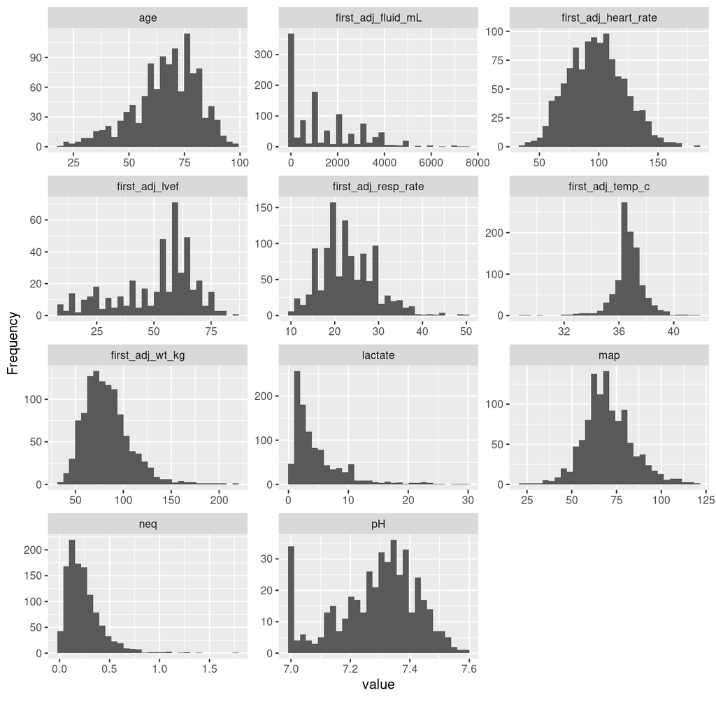

```r
plot_histogram(fl_aug |>
                 select(age, first_adj_wt_kg, pH, first_adj_temp_c,
                        first_adj_heart_rate, first_adj_resp_rate, neq, map,
                        lactate, first_adj_fluid_mL, first_adj_lvef
                        ),
               ncol = 3
               )
```

There appears to be substantial right skew for `first_adj_fluid_mL`, `lactate`, and `neq`, therefore will log-transform these variables for the propensity score model.

Develop the propensity score model workflow and fit the model. As part of the `recipe()`, use bagged tree imputation for missing predictors, dummy code nominal predictors, and log-transform right-skewed variables. The model would not converge with a log-transformation of `first_adj_fluid_mL`, therefore a Yeo-Johnson transformation was applied instead for this variable.

```r
ps_spec <-
  multinom_reg() |>
  set_engine("nnet") |>
  set_mode("classification")

ps_rec <-
  recipe(first_adj ~ age + sex + ssc_era_orig + cerebrovascular_disease +
           hypertension + heart_failure + valvular_disease +
           chronic_pulmonary_disease + pulmonary_circulation_disease +
           liver_disease + kidney_disease + malignancy + diabetes + obesity +
           alcohol_abuse + first_adj_wt_kg + first_adj_tx_unit +
           first_adj_abx + shock_dur_h + sofa2_no_cv + mv_before_adj + pH +
           first_adj_temp_c + first_adj_heart_rate + first_adj_resp_rate +
           neq + map + lactate + first_adj_fluid_mL + first_adj_steroid +
           first_adj_lvef + pH_missing + lvef_missing,
         data = fl_aug
         ) |>
  step_impute_bag(pH, first_adj_lvef, lactate, first_adj_temp_c, map,
                  first_adj_wt_kg, first_adj_heart_rate, first_adj_resp_rate
                  ) |>
  step_dummy(all_nominal_predictors()) |>
  step_log(lactate, neq) |>
  step_YeoJohnson(first_adj_fluid_mL)

ps_wf <-
  workflow() |>
  add_model(ps_spec) |>
  add_recipe(ps_rec)

ps_fit <-
  fit(ps_wf, fl_aug)
```

Next, generate predicted probabilities (propensity scores) using the model and bind the probabilities back to the dataset.

```r
ps_probs <-
  predict(ps_fit,
          new_data = fl_aug,
          type = "prob")

fl_aug_ps <- bind_cols(
  fl_aug |> select(first_adj, response, response_bin,
                   rec_first_adj, first_adj_concordance
                   ),
  ps_probs
  ) |>
  rename(ps_vasopressin = .pred_vasopressin,
         ps_epinephrine = .pred_epinephrine,
         ps_phenylephrine = .pred_phenylephrine)
```

Show the minimum and maximum propensity scores by first adjunct received.

```r
fl_aug_ps |>
  group_by(first_adj) |>
  summarize(
    median_vaso = median(ps_vasopressin),
    median_epi = median(ps_epinephrine),
    median_phenyl = median(ps_phenylephrine),
    min_vaso = min(ps_vasopressin),
    max_vaso = max(ps_vasopressin),
    min_epi = min(ps_epinephrine),
    max_epi = max(ps_epinephrine),
    min_phenyl = min(ps_epinephrine),
    max_phenyl = max(ps_phenylephrine)
    ) |>
  kable(digits = 3,
        caption = "Summary of Propensity Score by First Adjunctive Vasopressor"
        ) |>
  kable_paper(full_width = FALSE)
```

Summary of Propensity Score by First Adjunctive Vasopressor

| first_adj | median_vaso | median_epi | median_phenyl | min_vaso | max_vaso | min_epi | max_epi | min_phenyl | max_phenyl |
| --- | --- | --- | --- | --- | --- | --- | --- | --- | --- |
| vasopressin | 0.940 | 0.025 | 0.017 | 0.065 | 0.998 | 0.000 | 0.848 | 0.000 | 0.721 |
| epinephrine | 0.696 | 0.251 | 0.022 | 0.128 | 0.983 | 0.003 | 0.781 | 0.003 | 0.378 |
| phenylephrine | 0.793 | 0.027 | 0.109 | 0.132 | 0.989 | 0.000 | 0.451 | 0.000 | 0.863 |

Reassuringly, the median propensity score for each adjunctive vasopressor is highest in patients who received that therapy during their care. However, the maximum vasopressin propensity score in patients receiving vasopressin and the minimum epinephrine and phenylephrine propensity scores for all therapies are outside of the desired range (minimum >=0.01, maximum <=0.99). This is not surprising based on the distribution of first adjunctive vasopressor use. It might be concerning for a causal analysis, but because this propensity score is part of a sensitivity analysis it will not be fine-tuned to overcome these issues.

Show plots of overlap of the propensity score by the observed first adjunctive vasopressor (`first_adj`).

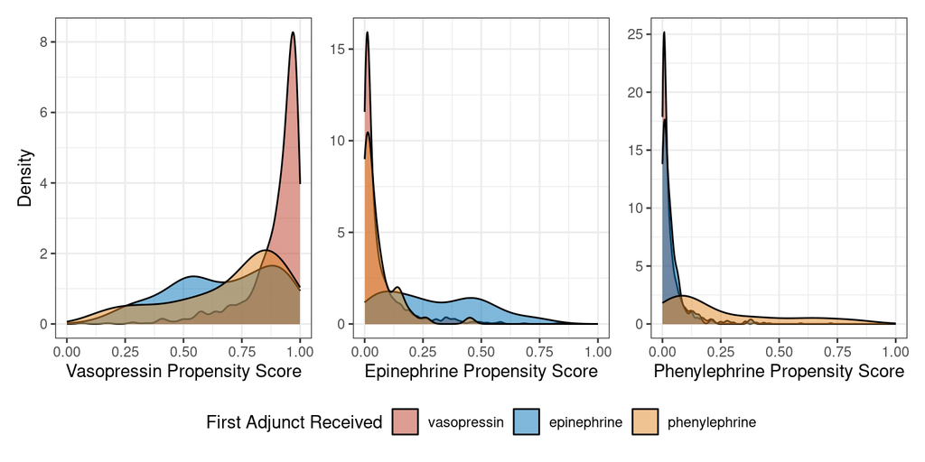

```r
p1 <-
  ggplot(fl_aug_ps, aes(x = ps_vasopressin, fill = first_adj)) +
  geom_density(alpha = 0.5) +
  scale_fill_nejm(name = "First Adjunct Received") +
  scale_x_continuous(limits = c(0,1), breaks = c(0, 0.25, 0.5, 0.75, 1)) +
  labs(x = "Vasopressin Propensity Score",
       y = "Density"
       )

p2 <-
  ggplot(fl_aug_ps, aes(x = ps_epinephrine, fill = first_adj)) +
  geom_density(alpha = 0.5) +
  scale_fill_nejm(name = "First Adjunct Received") +
  scale_x_continuous(limits = c(0,1), breaks = c(0, 0.25, 0.5, 0.75, 1)) +
  labs(x = "Epinephrine Propensity Score",
       y = "Density"
       )

p3 <-
  ggplot(fl_aug_ps, aes(x = ps_phenylephrine, fill = first_adj)) +
  geom_density(alpha = 0.5) +
  scale_fill_nejm(name = "First Adjunct Received") +
  scale_x_continuous(limits = c(0,1), breaks = c(0, 0.25, 0.5, 0.75, 1)) +
  labs(x = "Phenylephrine Propensity Score",
       y = "Density"
       )

(p1 | p2 | p3) +
  plot_layout(guides = "collect", axis_titles = "collect_y") &
  theme(legend.position = "bottom")
```

```r
ggsave(
  "ps_overlap_by_adj.tiff",
  device = ragg::agg_tiff,
  width = 8.5,
  height = 4,
  units = "in",
  dpi = 600,
  compression = "lzw"
)

rm(p1, p2, p3)
```

There is reasonable overlap in the propensity score by first adjunct received, therefore there are no major concerns for violation of the positivity assumption for a propensity score model.

Next, determine the propensity score for the observed first adjunctive vasopressor (`ps_observed`). This is a multinomial extension of the approach used in [Dalton 2016](https://journals.sagepub.com/doi/10.1177/0272989X15578835). More specifically, the propensity score was defined as the estimated probability of receiving the adjunctive vasopressor that was actually administered, obtained from a multinomial logistic regression model of treatment assignment.

```r
fl_aug_ps <- fl_aug_ps |>
  mutate(
    ps_observed = case_when(
      first_adj == "vasopressin" ~ ps_vasopressin,
      first_adj == "epinephrine" ~ ps_epinephrine,
      first_adj == "phenylephrine" ~ ps_phenylephrine
      )
    )
```

Then, show the distribution of `ps_observed` by observed adjunct.

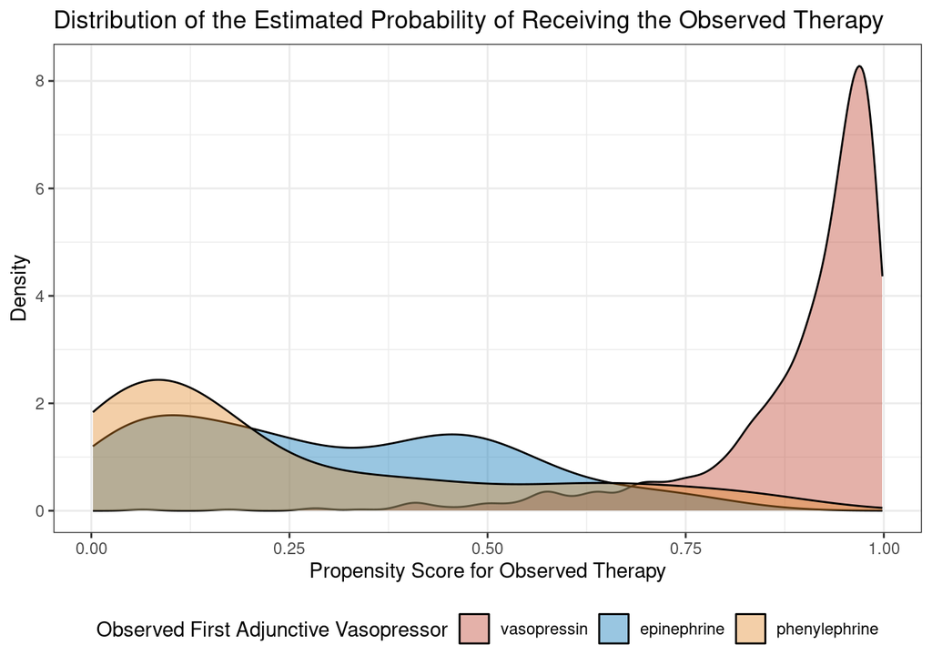

```r
ggplot(fl_aug_ps, aes(ps_observed, fill = first_adj)) +
  geom_density(alpha = 0.4) +
  scale_fill_nejm() +
  guides(fill = guide_legend(title = "Observed First Adjunctive Vasopressor")) +
  labs(title =  "Distribution of the Estimated Probability of Receiving the Observed Therapy",
       x = "Propensity Score for Observed Therapy",
       y = "Density"
       ) +
  theme(legend.position = "bottom")
```

```r
ggsave(
  "ps_for_observed_adj.tiff",
  device = ragg::agg_tiff,
  width = 7.5,
  height = 4,
  units = "in",
  dpi = 600,
  compression = "lzw"
)
```

This figure shows the distribution of the estimated probability of receiving the treatment that was actually administered (propensity score for the observed therapy), stratified by observed treatment group. As expected, patients treated with vasopressin generally had higher probabilities of receiving vasopressin than patients treated with epinephrine or phenylephrine (given the frequency of observed therapies substantially weighted towards vasopressin [distribution of 976/95/57 for vasopressin/epinephrine/phenylephrine]). The distributions for epinephrine and phenylephrine are shifted leftward compared to vasopressin, demonstrating lower model likelihood for receipt of these therapies.

Notably, this plot is not an overlap plot similar to those used to assess the positivity assumption (area of common support) in a traditional binary treatment propensity score approach. For the multinomial model, the propensity score for the observed therapy (`ps_observed`) is defined differently for each treatment group (e.g., for a patient receiving vasopressin, `ps_observed` is defined as P(vasopressin | X), whereas for a patient receiving epinephrine, `ps_observed` is defined as P(epinephrine | X)).

Next, fit a model to assess the association of `response` with the interaction of decision model concordance and the propensity score for the observed therapy (using restricted cubic spline with four knots).

```r
dd <- datadist(fl_aug_ps)
options(datadist = "dd")

fit_or <- lrm(response_bin ~
                first_adj_concordance * rcs(ps_observed, 4),
              data = fl_aug_ps, x = TRUE, y = TRUE
              )
```

To produce a plot similar to Figure 5 in [Dalton 2016](https://journals.sagepub.com/doi/10.1177/0272989X15578835), create a grid of propensity scores across the range of `ps_observed`.

```r
grid <- seq(
  min(fl_aug_ps$ps_observed),
  max(fl_aug_ps$ps_observed),
  length.out = 1000
  )
```

Then, use the `contrast()` function from `{rms}` to estimate the odds ratio for concordant vs. discordant therapy over the grid of propensity score values, and build a plotting tibble based on the output.

```r
or_curve <-
  rms::contrast(fit_or,
                list(first_adj_concordance = "concordant", ps_observed = grid),
                list(first_adj_concordance = "discordant", ps_observed = grid)
                )

or_plot <- tibble(
  ps_observed = or_curve$ps_observed,
  OR    = exp(or_curve$Contrast),
  lower = exp(or_curve$Lower),
  upper = exp(or_curve$Upper)
  )

rm(or_curve)
```

Lastly, create a panel plot similar to Figure 5 in [Dalton 2016](https://journals.sagepub.com/doi/10.1177/0272989X15578835).

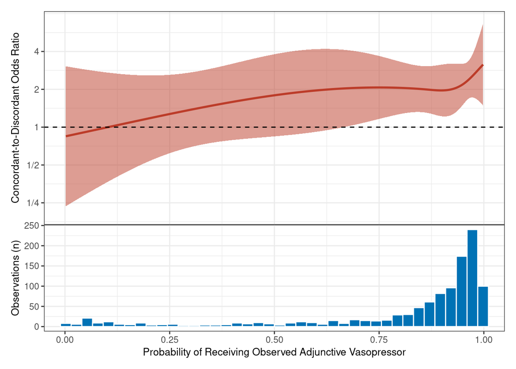

```r
p_or <-
  ggplot(or_plot, aes(x = ps_observed, y = OR)) +
  geom_ribbon(aes(ymin = lower, ymax = upper),
              fill = "#BC3C29FF", alpha = 0.5
              ) +
  geom_line(linewidth = 1, color = "#BC3C29FF") +
  geom_hline(yintercept = 1, linetype = 2) +
  scale_y_log10(
    limits = c(0.2, 7),
    breaks = c(0.25, 0.5, 1, 2, 4),
    label = c("1/4", "1/2", "1", "2", "4")
    ) +
  coord_cartesian(xlim = c(0, 1)) +
  labs(
    x = NULL,
    y = "Concordant-to-Discordant Odds Ratio"
    ) +
  theme_bw() +
  theme(
    axis.title.x = element_blank(),
    axis.text.x = element_blank(),
    axis.title.y = element_text(size = 10),
    axis.ticks.x = element_blank(),
    panel.border = element_rect(fill = NA),
    axis.line.x = element_blank(),
    plot.margin = margin(5.5, 5.5, 0, 5.5),
    plot.subtitle = element_text(size = 10)
    )

p_hist <-
  ggplot(fl_aug_ps, aes(x = ps_observed)) +
  geom_histogram(bins = 40, fill = "#0072B5FF", color = "white") +
  coord_cartesian(xlim = c(0, 1)) +
  labs(
    x = "Probability of Receiving Observed Adjunctive Vasopressor",
    y = "Observations (n)"
    ) +
  theme_bw() +
  theme(plot.margin = margin(0, 5.5, 5.5, 5.5),
        axis.title.x = element_text(size = 10),
        axis.title.y = element_text(size = 10)
        )

p_or / p_hist +
  plot_layout(heights = c(2, 1))
```

```r
ggsave(
  "concord_sens_ps_panel.tiff",
  device = ragg::agg_tiff,
  width = 6.5,
  height = 5,
  units = "in",
  dpi = 600,
  compression = "lzw"
)
```

This plot shows the estimated concordant-to-discordant odds ratio for response as a function of the propensity for receiving the observed therapy. The solid line represents the estimated odds ratio derived from a logistic regression model with restricted cubic splines for the propensity score and an interaction between the propensity score and concordance status. The shaded region represents the 95% confidence interval. The lower histogram shows the distribution of propensity scores for the observed therapy (adjunctive vasopressor received) in the study cohort.

Find the minimum propensity score value where the lower bound of the 95% confidence interval exceeds 1. Then, calculate the percentage of observations with this propensity score value or greater.

```r
or_plot |>
  filter(lower > 1) |>
  pull(ps_observed) |>
  min(na.rm = TRUE)
```

```
[1] 0.6651295
```

```r
round_half_up((sum(fl_aug_ps$ps_observed >0.662)/nrow(fl_aug_ps))*100,1)
```

```
[1] 82.3
```

### 14.5.7 Summary Figure

Create a summary table and figure to show the response percentage for concordant and discordant adjunctive vasopressor use and the discordance analysis odds ratio (with 95% CI) in the primary analysis and sensitivity analyses.

```r
t1 <- fl_aug |>
  tabyl(first_adj_concordance) |>
  adorn_pct_formatting() |>
  mutate(Analysis = "Primary", .before = percent) |>
  filter(first_adj_concordance == "concordant") |>
  select(Analysis, `Concordance` = percent)

t1_resp <- fl_aug |>
  mutate(first_adj_concordance =
           fct_relevel(first_adj_concordance, "concordant")
         ) |>
  tabyl(response, first_adj_concordance) |>
  adorn_percentages(denominator = "col") |>
  adorn_pct_formatting() |>
  filter(response == "Response") |>
  select("Response if Concordant" = concordant, "Response if Discordant" = discordant)

t1_or <- tidy(discord_analysis, exponentiate = TRUE, conf.int = TRUE) |>
  filter(term != "(Intercept)") |>
  select("OR" = estimate, "95% CI, Lower" = conf.low,
         "95% CI, Upper" = conf.high
         )

prim <- cbind(t1, t1_resp, t1_or)

sub1_conc <- fl_aug |>
  group_by(rec_first_adj) |>
  summarize(
    `Concordance` =
      mean(first_adj_concordance == "concordant")*100,
    .groups = "drop"
  ) |>
  mutate(rec_first_adj = case_when(
    rec_first_adj == "vasopressin" ~ "      Vasopressin",
    rec_first_adj == "epinephrine" ~ "      Epinephrine",
    rec_first_adj == "phenylephrine" ~ "      Phenylephrine"
    ),
    `Concordance` = sprintf("%.1f%%", round_half_up(Concordance, 1))
    ) |>
  select(Analysis = rec_first_adj, `Concordance`)

sub1_resp <- summary(emm$emmeans) |>
  as.data.frame() |>
  mutate(
    response = sprintf("%.1f%%", 100 * prob)
    ) |>
  pivot_wider(id_cols = rec_first_adj,
              names_from = first_adj_conc_relevl,
              values_from = response
              ) |>
  select(`Response if Concordant` = concordant, `Response if Discordant`= discordant)

sub1_or <- summary(emm$contrasts, infer = c(TRUE, TRUE)) |>
  as.data.frame() |>
  select("OR" = odds.ratio, "95% CI, Lower" = asymp.LCL,
         "95% CI, Upper" = asymp.UCL
         )

sub1 <- cbind(sub1_conc, sub1_resp, sub1_or) |>
  add_row(Analysis = "Subgroup", .before = 1) |>
  add_row(Analysis = paste0("   Recommended Adjunct", .after = 1))

t2 <- fl_aug |>
  tabyl(first_adj_concordance_sens) |>
  adorn_pct_formatting() |>
  mutate(Analysis = "      Difference <=0.05 as Equivalent", .before = percent) |>
  filter(first_adj_concordance_sens == "concordant") |>
  select(Analysis, "Concordance" = percent)

t2_resp <- fl_aug |>
  mutate(first_adj_concordance_sens =
           fct_relevel(first_adj_concordance_sens, "concordant")
         ) |>
  tabyl(response, first_adj_concordance_sens) |>
  adorn_percentages(denominator = "col") |>
  adorn_pct_formatting() |>
  filter(response == "Response") |>
  select("Response if Concordant" = concordant, "Response if Discordant" = discordant)

t2_or <- tidy(discord_analysis_sens1, exponentiate = TRUE, conf.int = TRUE) |>
  filter(term != "(Intercept)") |>
  select("OR" = estimate, "95% CI, Lower" = conf.low,
         "95% CI, Upper" = conf.high
         )

sens1 <- cbind(t2, t2_resp, t2_or) |>
  add_row(Analysis = "   Practical Equivalence of Probabilities",
          .before = 1
          )

t2b <- fl_aug |>
  tabyl(first_adj_concordance_sens2) |>
  adorn_pct_formatting() |>
  mutate(Analysis = "      Difference <=0.1 as Equivalent", .before = percent) |>
  filter(first_adj_concordance_sens2 == "concordant") |>
  select(Analysis, "Concordance" = percent)

t2b_resp <- fl_aug |>
  mutate(first_adj_concordance_sens2 =
           fct_relevel(first_adj_concordance_sens2, "concordant")
         ) |>
  tabyl(response, first_adj_concordance_sens2) |>
  adorn_percentages(denominator = "col") |>
  adorn_pct_formatting() |>
  filter(response == "Response") |>
  select("Response if Concordant" = concordant, "Response if Discordant" = discordant)

t2b_or <- tidy(discord_analysis_sens1b, exponentiate = TRUE, conf.int = TRUE) |>
  filter(term != "(Intercept)") |>
  select("OR" = estimate, "95% CI, Lower" = conf.low,
         "95% CI, Upper" = conf.high
         )

sens1b <- cbind(t2b, t2b_resp, t2b_or)

t3 <- fl_aug |>
  group_by(margin_strata) |>
  summarize(
    `Concordance` =
      mean(first_adj_concordance == "concordant")*100,
    .groups = "drop"
  ) |>
  mutate(
    margin_strata = case_when(
      margin_strata == "<0.05"     ~ paste0("      <0.05"),
      margin_strata == "0.05-0.10" ~ paste0("      0.05 to <0.10"),
      margin_strata == "≥0.10"     ~ paste0("      >=0.10")
      ),
    `Concordance` = sprintf("%.1f%%", round_half_up(Concordance, 1))
         ) |>
  select(Analysis = margin_strata, `Concordance`)

t3_resp <- fl_aug |>
  group_by(margin_strata, first_adj_concordance) |>
  summarize(
    response_pct =
      mean(response == "Response")*100,
    .groups = "drop"
  ) |>
  mutate(response_pct = sprintf("%.1f%%", round_half_up(response_pct, 1))) |>
  pivot_wider(id_cols = margin_strata,
              names_from = first_adj_concordance,
              values_from = response_pct
              ) |>
  select(`Response if Concordant` = concordant, `Response if Discordant`= discordant)

t3_or <- discord_analysis_sens2 |>
  select("OR" = `Response OR`, "95% CI, Lower" = Lower,
         "95% CI, Upper" = Upper
         )

sens2 <- cbind(t3, t3_resp, t3_or) |>
  add_row(Analysis = "   Probability Difference Strata",
          .before = 1
          )

t4 <- fl_aug |>
  group_by(dm_or_quartile) |>
  summarize(
    `Concordance` =
      mean(first_adj_concordance == "concordant")*100,
    .groups = "drop"
  ) |>
  mutate(
    dm_or_quartile = case_when(
      dm_or_quartile == 1 ~ paste0("      Q1 (OR range 1.00 to 1.15)"),
      dm_or_quartile == 2 ~ paste0("      Q2 (OR range >1.15 to 1.36)"),
      dm_or_quartile == 3 ~ paste0("      Q3 (OR range >1.36 to 1.72)"),
      dm_or_quartile == 4 ~ paste0("      Q4 (OR range >1.72 to 5.48)")
      ),
    `Concordance` = sprintf("%.1f%%", round_half_up(Concordance, 1))
         ) |>
  select(Analysis = dm_or_quartile, `Concordance`)

t4_resp <- fl_aug |>
  group_by(dm_or_quartile, first_adj_concordance) |>
  summarize(
    response_pct =
      mean(response == "Response")*100,
    .groups = "drop"
  ) |>
  mutate(response_pct = sprintf("%.1f%%", round_half_up(response_pct, 1))) |>
  pivot_wider(id_cols = dm_or_quartile,
              names_from = first_adj_concordance,
              values_from = response_pct
              ) |>
  select(`Response if Concordant` = concordant, `Response if Discordant`= discordant)

t4_or <- discord_analysis_sens3 |>
  select("OR" = `Response OR`, "95% CI, Lower" = Lower,
         "95% CI, Upper" = Upper
         )

sens3 <- cbind(t4, t4_resp, t4_or) |>
  add_row(Analysis = "   Decision Model OR Quartiles",
          .before = 1
          )

t5 <- fl_aug_sens |>
  tabyl(first_adj_concordance_sens) |>
  adorn_pct_formatting() |>
  mutate(Analysis = "   Vasopressin and Epinephrine Only",
         .before = percent
         ) |>
  filter(first_adj_concordance_sens == "concordant") |>
  select(Analysis, "Concordance" = percent)

t5_resp <- fl_aug_sens |>
  mutate(first_adj_concordance_sens =
           fct_relevel(first_adj_concordance_sens, "concordant")
         ) |>
  tabyl(response, first_adj_concordance_sens) |>
  adorn_percentages(denominator = "col") |>
  adorn_pct_formatting() |>
  filter(response == "Response") |>
  select("Response if Concordant" = concordant, "Response if Discordant" = discordant)

t5_or <- tidy(discord_analysis_sens4, exponentiate = TRUE, conf.int = TRUE) |>
  filter(term != "(Intercept)") |>
  select("OR" = estimate, "95% CI, Lower" = conf.low,
         "95% CI, Upper" = conf.high
         )

sens4 <- cbind(t5, t5_resp, t5_or)

(sum_fig <- rbind(prim, sub1, sens2, sens3, sens1, sens1b, sens4) |>
  add_row(Analysis = "Sensitivity", .after = 15))
```

```
                                    Analysis Concordance
1                                    Primary       31.8%
2                                   Subgroup        <NA>
3                                Vasopressin       92.6%
4                                Epinephrine        8.0%
5                              Phenylephrine        7.1%
6                       Recommended Adjunct1        <NA>
7              Probability Difference Strata        <NA>
8                                      <0.05       26.8%
9                              0.05 to <0.10       34.3%
10                                    >=0.10       36.0%
11               Decision Model OR Quartiles        <NA>
12                Q1 (OR range 1.00 to 1.15)       28.0%
13               Q2 (OR range >1.15 to 1.36)       31.2%
14               Q3 (OR range >1.36 to 1.72)       35.1%
```

[output cut: 48 more lines]

```r
rm(t1, t1_resp, t1_or, prim, sub1_conc, sub1_resp, sub1_or, sub1,
   t2, t2_resp, t2_or, sens1, t2b, t2b_resp, t2b_or, sens1b,
   t3, t3_resp, t3_or, sens2, t4, t4_resp, t4_or, sens3,
   t5, t5_resp, t5_or, sens4
   )
```

Lastly, plot the summary forest plot with `forester()` (exporting as a pdf [not shown]).

```r
forester(left_side_data = sum_fig[,1:4],
         estimate = sum_fig$OR,
         ci_low = sum_fig$`95% CI, Lower`,
         ci_high = sum_fig$`95% CI, Upper`,
         ci_sep = ", ",
         estimate_precision = 2,
         estimate_col_name = "Response OR (95% CI)",
         null_line_at = 1,
         ggplot_width = 20,
         display = FALSE,
         dpi = 600,
         xlim = c(0, 6),
         xbreaks = seq(0,6,1),
         font_family = "Helvetica",
         justify = c(0, 0.5, 0.5, 0.5, 0.5),
         file_path = "summary_discord_analysis.pdf",
         render_as = "pdf"
         )
```

```
`height` was translated to `width`.
```

# 15 Snapshot and Session Info

Call `snapshot()` to update the lockfile with metadata about the currently-used packages in the project library. Then produce a summary report of the session information.

```r
#snapshot()
summary(report(sessionInfo()))
```

```
The analysis was done using the R Statistical language (v4.6.0; R
Core Team, 2026) on Red Hat Enterprise Linux 8.10 (Ootpa), using the
packages forester (v0.3.0), ggalluvial (v0.12.6), tailor (v0.1.0),
infer (v1.1.0), DataExplorer (v0.9.0), pmsampsize (v1.1.3), janitor
(v2.2.1), rsample (v1.3.2), workflowsets (v1.1.1), riskRegression
(v2026.3.11), officer (v0.7.4), flextable (v0.9.11), fastshap
(v0.1.1), vip (v0.4.6), lubridate (v1.9.5), Hmisc (v5.2.5), rms
(v8.1.1), vroom (v1.7.1), gt (v1.3.0), ggpubr (v0.6.3), survminer
(v0.5.2), ggdist (v3.3.3), modeldata (v1.5.1), finetune (v1.3.0),
tune (v2.1.0), dials (v1.4.3), parsnip (v1.5.0), yardstick (v1.4.0),
tidymodels (v1.5.0), recipes (v1.3.2), emmeans (v2.0.3), report
(v0.6.3), shapviz (v0.10.3), tibble (v3.3.1), patchwork (v1.3.2),
pmcalibration (v0.2.0), broom (v1.0.12), GGally (v2.4.0), tidytext
(v0.4.3), dcurves (v0.5.1), gtsummary (v2.5.0), ggrepel (v0.9.8),
survival (v3.8.6), naniar (v1.1.0), renv (v1.2.2), ggh4x (v0.3.1),
simputation (v0.2.9), ivs (v0.2.0), workflows (v1.3.0), nnet
(v7.3.20), splines2 (v0.5.4), ggplot2 (v4.0.3), conflicted (v1.2.0),
forcats (v1.0.1), stringr (v1.6.0), tidyverse (v2.0.0), dplyr
(v1.2.1), purrr (v1.2.2), readr (v2.2.0), scales (v1.4.0), tidyr
(v1.3.2), ggsci (v5.0.0) and kableExtra (v1.4.0).
```

# 16 References

```r
cite_packages()
```

```
  - Boyes R (2021). _Forester: An R package for creating publication-ready forest plots._. R package version 0.3.0, <https://github.com/rdboyes/forester>.
  - Brunson JC, Read QD (2026). "ggalluvial: Alluvial Plots in 'ggplot2'." R package version 0.12.6, <http://corybrunson.github.io/ggalluvial/>. Brunson JC (2020). "ggalluvial: Layered Grammar for Alluvial Plots." _Journal of Open Source Software_, *5*(49), 2017. doi:10.21105/joss.02017 <https://doi…
  - Couch S, Frick H, HvitFeldt E, Kuhn M (2025). _tailor: Iterative Steps for Postprocessing Model Predictions_. R package version 0.1.0, <https://github.com/tidymodels/tailor>.
  - Couch SP, Bray AP, Ismay C, Chasnovski E, Baumer BS, Çetinkaya-Rundel M (2021). "infer: An R package for tidyverse-friendly statistical inference." _Journal of Open Source Software_, *6*(65), 3661. doi:10.21105/joss.03661 <https://doi.org/10.21105/joss.03661>.
  - Cui B (2026). _DataExplorer: Automate Data Exploration and Treatment_. R package version 0.9.0, <http://boxuancui.github.io/DataExplorer/>.
  - Ensor J (2023). _pmsampsize: Sample Size for Development of a Prediction Model_. R package version 1.1.3.
  - Firke S (2024). _janitor: Simple Tools for Examining and Cleaning Dirty Data_. R package version 2.2.1, <https://github.com/sfirke/janitor>.
  - Frick H, Chow F, Kuhn M, Mahoney M, Silge J, Wickham H (2026). _rsample: General Resampling Infrastructure_. R package version 1.3.2, <https://rsample.tidymodels.org>.
  - Frick H, Kuhn M, Couch S (2025). _workflowsets: Create a Collection of 'tidymodels' Workflows_. R package version 1.1.1, <https://github.com/tidymodels/workflowsets>.
  - Gerds T, Ohlendorff J, Ozenne B (2026). _riskRegression: Risk Regression Models and Prediction Scores for Survival Analysis with Competing Risks_. R package version 2026.03.11, <https://github.com/tagteam/riskRegression>. Gerds T, Kattan M (2021). _Medical Risk Prediction Models: With Ties to Ma…
  - Gohel D, Moog S, Heckmann M (2026). _officer: Manipulation of Microsoft Word and PowerPoint Documents_. R package version 0.7.4, <https://ardata-fr.github.io/officeverse/>.
  - Gohel D, Skintzos P (2026). _flextable: Functions for Tabular Reporting_. R package version 0.9.11, <https://ardata-fr.github.io/flextable-book/>.
  - Greenwell B (2024). _fastshap: Fast Approximate Shapley Values_. R package version 0.1.1, <https://github.com/bgreenwell/fastshap>.
  - Greenwell BM, Boehmke BC (2020). "Variable Importance Plots-An Introduction to the vip Package." _The R Journal_, *12*(1), 343-366. <https://doi.org/10.32614/RJ-2020-013>.
  - Grolemund G, Wickham H (2011). "Dates and Times Made Easy with lubridate." _Journal of Statistical Software_, *40*(3), 1-25. <https://www.jstatsoft.org/v40/i03/>.
  - Harrell Jr F (2026). _Hmisc: Harrell Miscellaneous_. R package version 5.2-5, <https://hbiostat.org/R/Hmisc/>.
  - Harrell Jr F (2026). _rms: Regression Modeling Strategies_. R package version 8.1-1, <https://hbiostat.org/R/rms/>.
  - Hester J, Wickham H, Bryan J (2026). _vroom: Read and Write Rectangular Text Data Quickly_. R package version 1.7.1, <https://vroom.tidyverse.org>.
  - Iannone R, Cheng J, Schloerke B, Haughton S, Hughes E, Lauer A, François R, Seo J, Brevoort K, Roy O (2026). _gt: Easily Create Presentation-Ready Display Tables_. R package version 1.3.0, <https://gt.rstudio.com>.
  - Kassambara A (2026). _ggpubr: 'ggplot2' Based Publication Ready Plots_. R package version 0.6.3, <https://rpkgs.datanovia.com/ggpubr/>.
  - Kassambara A, Kosinski M, Biecek P (2026). _survminer: Drawing Survival Curves using 'ggplot2'_. R package version 0.5.2, <https://rpkgs.datanovia.com/survminer/index.html>.
  - Kay M (2024). "ggdist: Visualizations of Distributions and Uncertainty in the Grammar of Graphics." _IEEE Transactions on Visualization and Computer Graphics_, *30*(1), 414-424. doi:10.1109/TVCG.2023.3327195 <https://doi.org/10.1109/TVCG.2023.3327195>. Kay M (2025). _ggdist: Visualizations of Di…
  - Kuhn M (2025). _modeldata: Data Sets Useful for Modeling Examples_. R package version 1.5.1, <https://modeldata.tidymodels.org>.
  - Kuhn M (2026). _finetune: Additional Functions for Model Tuning_. R package version 1.3.0, <https://github.com/tidymodels/finetune>.
  - Kuhn M (2026). _tune: Tidy Tuning Tools_. R package version 2.1.0, <https://tune.tidymodels.org/>.
  - Kuhn M, Frick H (2026). _dials: Tools for Creating Tuning Parameter Values_. R package version 1.4.3, <https://dials.tidymodels.org>.
```

[output cut: 38 more lines]